# Pacific Flyway Data Book, 2026

**Migratory Game Bird Monitoring: Estimates of Abundance, Harvest, and Hunter Activity**

U.S. Fish and Wildlife Service  
Division of Migratory Bird Management  
Pacific Flyway Office  
http://www.pacificflyway.gov

01 September 2026

## Introduction

The following abundance, harvest, and hunter activity data have been assembled for use by State and U.S. Fish and Wildlife Service (USFWS) personnel in formulating recommendations for migratory bird hunting seasons in the Pacific Flyway. This collection of information can also serve as a desk-top reference for providing responses to inquiries from agency personnel, the media, and the public.

These data represent an extraordinary collaborative effort by many individuals from State, Federal, and other organizations. Thank you to all cooperators who have contributed toward this significant effort.

Some migratory bird surveys were not conducted in 2020 and 2021 because of the coronavirus pandemic. Consequently, some tables are missing data from these years as a result of no surveys being conducted.

Please note that abundance estimates are indices to abundance and not absolute population size. Abundance indices are either counts or estimates of a proportion of a population. The indices provide a measure of the relative abundance of a population over time.

**Data Tables**  
Each data table represents a data asset and is uniquely numbered for ease of reference. See the table of contents for a list of available data tables. The data table number is the appropriate reference number for any figure or table produced for a data asset, particularly for questions and the supporting data. The sequential numbers assigned to each table and figure in this document is of no significance for reference and may change with each document update.

**Document Navigation**  
There is an interactive table of contents to facilitate quickly locating data of interest. Data tables are organized into sections, each with a data type theme (e.g., abundance, harvest). Click on the section heading to expand the table of contents and see available data tables. Click on the primary heading or Introduction section in the table of contents to collapse all sections.

**Time Series Statistics**  
Time series statistics are provided in a table for the primary monitoring data included in graphs. Missing values in the time series statistics table means that the statistic is not estimable. In these cases, missing values were used rather than “N/A” for aesthetics in the statistics table.

**Figure and Data Access**  
Any figure in this document can be copied with a right mouse click over the figure of interest and then selecting “Copy image” or “Save image as.” Also, all data in this book may be downloaded for use from an online portal. Each table is referenced by the data table number it is associated with. Contact the Pacific Flyway Office for the URL of the online portal.

**Technical Details**  
This report provides original data and calculations in support of cooperative Pacific Flyway Council and USFWS harvest strategy assessments and to help inform harvest management decisions for all migratory game bird populations. See the Pacific Flyway Council’s website for migratory game bird population management plans (http://www.pacificflyway.gov/management.asp). Unless otherwise noted, harvest management prescriptions apply to the hunting season starting the year after the title year of this data book so long as the data in the respective data table are current through the title year.

Original data are provided by the USFWS Headquarters Migratory Bird Program, USFWS Alaska Region, USFWS Mountain-Prairie Region, and the States. In some cases, Pacific Flyway Council management indices are derived from these data to help inform harvest management decisions. We note the original source of data before each data table and note how any management indices are calculated. The original data are generally included in annual USFWS and State population status and harvest reports and survey memos. Any use of the data should be by permission of the agency or agencies that provided the data (see Suggested Citations, below).

*VCF and Fall Projection Estimates*  
A visibility correction factor (VCF; or fall projection adjustment factor) is applied to survey data for dusky Canada geese, cackling (minima) cackling geese, and Pacific white-fronted geese based on models fit to the data. Similarly, percent Ross’s geese in the California white goose survey is calculated based on a fitted model. Documentation of how these models were fit and estimates derived are in separate documents and available upon request of the USFWS Pacific Flyway Representative’s Office.

*Missing Data and Moving 3-year Averages*  
Missing data from all or part of a survey year results in no management indices being calculated for that year. The only exception is for the winter counts including snow geese (so long as there are counts in at least California and Skagit-Fraser River Delta areas), brant (so long as there are counts in North America and Mexico), and tundra swans (so long as there are counts in the U.S. Atlantic and Mississippi flyways and Ontario, Canada). The total winter count is interpreted as the minimum known population size with no variance.

Moving 3-year averages are calculated as the 3 most recent available abundance estimates, and is an ad hoc way of reducing annual observation variance in survey estimates.

**Suggested Citations**  
Any use or reference to the data provided in this report should be cited accordingly. Please contact the appropriate State or Federal representative for survey and citation information. State and Federal representatives contact information may be found on the Pacific Flyway Council’s website at http://www.pacificflyway.gov/contacts.asp.

Pacific Flyway Data Book:  
U.S. Fish and Wildlife Service. 2026. Pacific Flyway Data Book, 2026. U.S. Department of Interior, Fish and Wildlife Service, Division of Migratory Bird Management, Pacific Flyway Office, Washington D.C.

USFWS Alaska Region:  
Frost, C. J., D. E. Safine, J. B. Fischer, and E. E. Osnas. 2026. Alaska Goose, Swan, and Crane Population Indices. U.S. Fish and Wildlife Service, Migratory Bird Management, Alaska Region. https://doi.org/10.7944/khzq-7v11

## Abundance (Primary Data)

### Data Table 1: Brant, Pacific (fall)

Original data source: Brant Fall Photographic Survey at Izembek Lagoon, AK; USFWS Alaska Region. Data maintained by USFWS Alaska Region.

Provided in the table below are abundance (Estimate) and standard error (SE) of brant in fall. Also provided are the number of replicate surveys (Reps) and abundance moving 3-year average (M3yr) and standard error (M3yr.SE).

Table 1. Pacific brant abundance in fall, 2017-2025.

| Year | Estimate | SE | Reps | M3yr | M3yr.SE |
| --- | --- | --- | --- | --- | --- |
| 2017 | 377,029 | 55,773 | 3 | NA | NA |
| 2018 | 227,450 | 21,651 | 3 | NA | NA |
| 2019 | 272,468 | 40,659 | 2 | 292,316 | 41,763 |
| 2020 | NA | NA | NA | NA | NA |
| 2021 | NA | NA | NA | NA | NA |
| 2022 | 201,576 | 24,042 | 5 | 233,831 | 30,000 |
| 2023 | 245,093 | 40,249 | 3 | 239,712 | 35,829 |
| 2024 | 188,580 | 25,053 | 4 | 211,750 | 30,690 |
| 2025 | 196,159 | 30,252 | 6 | 209,944 | 32,470 |

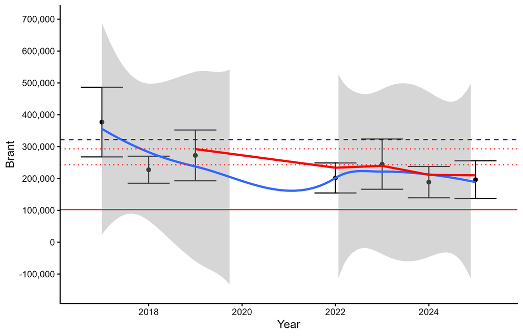

Figure 1: Pacific brant abundance in fall. Circles are annual estimates with 95% confidence intervals. The red line is a moving 3-year average and the blue line is a smoothed (Loess model) line with 95% confidence interval (shaded area) fit to the annual estimates. The blue dashed reference line is the Pacific Flyway Council’s population objective. The red dashed reference lines represent threshold values in the harvest strategy decision and the red reference line is the closure threshold.

Time series statistics

| Parameter | Estimate | SE | L95%CI | U95%CI |
| --- | --- | --- | --- | --- |
| 1-year index | 196,159 | 30,252 | 136,865 | 255,453 |
| 3-year index<sup>a</sup> | 209,944 | 32,470 | 146,304 | 273,584 |
| LTA | 252,033 |  |  |  |
| Objective | 322,000 |  |  |  |
| % change from LTA | -22 |  |  |  |
| % change from obj | -35 |  |  |  |
| Mgmt index (n years) | 3 |  |  |  |

<sup>a</sup> 2023, 2024, 2025

**Harvest Strategy**  
Management index: Total brant in fall.

Management thresholds:  
>293,000 Liberal  
>243,000 Moderate  
≥102,000 Restrictive  
Closed

If the population declines to a level which prescribes a closed season, a restrictive hunting season may not resume until the 3-year average population index exceeds 112,000 brant.

Management prescription: Restrictive.

Note that the management prescription applies to the 2026 hunting season.

Regulatory alternatives:  
Liberal  
AK: 107 days and 4-bird bag, Sep 1-Jan 26  
WA: 37 days and 2-bird bag, Saturday closest to Sep 24-Jan 31  
OR: 37 days and 2-bird bag, Saturday closest to Sep 24-Dec 15  
CA: 37 days and 2-bird bag, Saturday closest to Sep 24-Dec 15  
Moderate  
AK: 107 days and 2-bird bag, Sep 1-Jan 26  
WA: 27 days and 2-bird bag, Saturday closest to Sep 24-Jan 31  
OR: 27 days and 2-bird bag, Saturday closest to Sep 24-Dec 15  
CA: 27 days and 2-bird bag, Saturday closest to Sep 24-Dec 15  
Restrictive  
AK: 51 days and 2-bird bag, Sep 1-Jan 26  
WA: 16 days and 2-bird bag, Saturday closest to Sep 24-Jan 31  
OR: 16 days and 2-bird bag, Saturday closest to Sep 24-Dec 15  
CA: 16 days and 2-bird bag, Saturday closest to Sep 24-Dec 15  
Closed

### Data Table 2: Cackling Goose, Aleutian

Original data source: Pacific Flyway Cooperative Aleutian Cackling Goose Mark-resight Survey; California, Oregon, and USFWS Pacific Flyway Office. Data maintained by USFWS Pacific Flyway Office.

Table 2. Aleutian Cackling goose abundance in winter, 1975-2026.

| Year | Estimate | SE | M3yr | M3yr.SE | Method |
| --- | --- | --- | --- | --- | --- |
| 1975 | 790 | NA | NA | NA | Direct count |
| 1976 | 900 | NA | NA | NA | Direct count |
| 1977 | 1,280 | NA | 990 | NA | Direct count |
| 1978 | 1,500 | NA | 1,227 | NA | Direct count |
| 1979 | 1,590 | NA | 1,457 | NA | Direct count |
| 1980 | 1,740 | NA | 1,610 | NA | Direct count |
| 1981 | 2,000 | NA | 1,777 | NA | Direct count |
| 1982 | 2,700 | NA | 2,147 | NA | Direct count |
| 1983 | 3,500 | NA | 2,733 | NA | Direct count |
| 1984 | 3,800 | NA | 3,333 | NA | Direct count |
| 1985 | 4,200 | NA | 3,833 | NA | Direct count |
| 1986 | 4,300 | NA | 4,100 | NA | Direct count |
| 1987 | 5,000 | NA | 4,500 | NA | Direct count |
| 1988 | 5,400 | NA | 4,900 | NA | Direct count |
| 1989 | 5,800 | NA | 5,400 | NA | Direct count |
| 1990 | 6,300 | NA | 5,833 | NA | Direct count |
| 1991 | 7,000 | NA | 6,367 | NA | Direct count |
| 1992 | 7,680 | NA | 6,993 | NA | Direct count |
| 1993 | 11,680 | NA | 8,787 | NA | Direct count |
| 1994 | 15,700 | NA | 11,687 | NA | Direct count |
| 1995 | 19,150 | NA | 15,510 | NA | Direct count |
| 1996 | 15,451 | 558 | 16,767 | NA | Mark-resight |
| 1997 | 20,394 | 763 | 18,332 | NA | Mark-resight |
| 1998 | 32,453 | 1,071 | 22,766 | 825 | Mark-resight |
| 1999 | 35,551 | 3,122 | 29,466 | 1,956 | Mark-resight |
| 2000 | 34,278 | 1,347 | 34,094 | 2,058 | Mark-resight |
| 2001 | NA | NA | NA | NA | NA |
| 2002 | NA | NA | NA | NA | NA |
| 2003 | 72,857 | 2,711 | 47,562 | 2,511 | Mark-resight |
| 2004 | 110,733 | 4,299 | 72,623 | 3,036 | Mark-resight |
| 2005 | 87,157 | 4,558 | 90,249 | 3,942 | Mark-resight |
| 2006 | 100,266 | 4,532 | 99,385 | 4,465 | Mark-resight |
| 2007 | 107,639 | 7,586 | 98,354 | 5,741 | Mark-resight |
| 2008 | 112,622 | 6,782 | 106,842 | 6,431 | Mark-resight |
| 2009 | 84,493 | 11,913 | 101,585 | 9,045 | Mark-resight |
| 2010 | 106,889 | 8,469 | 101,335 | 9,303 | Mark-resight |
| 2011 | 101,639 | 7,007 | 97,673 | 9,358 | Mark-resight |
| 2012 | 132,735 | 10,071 | 113,754 | 8,607 | Mark-resight |
| 2013 | 162,472 | 14,690 | 132,282 | 11,050 | Mark-resight |
| 2014 | 150,457 | 13,085 | 148,555 | 12,760 | Mark-resight |
| 2015 | 209,592 | 18,274 | 174,174 | 15,502 | Mark-resight |
| 2016 | 154,391 | 13,141 | 171,480 | 15,032 | Mark-resight |
| 2017 | 164,050 | 17,993 | 176,011 | 16,637 | Mark-resight |
| 2018 | 169,674 | 14,566 | 162,705 | 15,369 | Mark-resight |
| 2019 | 193,097 | 25,628 | 175,607 | 19,939 | Mark-resight |
| 2020 | 122,047 | 12,053 | 161,606 | 18,387 | Mark-resight |
| 2021 | 173,067 | 16,020 | 162,737 | 18,786 | Mark-resight |
| 2022 | 233,376 | 28,414 | 176,163 | 20,077 | Mark-resight |
| 2023 | 189,713 | 33,423 | 198,719 | 26,964 | Mark-resight |
| 2024 | 166,471 | 23,549 | 196,520 | 28,746 | Mark-resight |
| 2025 | 195,729 | 32,910 | 183,971 | 30,303 | Mark-resight |
| 2026 | 104,410 | 17,736 | 155,537 | 25,509 | Mark-resight |

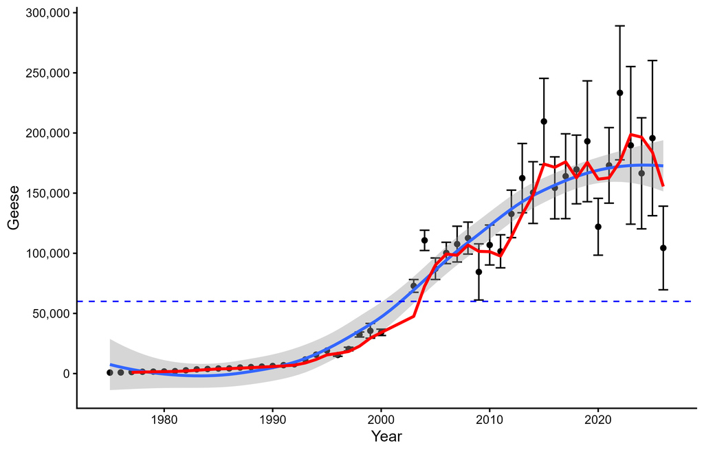

Figure 2: Aleutian cackling goose abundance in winter. Circles are annual estimates of abundance with 95% confidence intervals. The red line is a moving 3-year average and the blue line is a smoothed (Loess model) line with 95% confidence interval (shaded area) fit to the annual estimates. The blue dashed reference line is the Pacific Flyway Council’s minimum population objective.

Time series statistics

| Parameter | Estimate | SE | L95%CI | U95%CI |
| --- | --- | --- | --- | --- |
| 1-year index | 104,410 | 17,736 | 69,648 | 139,172 |
| 3-year index<sup>a</sup> | 155,537 | 25,509 | 105,538 | 205,535 |
| LTA | 72,476 |  |  |  |
| Objective | 60,000 |  |  |  |
| % change from LTA | 44 |  |  |  |
| % change from obj | 74 |  |  |  |
| Mgmt index (n years) | 1 |  |  |  |

<sup>a</sup> 2024, 2025, 2026

**Harvest Strategy**  
Management index: Total Aleutian cackling geese in winter.

Management thresholds: N/A.

Management prescription: N/A.

Regulatory alternatives:  
Regulations fixed until changed.

### Data Table 3: Cackling Goose, Cackling (minima)

Original data source: Yukon Kuskokwim Delta Coastal Zone Survey and USFWS Pacific Flyway Office coordinated mark-resight program; USFWS Alaska Region, Alaska, British Columbia, Washington, Oregon, and California. Data maintained by USFWS Alaska Region and USFWS Pacific Flyway Office.

Provided in the table below are abundance and standard error (SE) of cackling (minima) cackling geese from mark-resight methods (Markresight) in fall, Yukon Kuskokwim Delta Coastal Zone Survey in spring (Total), and projected fall (Fall) abundance from the spring estimate. Spring abundance is projected to fall abundance via a fixed correction factor (estimate = 3.4225, SE = 0.1616) for visibility bias. Also provided are the projected fall abundance moving 3-year average (M3yr) and standard error (M3yr.SE).

Table 3. Cackling (minima) cackling goose abundance in spring and fall, 1985-2026.

| Year | Markresight | Total | Total.SE | Fall | Fall.SE | M3yr | M3yr.SE |
| --- | --- | --- | --- | --- | --- | --- | --- |
| 1985 | NA | 17,923 | 1,272 | 61,341 | 5,230 | NA | NA |
| 1986 | NA | 15,892 | 987 | 54,389 | 4,244 | NA | NA |
| 1987 | NA | 17,251 | 1,129 | 59,041 | 4,766 | 58,257 | 4,764 |
| 1988 | NA | 23,310 | 1,328 | 79,777 | 5,906 | 64,402 | 5,020 |
| 1989 | 92,062 | 24,360 | 1,302 | 83,370 | 5,946 | 74,062 | 5,566 |
| 1990 | 94,237 | 30,491 | 1,808 | 104,355 | 7,913 | 89,167 | 6,654 |
| 1991 | 148,628 | 28,488 | 1,628 | 97,500 | 7,230 | 95,075 | 7,077 |
| 1992 | 149,542 | 43,054 | 2,152 | 147,351 | 10,132 | 116,402 | 8,516 |
| 1993 | 184,844 | 44,144 | 1,960 | 151,080 | 9,794 | 131,977 | 9,144 |
| 1994 | 198,558 | 61,794 | 2,383 | 211,488 | 12,891 | 169,973 | 11,027 |
| 1995 | 202,969 | 67,115 | 2,838 | 229,698 | 14,559 | 197,422 | 12,571 |
| 1996 | 193,531 | 71,906 | 3,606 | 246,094 | 16,953 | 229,093 | 14,895 |
| 1997 | 256,715 | 83,797 | 3,257 | 286,793 | 17,538 | 254,195 | 16,401 |
| 1998 | 215,644 | 60,633 | 2,954 | 207,515 | 14,080 | 246,801 | 16,261 |
| 1999 | 306,065 | 67,081 | 3,216 | 229,582 | 15,449 | 241,297 | 15,753 |
| 2000 | 273,108 | 70,341 | 2,997 | 240,739 | 15,310 | 225,945 | 14,959 |
| 2001 | 206,249 | 73,931 | 3,484 | 253,026 | 16,882 | 241,115 | 15,896 |
| 2002 | 177,794 | 47,306 | 2,024 | 161,904 | 10,317 | 218,556 | 14,443 |
| 2003 | 251,594 | 68,492 | 3,206 | 234,412 | 15,588 | 216,447 | 14,542 |
| 2004 | NA | 50,578 | 2,378 | 173,103 | 11,535 | 189,806 | 12,682 |
| 2005 | NA | 63,358 | 2,882 | 216,839 | 14,219 | 208,118 | 13,883 |
| 2006 | NA | 69,338 | 2,970 | 237,305 | 15,129 | 209,082 | 13,713 |
| 2007 | NA | 73,984 | 3,014 | 253,206 | 15,790 | 235,783 | 15,059 |
| 2008 | NA | 83,645 | 3,700 | 286,271 | 18,522 | 258,928 | 16,546 |
| 2009 | NA | 66,414 | 2,511 | 227,301 | 13,748 | 255,593 | 16,139 |
| 2010 | NA | 81,013 | 4,566 | 277,264 | 20,391 | 263,612 | 17,775 |
| 2011 | 242,467 | 52,965 | 1,920 | 181,272 | 10,789 | 228,612 | 15,505 |
| 2012 | 272,493 | 59,534 | 2,824 | 203,751 | 13,638 | 220,762 | 15,473 |
| 2013 | 259,323 | 91,708 | 5,056 | 313,867 | 22,788 | 232,963 | 16,550 |
| 2014 | NA | 81,963 | 4,364 | 280,515 | 19,967 | 266,045 | 19,183 |
| 2015 | NA | 104,290 | 5,507 | 356,928 | 25,288 | 317,104 | 22,785 |
| 2016 | NA | 94,028 | 3,656 | 321,805 | 19,682 | 319,750 | 21,799 |
| 2017 | NA | 82,113 | 3,296 | 281,029 | 17,415 | 319,921 | 21,057 |
| 2018 | NA | 58,083 | 2,550 | 198,788 | 12,817 | 267,207 | 16,882 |
| 2019 | NA | 58,606 | 2,644 | 200,576 | 13,099 | 226,798 | 14,596 |
| 2020 | NA | NA | NA | NA | NA | NA | NA |
| 2021 | NA | 58,049 | 2,811 | 198,671 | 13,438 | 199,345 | 13,120 |
| 2022 | NA | 67,146 | 3,328 | 229,805 | 15,735 | 209,684 | 14,139 |
| 2023 | NA | 44,961 | 2,272 | 153,877 | 10,644 | 194,118 | 13,434 |
| 2024 | NA | 36,258 | 1,677 | 124,093 | 8,202 | 169,258 | 11,946 |
| 2025 | NA | 36,339 | 1,712 | 124,369 | 8,297 | 134,113 | 9,118 |
| 2026 | NA | 49,999 | 2,501 | 171,121 | 11,773 | 139,861 | 9,570 |

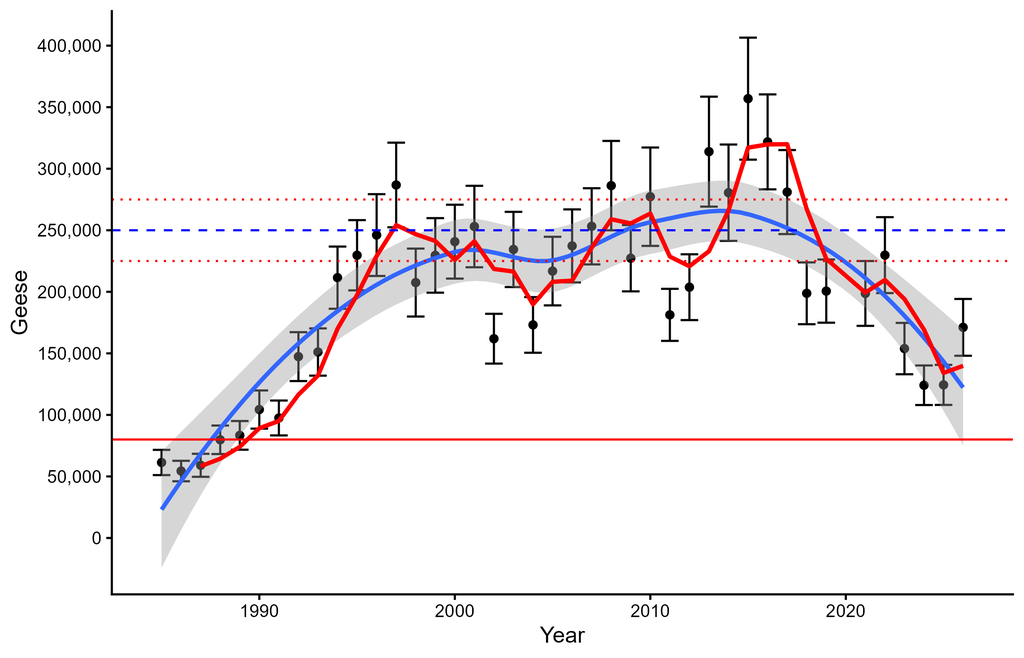

Figure 3: Cackling (minima) cackling goose abundance in fall. Circles are annual estimates of abundance with 95% confidence intervals. The red line is a moving 3-year average and the blue line is a smoothed (Loess model) line with 95% confidence interval (shaded area) fit to the annual estimates. The blue dashed reference line is the Pacific Flyway Council’s population objective. The red dashed reference lines represent threshold values in the harvest strategy decision and the red reference line is the closure threshold.

Time series statistics

| Parameter | Estimate | SE | L95%CI | U95%CI |
| --- | --- | --- | --- | --- |
| 1-year index | 171,121 | 11,773 | 148,046 | 194,197 |
| 3-year index<sup>a</sup> | 139,861 | 9,570 | 121,105 | 158,618 |
| LTA | 199,502 |  |  |  |
| Objective | 250,000 |  |  |  |
| % change from LTA | -14 |  |  |  |
| % change from obj | -44 |  |  |  |
| Mgmt index (n years) | 3 |  |  |  |

<sup>a</sup> 2024, 2025, 2026

**Harvest Strategy**  
Management index: Minima cackling geese projected in fall.

Management thresholds:  
>275,000 Liberal  
≥225,000 Standard  
≥80,000 Restrictive  
Closed

Management prescription: Restrictive.

Regulatory alternatives:  
Regulations fixed until changed.

After a closure and when the population increases above a 3-year average index of 110,000, limited hunting may be considered.

### Data Table 4: Cackling Goose, Taverner’s

Original data source: Yukon Kuskokwim Delta Coastal Zone Survey, Waterfowl Breeding Population and Habitat Survey strata in Alaska (i.e., strata 9–11), and Arctic Coastal Plain Survey; USFWS Alaska Region. Data maintained by USFWS Alaska Region.

Provided in the table below are abundance and standard error (SE) of Taverner’s cackling geese in spring by survey and area including Yukon Kuskokwim Delta Coastal Zone Survey (YKDCZ), Waterfowl Breeding Population and Habitat Survey (WBPHS; strata 9–11), and Arctic Coastal Plain Survey (ACP). Also provided are the total (Total) abundance and total abundance moving 3-year average (M3yr) and standard error (M3yr.SE).

Table 4. Taverner's cackling goose abundance in spring, 1985-2026.

| Year | YKDCZ | YKDCZ.SE | WPBHS9 | WPBHS9.SE | WPBHS10 | WPBHS10.SE | WPBHS11 | WPBHS11.SE | ACP | ACP.SE | Total | Total.SE | M3yr | M3yr.SE |
| --- | --- | --- | --- | --- | --- | --- | --- | --- | --- | --- | --- | --- | --- | --- |
| 1985 | 3,798 | 1,789 | 16,035 | 2,822 | 7,700 | 5,698 | 15,047 | 4,825 | NA | NA | NA | NA | NA | NA |
| 1986 | 2,288 | 586 | 17,774 | 1,693 | 8,112 | 7,233 | 9,474 | 3,018 | NA | NA | NA | NA | NA | NA |
| 1987 | 4,514 | 957 | 22,218 | 7,319 | 5,225 | 2,543 | 4,570 | 1,412 | NA | NA | NA | NA | NA | NA |
| 1988 | 8,551 | 1,633 | 14,973 | 2,036 | 4,812 | 810 | 17,945 | 4,360 | NA | NA | NA | NA | NA | NA |
| 1989 | 8,567 | 1,387 | 23,280 | 2,927 | 3,850 | 2,058 | 11,146 | 2,059 | NA | NA | NA | NA | NA | NA |
| 1990 | 7,812 | 1,862 | 25,405 | 2,201 | 3,575 | 1,367 | 9,697 | 2,145 | NA | NA | NA | NA | NA | NA |
| 1991 | 7,070 | 1,203 | 26,951 | 4,544 | 5,912 | 1,784 | 30,762 | 22,758 | NA | NA | NA | NA | NA | NA |
| 1992 | 7,714 | 1,592 | 23,763 | 2,877 | 11,550 | 5,365 | 15,381 | 6,095 | NA | NA | NA | NA | NA | NA |
| 1993 | 8,461 | 2,096 | 19,126 | 3,378 | 5,362 | 2,333 | 9,920 | 1,400 | NA | NA | NA | NA | NA | NA |
| 1994 | 7,003 | 1,406 | 24,922 | 3,687 | 5,225 | 2,367 | 13,486 | 4,814 | NA | NA | NA | NA | NA | NA |
| 1995 | 6,488 | 1,713 | 19,996 | 2,697 | 3,300 | 2,664 | 8,805 | 5,081 | NA | NA | NA | NA | NA | NA |
| 1996 | 6,598 | 1,293 | 25,792 | 5,057 | 6,600 | 4,718 | 14,155 | 6,249 | NA | NA | NA | NA | NA | NA |
| 1997 | 6,351 | 1,052 | 20,092 | 2,270 | 6,050 | 1,881 | 15,827 | 5,227 | NA | NA | NA | NA | NA | NA |
| 1998 | 10,350 | 1,277 | 21,155 | 3,859 | 5,638 | 1,474 | 12,929 | 2,847 | NA | NA | NA | NA | NA | NA |
| 1999 | 12,920 | 2,204 | 17,678 | 2,925 | 3,988 | 2,524 | 13,709 | 4,336 | NA | NA | NA | NA | NA | NA |
| 2000 | 9,709 | 2,597 | 12,600 | 2,042 | 3,850 | 778 | 13,152 | 7,027 | NA | NA | NA | NA | NA | NA |
| 2001 | 7,706 | 1,529 | 14,669 | 1,980 | 4,125 | 2,447 | 20,954 | 13,369 | NA | NA | NA | NA | NA | NA |
| 2002 | 5,982 | 1,100 | 13,353 | 2,584 | 6,738 | 2,987 | 9,362 | 742 | NA | NA | NA | NA | NA | NA |
| 2003 | 9,075 | 1,869 | 17,114 | 2,974 | 6,600 | 1,420 | 10,811 | 3,017 | NA | NA | NA | NA | NA | NA |
| 2004 | 7,825 | 2,928 | 12,882 | 1,840 | 5,225 | 2,318 | 6,910 | 2,328 | NA | NA | NA | NA | NA | NA |
| 2005 | 7,248 | 2,272 | 14,199 | 1,994 | 3,162 | 1,354 | 10,477 | 4,372 | NA | NA | NA | NA | NA | NA |
| 2006 | 9,510 | 1,983 | 15,515 | 2,220 | 4,950 | 651 | 8,136 | 1,833 | NA | NA | NA | NA | NA | NA |
| 2007 | 5,848 | 1,691 | 10,155 | 1,700 | 5,225 | 493 | 7,356 | 2,472 | 27,175 | 5,263 | 55,760 | 6,309 | NA | NA |
| 2008 | 10,572 | 2,037 | 21,627 | 8,864 | 8,388 | 3,441 | 6,019 | 1,631 | 5,013 | 714 | 51,619 | 9,886 | NA | NA |
| 2009 | 7,697 | 1,698 | 9,967 | 1,783 | 4,950 | 2,178 | 6,465 | 1,099 | 19,847 | 2,989 | 48,926 | 4,577 | 52,102 | 7,268 |
| 2010 | 9,135 | 2,112 | 18,148 | 1,145 | 5,500 | 2,069 | 7,802 | 2,090 | 16,345 | 3,052 | 56,930 | 4,872 | 52,492 | 6,890 |
| 2011 | 5,911 | 1,210 | 11,942 | 1,738 | 2,750 | 986 | 5,573 | 1,090 | 9,699 | 1,679 | 35,875 | 3,076 | 47,244 | 4,249 |
| 2012 | 9,069 | 3,598 | 9,967 | 2,128 | 4,675 | 1,042 | 7,914 | 1,143 | 14,670 | 2,788 | 46,295 | 5,258 | 46,367 | 4,503 |
| 2013 | 9,345 | 2,517 | 5,360 | 1,738 | 3,025 | 369 | 5,684 | 1,683 | 3,714 | 660 | 27,128 | 3,572 | 36,433 | 4,077 |
| 2014 | 13,148 | 4,921 | 6,488 | 2,923 | 8,662 | 3,655 | 6,910 | 1,094 | 7,312 | 1,153 | 42,521 | 6,975 | 38,648 | 5,448 |
| 2015 | 19,964 | 5,704 | 6,137 | 1,854 | 2,727 | 289 | 4,681 | 2,801 | 8,393 | 1,138 | 41,903 | 6,723 | 37,184 | 5,961 |
| 2016 | 8,042 | 2,095 | 12,224 | 3,506 | 6,875 | 1,605 | 6,688 | 2,729 | 16,537 | 2,325 | 50,366 | 5,667 | 44,930 | 6,480 |
| 2017 | 9,302 | 3,715 | 7,242 | 1,332 | 11,412 | 4,717 | 3,009 | 636 | 15,476 | 3,527 | 46,442 | 7,118 | 46,237 | 6,532 |
| 2018 | 15,633 | 4,949 | 6,958 | 2,966 | 7,700 | 1,506 | 4,458 | 1,851 | 9,865 | 1,584 | 44,615 | 6,442 | 47,141 | 6,436 |
| 2019 | 11,231 | 3,331 | 9,497 | 3,294 | 5,775 | 1,077 | 3,009 | 854 | 13,214 | 1,564 | 42,726 | 5,127 | 44,594 | 6,283 |
| 2020 | NA | NA | NA | NA | NA | NA | NA | NA | NA | NA | NA | NA | NA | NA |
| 2021 | 21,782 | 8,676 | 5,642 | 1,236 | 5,133 | 2,567 | 3,790 | 1,379 | NA | NA | NA | NA | NA | NA |
| 2022 | 11,695 | 4,586 | 9,027 | 3,532 | 2,750 | 986 | 4,012 | 1,216 | 18,746 | 2,671 | 46,230 | 6,565 | 44,524 | 6,079 |
| 2023 | 8,191 | 1,937 | 2,633 | 1,250 | 4,950 | 1,678 | 4,681 | 3,021 | 9,240 | 1,181 | 29,695 | 4,318 | 39,551 | 5,417 |
| 2024 | 6,596 | 2,156 | 5,266 | 1,125 | 6,600 | 3,082 | 4,377 | 1,815 | 15,453 | 2,264 | 38,293 | 4,882 | 38,073 | 5,341 |
| 2025 | 5,756 | 1,781 | 7,146 | 3,919 | 3,300 | 952 | 2,229 | 759 | 15,184 | 2,303 | 33,616 | 5,031 | 33,868 | 4,754 |
| 2026 | 6,282 | 2,539 | 2,257 | 1,090 | 12,833 | 1,698 | 5,016 | 2,282 | 14,497 | 1,995 | 40,885 | 4,439 | 37,598 | 4,791 |

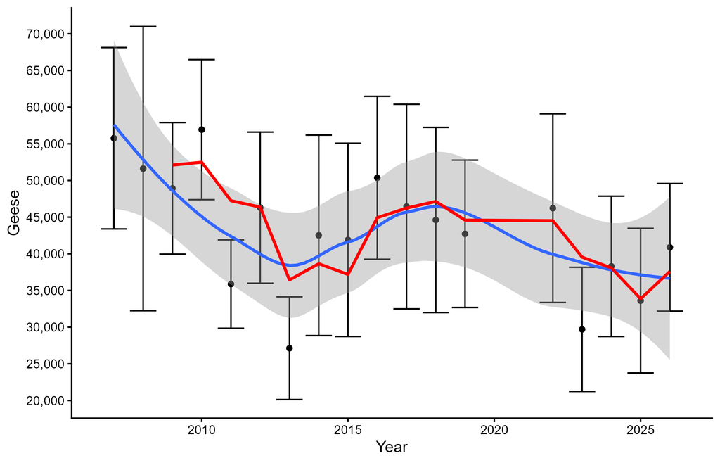

Figure 4: Taverner’s cackling goose abundance in spring. Circles are annual estimates of abundance with 95% confidence intervals. The red line is a moving 3-year average and the blue line is a smoothed (Loess model) line with 95% confidence interval (shaded area) fit to the annual estimates.

Time series statistics

| Parameter | Estimate | SE | L95%CI | U95%CI |
| --- | --- | --- | --- | --- |
| 1-year index | 40,885 | 4,439 | 32,184 | 49,585 |
| 3-year index<sup>a</sup> | 37,598 | 4,791 | 28,208 | 46,988 |
| LTA | 43,467 |  |  |  |
| Objective |  |  |  |  |
| % change from LTA | -6 |  |  |  |
| % change from obj |  |  |  |  |
| Mgmt index (n years) | 1 |  |  |  |

<sup>a</sup> 2024, 2025, 2026

**Harvest Strategy**  
Management index: Total Taverner’s cackling geese in spring.

Management thresholds: N/A.

Management prescription: N/A.

Regulatory alternatives:  
Regulations fixed until changed.

### Data Table 5: Canada Goose, Dusky

Original data source: Copper River Delta Survey and Middleton Island Survey; USFWS Alaska Region and Alaska Department of Fish and Game. Data maintained by USFWS Alaska Region, Alaska Department of Fish and Game, and USFWS Pacific Flyway Office.

Provided in the table below are abundance and standard error (SE) of dusky Canada geese in spring by social group including breeding, total, and flocked birds (Breeding, Total, Flocked). Also provided are the total birds on Middleton Island (Middleton). Breeding birds are expanded by a fixed correction factor (estimate = 3.3416, SE = 0.3244) for visibility bias, which are then added to the flocked and Middleton Island estimates to derive adjusted total (Adjtotal) dusky Canada geese. Additionally provided are the total abundance moving 3-year average (M3yr) and standard error (M3yr.SE).

Table 5. Dusky Canada goose abundance in spring, 1986-2026.

| Year | Breeding | Breeding.SE | Total | Total.SE | Flocked | Flocked.SE | Middleton | Middleton.SE | Adjtotal | Adjtotal.SE | M3yr | M3yr.SE |
| --- | --- | --- | --- | --- | --- | --- | --- | --- | --- | --- | --- | --- |
| 1986 | 4,735 | 676 | 5,416 | 646 | 680 | 573 | 80 | 0 | 16,584 | 2,799 | NA | NA |
| 1987 | 4,048 | 372 | 5,205 | 451 | 1,156 | 297 | 84 | 0 | 14,769 | 1,836 | NA | NA |
| 1988 | 4,281 | 217 | 4,935 | 257 | 654 | 108 | 90 | 0 | 15,051 | 1,572 | 15,468 | 2,135 |
| 1989 | 4,389 | 249 | 6,582 | 464 | 2,194 | 312 | 75 | 0 | 16,934 | 1,680 | 15,584 | 1,699 |
| 1990 | 4,220 | 367 | 5,209 | 526 | 989 | 291 | 93 | 0 | 15,183 | 1,865 | 15,723 | 1,710 |
| 1991 | 2,739 | 266 | 3,620 | 322 | 881 | 168 | 249 | 0 | 10,283 | 1,270 | 14,133 | 1,624 |
| 1992 | 4,156 | 219 | 6,378 | 634 | 2,223 | 564 | 473 | 0 | 16,582 | 1,637 | 14,016 | 1,609 |
| 1993 | 3,715 | 195 | 6,004 | 370 | 2,289 | 357 | 473 | 0 | 15,176 | 1,416 | 14,014 | 1,449 |
| 1994 | 3,852 | 188 | 5,454 | 331 | 1,602 | 239 | 473 | 0 | 14,946 | 1,420 | 15,568 | 1,494 |
| 1995 | 3,364 | 127 | 3,709 | 170 | 346 | 67 | 473 | 0 | 12,059 | 1,174 | 14,060 | 1,342 |
| 1996 | 2,910 | 104 | 3,514 | 157 | 604 | 85 | 1,497 | 0 | 11,824 | 1,010 | 12,943 | 1,213 |
| 1997 | 3,386 | 99 | 4,126 | 152 | 740 | 101 | 1,168 | 0 | 13,222 | 1,152 | 12,368 | 1,114 |
| 1998 | 3,691 | 166 | 5,066 | 284 | 1,375 | 199 | 1,168 | 0 | 14,877 | 1,336 | 13,308 | 1,174 |
| 1999 | 2,649 | 118 | 3,091 | 152 | 442 | 72 | 1,168 | 0 | 10,462 | 949 | 12,854 | 1,156 |
| 2000 | 2,523 | 107 | 3,016 | 126 | 493 | 67 | 1,309 | 0 | 10,233 | 896 | 11,857 | 1,078 |
| 2001 | 2,859 | 119 | 3,249 | 137 | 390 | 63 | 1,309 | 0 | 11,252 | 1,012 | 10,649 | 954 |
| 2002 | 3,152 | 126 | 4,058 | 204 | 906 | 137 | 1,416 | 0 | 12,856 | 1,115 | 11,447 | 1,012 |
| 2003 | 2,321 | 92 | 3,254 | 167 | 932 | 110 | 1,416 | 0 | 10,105 | 822 | 11,404 | 991 |
| 2004 | 2,822 | 128 | 3,243 | 158 | 420 | 69 | 1,499 | 0 | 11,350 | 1,013 | 11,437 | 991 |
| 2005 | 4,199 | 276 | 5,582 | 444 | 1,382 | 251 | 1,499 | 0 | 16,914 | 1,666 | 12,790 | 1,222 |
| 2006 | 2,771 | 135 | 3,198 | 155 | 427 | 87 | 1,453 | 0 | 11,139 | 1,010 | 13,134 | 1,268 |
| 2007 | 2,557 | 117 | 2,991 | 141 | 434 | 53 | 1,453 | 0 | 10,431 | 919 | 12,828 | 1,244 |
| 2008 | 2,333 | 104 | 2,617 | 115 | 285 | 43 | 1,317 | 0 | 9,396 | 834 | 10,322 | 924 |
| 2009 | 1,555 | 73 | 1,819 | 121 | 264 | 82 | 1,317 | 0 | 6,778 | 566 | 8,869 | 788 |
| 2010 | 2,316 | 95 | 2,703 | 134 | 387 | 67 | 1,249 | 0 | 9,374 | 818 | 8,516 | 750 |
| 2011 | 2,846 | 139 | 3,684 | 242 | 838 | 140 | 1,249 | 0 | 11,597 | 1,044 | 9,250 | 833 |
| 2012 | 3,338 | 150 | 3,913 | 203 | 575 | 81 | 1,193 | 0 | 12,922 | 1,197 | 11,298 | 1,031 |
| 2013 | NA | NA | NA | NA | NA | NA | NA | NA | NA | NA | NA | NA |
| 2014 | 3,522 | 197 | 4,551 | 258 | 1,029 | 147 | 1,780 | 0 | 14,579 | 1,329 | 13,032 | 1,195 |
| 2015 | 4,230 | 220 | 6,096 | 429 | 1,866 | 334 | 2,112 | 223 | 18,113 | 1,610 | 15,204 | 1,389 |
| 2016 | 3,516 | 236 | 4,087 | 282 | 570 | 111 | 3,536 | 449 | 15,856 | 1,464 | 16,182 | 1,472 |
| 2017 | 3,014 | 186 | 3,579 | 234 | 565 | 164 | 2,288 | 308 | 12,924 | 1,211 | 15,631 | 1,438 |
| 2018 | 2,299 | 118 | 3,234 | 225 | 935 | 178 | 3,414 | 510 | 12,030 | 1,003 | 13,603 | 1,240 |
| 2019 | 3,304 | 253 | 6,905 | 2,028 | 3,601 | 1,999 | 3,414 | 510 | 18,055 | 2,476 | 14,336 | 1,693 |
| 2020 | NA | NA | NA | NA | NA | NA | NA | NA | NA | NA | NA | NA |
| 2021 | 2,902 | 152 | 3,353 | 191 | 451 | 71 | 1,913 | 365 | 12,060 | 1,134 | 14,049 | 1,675 |
| 2022 | 2,870 | 149 | 3,712 | 234 | 842 | 140 | 1,913 | 365 | 12,346 | 1,127 | 14,154 | 1,701 |
| 2023 | 2,167 | 142 | 2,974 | 251 | 807 | 182 | 1,570 | 116 | 9,618 | 876 | 11,341 | 1,052 |
| 2024 | 1,764 | 101 | 2,448 | 195 | 684 | 126 | 1,570 | 116 | 8,150 | 688 | 10,038 | 915 |
| 2025 | 2,664 | 161 | 3,985 | 270 | 1,321 | 207 | 1,574 | 128 | 11,797 | 1,048 | 9,855 | 883 |
| 2026 | 2,225 | 124 | 3,600 | 415 | 1,376 | 381 | 1,574 | 128 | 10,384 | 925 | 10,110 | 900 |

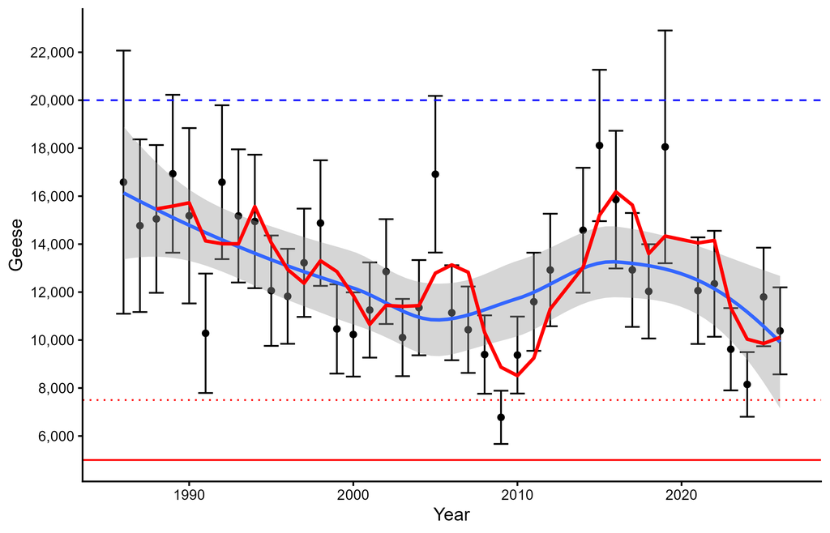

Figure 5: Dusky Canada goose abundance in spring. Circles are annual estimates of abundance with 95% confidence intervals. The red line is a moving 3-year average and the blue line is a smoothed (Loess model) line with 95% confidence interval (shaded area) fit to the annual estimates. The blue dashed reference line is the Pacific Flyway Council’s population objective. The red dashed reference line is a restriction threshold in the harvest strategy decision and the red reference line is the severe restriction threshold.

Time series statistics

| Parameter | Estimate | SE | L95%CI | U95%CI |
| --- | --- | --- | --- | --- |
| 1-year index | 10,384 | 925 | 8,570 | 12,197 |
| 3-year index<sup>a</sup> | 10,110 | 900 | 8,347 | 11,874 |
| LTA | 12,838 |  |  |  |
| Objective | 20,000 |  |  |  |
| % change from LTA | -19 |  |  |  |
| % change from obj | -49 |  |  |  |
| Mgmt index (n years) | 3 |  |  |  |

<sup>a</sup> 2024, 2025, 2026

**Harvest Strategy**  
Management index: Total dusky Canada geese in spring.

Management thresholds:  
≥7,500 Standard  
≥5,000 Restrictive  
Very Restrictive

Management prescription: Standard.

Note that the Very Restrictive alternative is prescribed if the dusky Canada goose index is less than 5,000 geese in any year.

Regulatory alternatives:  
Oregon and Washington Permit Zones  
Standard  
Closed season for dusky Canada geese  
Restrictive  
Additional restrictions, including the closure of all Canada goose hunting, will be considered  
Very Restrictive  
Oregon and Washington will implement regulations to ensure the hunting of Canada and cackling geese occurs only on or over agricultural fields or pastures with crops or forage that may be damaged by geese. Standard seasons for harvest of Canada and cackling geese other than dusky Canada geese in the permit zones may resume when the dusky Canada goose population (based on the 3-year average index) exceeds 10,000 geese

Alaska (GMU 6A-6D)  
Standard  
4 dusky Canada geese daily bag limit  
Restrictive  
2 dusky Canada geese daily bag limit  
Very Restrictive  
Closed season for dusky Canada geese, open to other Canada geese by permit only

### Data Table 6: Canada Goose, Lesser

Original data source: Waterfowl Breeding Population and Habitat Survey (WBPHS) strata in Alaska (i.e., strata 1–4, 12); USFWS Alaska Region. Data maintained by USFWS Alaska Region.

Provided in the table below are abundance and standard error (SE) of lesser Canada geese in spring by area (WBPHS strata 1-4, 12) and in total. Also provided are the total abundance moving 3-year average (M3yr) and standard error (M3yr.SE).

Table 6. Lesser Canada goose abundance in spring, 1964-2026.

| Year | WPBHS1 | WPBHS1.SE | WPBHS2 | WPBHS2.SE | WPBHS3 | WPBHS3.SE | WPBHS4 | WPBHS4.SE | WPBHS12 | WPBHS12.SE | Total | Total.SE | M3yr | M3yr.SE |
| --- | --- | --- | --- | --- | --- | --- | --- | --- | --- | --- | --- | --- | --- | --- |
| 1964 | 110 | 120 | 150 | 142 | 0 | 0 | 1,929 | 1,655 | 125 | 107 | 2,314 | 1,669 | NA | NA |
| 1965 | 1,100 | 682 | 0 | 0 | 352 | 364 | 1,234 | 840 | 0 | 0 | 2,687 | 1,142 | NA | NA |
| 1966 | 0 | 0 | 0 | 0 | 141 | 136 | 284 | 265 | 0 | 0 | 425 | 298 | 1,808 | 1,180 |
| 1967 | 3,740 | 3,038 | 450 | 426 | 2,159 | 1,135 | 7,020 | 3,168 | 109 | 103 | 13,478 | 4,555 | 5,530 | 2,716 |
| 1968 | 385 | 422 | 0 | 0 | 775 | 363 | 8,370 | 4,826 | 438 | 284 | 9,968 | 4,866 | 7,957 | 3,852 |
| 1969 | 3,410 | 3,735 | 0 | 0 | 705 | 345 | 3,645 | 1,593 | 0 | 0 | 7,760 | 4,076 | 10,402 | 4,510 |
| 1970 | 2,805 | 2,748 | 0 | 0 | 705 | 393 | 8,505 | 4,209 | 657 | 620 | 12,671 | 5,080 | 10,133 | 4,694 |
| 1971 | 220 | 241 | 0 | 0 | 2,466 | 1,003 | 5,400 | 3,166 | 109 | 103 | 8,195 | 3,331 | 9,542 | 4,224 |
| 1972 | 0 | 0 | 0 | 0 | 705 | 393 | 2,700 | 1,180 | 0 | 0 | 3,405 | 1,243 | 8,090 | 3,580 |
| 1973 | 220 | 216 | 0 | 0 | 1,832 | 500 | 4,050 | 1,097 | 274 | 258 | 6,375 | 1,252 | 5,992 | 2,176 |
| 1974 | 330 | 162 | 150 | 142 | 14,655 | 14,539 | 5,940 | 1,642 | 109 | 103 | 21,184 | 14,633 | 10,321 | 8,510 |
| 1975 | 0 | 0 | 0 | 0 | 986 | 543 | 4,590 | 995 | 1,368 | 1,291 | 6,944 | 1,718 | 11,501 | 8,537 |
| 1976 | 0 | 0 | 0 | 0 | 1,127 | 437 | 1,755 | 625 | 109 | 103 | 2,992 | 769 | 10,373 | 8,518 |
| 1977 | 770 | 488 | 150 | 142 | 1,057 | 394 | 1,890 | 815 | 821 | 775 | 4,688 | 1,295 | 4,875 | 1,319 |
| 1978 | 0 | 0 | 0 | 0 | 1,832 | 653 | 4,995 | 2,124 | 109 | 103 | 6,936 | 2,224 | 4,872 | 1,551 |
| 1979 | 110 | 108 | 0 | 0 | 1,620 | 678 | 4,590 | 1,693 | 219 | 82 | 6,539 | 1,829 | 6,054 | 1,823 |
| 1980 | 0 | 0 | 450 | 464 | 1,691 | 539 | 10,530 | 3,173 | 219 | 207 | 12,890 | 3,258 | 8,788 | 2,511 |
| 1981 | 330 | 235 | 375 | 255 | 2,677 | 1,001 | 13,770 | 3,564 | 1,259 | 1,017 | 18,411 | 3,855 | 12,613 | 3,099 |
| 1982 | 1,210 | 1,056 | 150 | 155 | 1,550 | 666 | 9,990 | 4,167 | 3,119 | 2,685 | 16,019 | 5,114 | 15,773 | 4,149 |
| 1983 | 220 | 216 | 0 | 0 | 1,550 | 883 | 1,620 | 548 | 0 | 0 | 3,390 | 1,062 | 12,607 | 3,748 |
| 1984 | 990 | 970 | 2,325 | 2,199 | 1,127 | 371 | 9,180 | 3,538 | 219 | 207 | 13,841 | 4,298 | 11,083 | 3,905 |
| 1985 | 385 | 377 | 0 | 0 | 705 | 432 | 7,830 | 3,152 | 657 | 620 | 9,576 | 3,263 | 8,936 | 3,175 |
| 1986 | 1,430 | 1,401 | 150 | 142 | 775 | 671 | 4,320 | 2,114 | 0 | 0 | 6,675 | 2,627 | 10,031 | 3,465 |
| 1987 | 220 | 216 | 150 | 142 | 705 | 253 | 2,970 | 1,070 | 547 | 516 | 4,592 | 1,242 | 6,948 | 2,523 |
| 1988 | 440 | 332 | 525 | 496 | 986 | 400 | 3,780 | 750 | 1,040 | 981 | 6,771 | 1,429 | 6,013 | 1,870 |
| 1989 | 715 | 701 | 0 | 0 | 423 | 221 | 5,940 | 2,012 | 0 | 0 | 7,078 | 2,142 | 6,147 | 1,651 |
| 1990 | 770 | 754 | 750 | 774 | 2,748 | 1,721 | 7,290 | 3,229 | 109 | 103 | 11,667 | 3,817 | 8,505 | 2,658 |
| 1991 | 495 | 485 | 2,175 | 1,726 | 1,409 | 568 | 0 | 0 | 219 | 125 | 4,298 | 1,885 | 7,681 | 2,751 |
| 1992 | 4,290 | 4,203 | 0 | 0 | 845 | 503 | 2,565 | 1,137 | 1,423 | 1,196 | 9,123 | 4,544 | 8,363 | 3,595 |
| 1993 | 495 | 485 | 150 | 155 | 282 | 200 | 4,860 | 1,379 | 109 | 103 | 5,896 | 1,487 | 6,439 | 2,967 |
| 1994 | 1,925 | 1,886 | 150 | 142 | 2,889 | 2,447 | 10,530 | 3,761 | 1,204 | 698 | 16,698 | 4,919 | 10,572 | 3,960 |
| 1995 | 715 | 592 | 675 | 541 | 705 | 345 | 7,020 | 2,669 | 438 | 342 | 9,552 | 2,829 | 10,715 | 3,387 |
| 1996 | 1,100 | 1,078 | 300 | 195 | 1,339 | 681 | 4,725 | 2,116 | 219 | 207 | 7,683 | 2,487 | 11,311 | 3,577 |
| 1997 | 715 | 575 | 300 | 195 | 564 | 266 | 2,970 | 783 | 438 | 251 | 4,986 | 1,056 | 7,407 | 2,258 |
| 1998 | 880 | 862 | 0 | 0 | 141 | 141 | 4,590 | 1,636 | 109 | 103 | 5,720 | 1,857 | 6,130 | 1,893 |
| 1999 | 110 | 108 | 2,175 | 1,919 | 141 | 145 | 2,295 | 953 | 930 | 380 | 5,651 | 2,183 | 5,453 | 1,764 |
| 2000 | 3,960 | 3,761 | 375 | 255 | 493 | 262 | 3,240 | 1,791 | 1,204 | 811 | 9,272 | 4,259 | 6,881 | 2,964 |
| 2001 | 110 | 93 | 0 | 0 | 1,033 | 452 | 4,590 | 1,822 | 328 | 155 | 6,062 | 1,886 | 6,995 | 2,970 |
| 2002 | 990 | 847 | 600 | 320 | 1,127 | 472 | 1,890 | 780 | 328 | 226 | 4,936 | 1,305 | 6,756 | 2,793 |
| 2003 | 110 | 108 | 150 | 142 | 352 | 254 | 5,265 | 2,150 | 383 | 216 | 6,260 | 2,183 | 5,753 | 1,828 |
| 2004 | 440 | 431 | 600 | 619 | 916 | 336 | 3,915 | 1,681 | 438 | 95 | 6,309 | 1,876 | 5,835 | 1,824 |
| 2005 | 314 | 328 | 0 | 0 | 282 | 187 | 3,645 | 1,356 | 602 | 245 | 4,843 | 1,428 | 5,804 | 1,855 |
| 2006 | 330 | 132 | 0 | 0 | 634 | 388 | 2,700 | 772 | 547 | 41 | 4,211 | 875 | 5,121 | 1,452 |
| 2007 | 0 | 0 | 375 | 387 | 986 | 692 | 2,970 | 1,457 | 5,199 | 3,660 | 9,530 | 4,018 | 6,195 | 2,513 |
| 2008 | 1,650 | 1,617 | 0 | 0 | 423 | 221 | 7,200 | 3,400 | 985 | 665 | 10,258 | 3,830 | 8,000 | 3,244 |
| 2009 | 605 | 593 | 0 | 0 | 564 | 329 | 4,455 | 1,941 | 766 | 287 | 6,390 | 2,076 | 8,726 | 3,422 |
| 2010 | 0 | 0 | 450 | 285 | 581 | 239 | 4,860 | 1,730 | 930 | 878 | 6,822 | 1,975 | 7,823 | 2,761 |
| 2011 | 0 | 0 | 150 | 142 | 423 | 221 | 1,080 | 695 | 1,915 | 1,808 | 3,568 | 1,954 | 5,593 | 2,002 |
| 2012 | 1,344 | 954 | 0 | 0 | 1,127 | 876 | 1,350 | 875 | 0 | 0 | 3,822 | 1,563 | 4,737 | 1,841 |
| 2013 | NA | NA | NA | NA | NA | NA | NA | NA | NA | NA | NA | NA | NA | NA |
| 2014 | 122 | 131 | 0 | 0 | 436 | 323 | 540 | 380 | 1,751 | 657 | 2,849 | 835 | 3,413 | 1,523 |
| 2015 | 183 | 173 | 0 | 0 | 141 | 136 | 7,020 | 5,629 | 1,259 | 300 | 8,603 | 5,641 | 5,091 | 3,414 |
| 2016 | 0 | 0 | 600 | 567 | 986 | 606 | 2,160 | 465 | 657 | 452 | 4,403 | 1,054 | 5,285 | 3,348 |
| 2017 | 244 | 230 | 0 | 0 | 1,350 | 665 | 1,080 | 718 | 1,368 | 1,291 | 4,043 | 1,636 | 5,683 | 3,445 |
| 2018 | 0 | 0 | 0 | 0 | 0 | 0 | 1,080 | 541 | 930 | 422 | 2,010 | 686 | 3,485 | 1,191 |
| 2019 | 122 | 115 | 0 | 0 | 564 | 329 | 11,340 | 6,988 | 1,040 | 811 | 13,066 | 7,043 | 6,373 | 4,194 |
| 2020 | NA | NA | NA | NA | NA | NA | NA | NA | NA | NA | NA | NA | NA | NA |
| 2021 | NA | NA | NA | NA | NA | NA | NA | NA | NA | NA | NA | NA | NA | NA |
| 2022 | 122 | 115 | 0 | 0 | 282 | 291 | 4,590 | 4,301 | 0 | 0 | 4,994 | 4,313 | 6,690 | 4,785 |
| 2023 | NA | NA | NA | NA | NA | NA | NA | NA | NA | NA | NA | NA | NA | NA |
| 2024 | 122 | 115 | 0 | 0 | 0 | 0 | 2,571 | 1,645 | 0 | 0 | 2,694 | 1,649 | 6,918 | 4,862 |
| 2025 | 367 | 346 | 0 | 0 | 291 | 291 | 9,720 | 4,130 | 547 | 516 | 10,925 | 4,187 | 6,204 | 3,598 |
| 2026 | 0 | 0 | 2,625 | 1,862 | 654 | 310 | 810 | 383 | 1,532 | 808 | 5,621 | 2,089 | 6,413 | 2,864 |

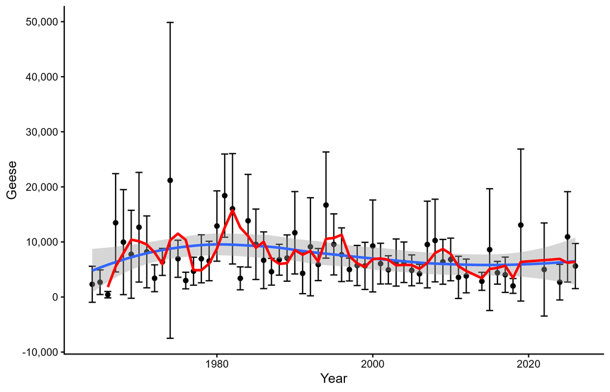

Figure 6: Lesser Canada goose abundance in spring. Circles are annual estimates of abundance with 95% confidence intervals. The red line is a moving 3-year average and the blue line is a smoothed (Loess model) line with 95% confidence interval (shaded area) fit to the annual estimates.

Time series statistics

| Parameter | Estimate | SE | L95%CI | U95%CI |
| --- | --- | --- | --- | --- |
| 1-year index | 5,621 | 2,089 | 1,526 | 9,716 |
| 3-year index<sup>a</sup> | 6,413 | 2,864 | 799 | 12,027 |
| LTA | 7,465 |  |  |  |
| Objective |  |  |  |  |
| % change from LTA | -25 |  |  |  |
| % change from obj |  |  |  |  |
| Mgmt index (n years) | 1 |  |  |  |

<sup>a</sup> 2024, 2025, 2026

**Harvest Strategy**  
Management index: Total lesser Canada geese in spring.

Management thresholds: N/A.

Management prescription: N/A.

Regulatory alternatives:  
Regulations fixed until changed.

### Data Table 7: Canada Goose, Western PFP

Original data source: Waterfowl Breeding Population and Habitat Survey (WBPHS) strata in Alberta and Montana (i.e., strata 76, and portions of strata 26–29 and 41–42); and State/Provincial Waterfowl Breeding Population Surveys in British Columbia, eastern Washington, eastern Oregon, and northeast California; USFWS Headquarters, British Columbia, Washington, Oregon, and California. Data maintained by USFWS Headquarters, Canadian Wildlife Service Pacific and Yukon Region, Washington, Oregon, California, and USFWS Pacific Flyway Office.

Provided in the table below are abundance and standard error(SE) of Pacific Flyway Population western Canada geese by survey (WBPHS in Alberta and Montana, and state/provincial surveys in British Columbia, Washington, Oregon, California) and in total for the State survey areas (State) and for all surveys combined (Total) in spring. Also provided are the total abundance moving 3-year average (M3yr) and standard error (M3yr.SE).

Table 7. Pacific Flyway Population western Canada goose abundance in spring, 2010-2026.

| Year | WBPHS | WBPHS.SE | BC | BC.SE | WA | WA.SE | OR | OR.SE | CA | CA.SE | State | State.SE | Total | Total.SE | M3yr | M3yr.SE |
| --- | --- | --- | --- | --- | --- | --- | --- | --- | --- | --- | --- | --- | --- | --- | --- | --- |
| 2010 | 162,421 | 23,611 | 33,296 | 4,154 | 18,696 | 4,353 | 31,642 | 4,416 | 33,155 | 8,178 | 116,789 | 33,985 | 279,210 | 41,382 | NA | NA |
| 2011 | 128,327 | 17,146 | 33,566 | 4,507 | 31,176 | 7,258 | 38,062 | 5,349 | 36,476 | 14,552 | 139,280 | 37,843 | 267,607 | 41,546 | NA | NA |
| 2012 | 184,960 | 22,519 | 35,787 | 4,834 | 29,308 | 5,925 | 40,920 | 5,699 | 42,181 | 14,288 | 148,197 | 43,246 | 333,157 | 48,758 | 293,325 | 44,030 |
| 2013 | 200,545 | 20,814 | 34,370 | 4,812 | 26,577 | 7,789 | 37,107 | 4,109 | 68,248 | 20,484 | 166,302 | 68,982 | 366,848 | 72,054 | 322,537 | 55,663 |
| 2014 | 146,746 | 15,934 | 34,120 | 3,863 | 38,832 | 8,779 | 39,671 | 5,068 | 31,209 | 14,497 | 143,831 | 33,040 | 290,577 | 36,682 | 330,194 | 54,512 |
| 2015 | 234,091 | 28,564 | 35,285 | 3,359 | 33,347 | 8,121 | 43,167 | 6,690 | 44,322 | 16,368 | 156,121 | 45,678 | 390,212 | 53,873 | 349,212 | 56,094 |
| 2016 | 319,990 | 34,525 | 39,980 | 5,200 | 24,678 | 6,375 | 40,968 | 6,851 | 44,323 | 11,234 | 149,949 | 45,597 | 469,939 | 57,193 | 383,576 | 50,063 |
| 2017 | 240,038 | 26,345 | 39,359 | 5,106 | 27,461 | 5,331 | 40,801 | 7,648 | 55,224 | 20,731 | 162,846 | 56,238 | 402,884 | 62,103 | 421,012 | 57,822 |
| 2018 | 316,119 | 38,653 | 34,646 | 3,532 | 36,662 | 8,491 | 49,646 | 9,647 | 52,121 | 14,984 | 173,076 | 53,798 | 489,195 | 66,244 | 454,006 | 61,957 |
| 2019 | 237,515 | 28,542 | 31,737 | 3,945 | 43,749 | 9,974 | 41,679 | 7,379 | 48,588 | 14,417 | 165,752 | 50,302 | 403,267 | 57,835 | 431,782 | 62,156 |
| 2020 | NA | NA | NA | NA | NA | NA | NA | NA | NA | NA | NA | NA | NA | NA | NA | NA |
| 2021 | NA | NA | NA | NA | NA | NA | NA | NA | NA | NA | NA | NA | NA | NA | NA | NA |
| 2022 | 328,298 | 36,271 | 26,213 | 3,314 | 31,808 | 8,827 | 37,622 | 4,684 | 46,079 | 9,930 | 141,721 | 47,266 | 470,019 | 59,579 | 454,160 | 61,327 |
| 2023 | 259,223 | 27,356 | 20,698 | 2,212 | 24,570 | 6,360 | 22,189 | 3,668 | 52,575 | 11,907 | 120,032 | 53,132 | 379,255 | 59,760 | 417,514 | 59,065 |
| 2024 | 214,602 | 33,290 | 20,795 | 2,084 | 22,756 | 4,342 | 27,875 | 4,065 | 34,242 | 10,048 | 105,668 | 34,817 | 320,270 | 48,171 | 389,848 | 56,099 |
| 2025 | 276,178 | 31,282 | 28,887 | 2,694 | 28,746 | 7,158 | 29,505 | 4,520 | 61,710 | 17,462 | 148,848 | 62,347 | 425,026 | 69,754 | 374,850 | 59,882 |
| 2026 | 208,641 | 18,812 | 28,438 | 3,458 | 24,029 | 5,716 | 38,906 | 5,712 | 50,611 | 15,847 | 141,983 | 51,368 | 350,624 | 54,705 | 365,307 | 58,249 |

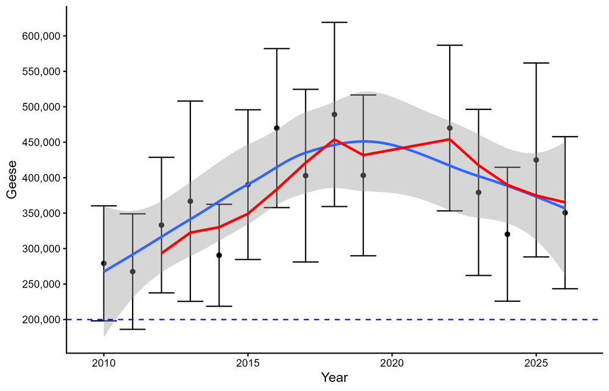

Figure 7: Pacific Flyway Population western Canada goose abundance in spring. Circles are annual estimates of abundance with 95% confidence intervals. The red line is a moving 3-year average and the blue line is a smoothed (Loess model) line with 95% confidence interval (shaded area) fit to the annual estimates. The blue dashed reference line is the Councils’ minimum population objective.

Time series statistics

| Parameter | Estimate | SE | L95%CI | U95%CI |
| --- | --- | --- | --- | --- |
| 1-year index | 350,624 | 54,705 | 243,403 | 457,846 |
| 3-year index<sup>a</sup> | 365,307 | 58,249 | 251,140 | 479,474 |
| LTA | 377,676 |  |  |  |
| Objective | 200,000 |  |  |  |
| % change from LTA | -7 |  |  |  |
| % change from obj | 83 |  |  |  |
| Mgmt index (n years) | 3 |  |  |  |

<sup>a</sup> 2024, 2025, 2026

**Harvest Strategy**  
Management index: Total western Canada geese in spring.

Management thresholds: N/A.

Management prescription: N/A.

Regulatory alternatives:  
Regulations fixed until changed.

### Data Table 8: Emperor Goose

Original data source: Yukon Kuskokwim Delta Coastal Zone Survey; USFWS Alaska Region. Data maintained by USFWS Alaska Region.

Provided in the table below are abundance and standard error (SE) of emperor geese in spring. Also provided are the abundance moving 3-year average (M3yr) and standard error (M3yr.SE).

Table 8. Emperor goose abundance in spring, 1985-2026.

| Year | Total | Total.SE | M3yr | M3yr.SE |
| --- | --- | --- | --- | --- |
| 1985 | 19,254 | 1,392 | NA | NA |
| 1986 | 11,581 | 865 | NA | NA |
| 1987 | 10,625 | 1,003 | 13,820 | 1,109 |
| 1988 | 13,067 | 1,022 | 11,758 | 966 |
| 1989 | 14,204 | 1,029 | 12,632 | 1,018 |
| 1990 | 14,645 | 1,083 | 13,972 | 1,045 |
| 1991 | 12,464 | 1,089 | 13,771 | 1,067 |
| 1992 | 12,928 | 818 | 13,346 | 1,005 |
| 1993 | 15,523 | 1,105 | 13,638 | 1,013 |
| 1994 | 16,843 | 934 | 15,098 | 959 |
| 1995 | 17,729 | 1,105 | 16,698 | 1,051 |
| 1996 | 23,885 | 2,431 | 19,486 | 1,633 |
| 1997 | 22,446 | 1,453 | 21,354 | 1,755 |
| 1998 | 20,047 | 980 | 22,126 | 1,731 |
| 1999 | 19,651 | 1,337 | 20,715 | 1,273 |
| 2000 | 16,633 | 877 | 18,777 | 1,083 |
| 2001 | 26,338 | 1,384 | 20,874 | 1,221 |
| 2002 | 18,726 | 1,132 | 20,566 | 1,150 |
| 2003 | 20,588 | 1,548 | 21,884 | 1,365 |
| 2004 | 20,987 | 1,068 | 20,100 | 1,267 |
| 2005 | 20,551 | 1,291 | 20,709 | 1,317 |
| 2006 | 24,997 | 1,534 | 22,178 | 1,311 |
| 2007 | 25,126 | 1,648 | 23,558 | 1,498 |
| 2008 | 21,811 | 1,095 | 23,978 | 1,445 |
| 2009 | 20,287 | 1,175 | 22,408 | 1,329 |
| 2010 | 19,760 | 1,072 | 20,620 | 1,115 |
| 2011 | 20,660 | 1,184 | 20,236 | 1,145 |
| 2012 | 20,159 | 1,647 | 20,193 | 1,325 |
| 2013 | 29,390 | 2,171 | 23,403 | 1,715 |
| 2014 | 30,685 | 2,763 | 26,745 | 2,241 |
| 2015 | 27,767 | 1,694 | 29,281 | 2,252 |
| 2016 | 33,277 | 2,384 | 30,577 | 2,323 |
| 2017 | 29,146 | 1,684 | 30,063 | 1,949 |
| 2018 | 29,509 | 1,680 | 30,644 | 1,945 |
| 2019 | 25,791 | 1,472 | 28,148 | 1,615 |
| 2020 | NA | NA | NA | NA |
| 2021 | 23,297 | 1,200 | 26,199 | 1,464 |
| 2022 | 27,978 | 1,488 | 25,689 | 1,393 |
| 2023 | 23,357 | 1,480 | 24,877 | 1,396 |
| 2024 | 17,223 | 1,040 | 22,853 | 1,352 |
| 2025 | 22,181 | 1,168 | 20,920 | 1,243 |
| 2026 | 24,019 | 1,783 | 21,141 | 1,369 |

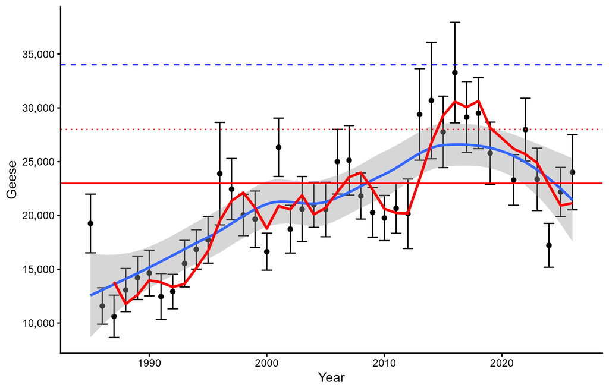

Figure 8: Emperor goose abundance in spring. Circles are annual estimates of abundance with 95% confidence intervals. The red line is a moving 3-year average and the blue line is a smoothed (Loess model) line with 95% confidence interval (shaded area) fit to the annual estimates. The blue dashed reference line is the Pacific Flyway Council’s population objective. The red dashed reference line is the threshold where restrictions are considered and the red reference line is the closure threshold.

Time series statistics

| Parameter | Estimate | SE | L95%CI | U95%CI |
| --- | --- | --- | --- | --- |
| 1-year index | 24,019 | 1,783 | 20,525 | 27,513 |
| 3-year index<sup>a</sup> | 21,141 | 1,369 | 18,457 | 23,825 |
| LTA | 21,028 |  |  |  |
| Objective | 34,000 |  |  |  |
| % change from LTA | 14 |  |  |  |
| % change from obj | -29 |  |  |  |
| Mgmt index (n years) | 1 |  |  |  |

<sup>a</sup> 2024, 2025, 2026

**Harvest Strategy**  
Management index: Total emperor geese in spring.

Management thresholds:  
≥28,000 Standard  
≥23,000 Consider Restrictions  
Closed

Management prescription: Consider restrictions.

Regulatory alternatives:  
Standard  
Quota of 500 birds  
Restrictive  
Quota of 250 birds  
Closed

### Data Table 9: Ross’s Goose

Original data source: Lincoln (harvest/harvest rate) estimates of adult abundance in summer; USFWS Headquarters. Data maintained by USFWS Headquarters.

Provided in the table below are adult abundance (Estimate) and standard error (SE) of Ross’s geese in summer. Also provided are the abundance moving 3-year average (M3yr) and standard error (M3yr.SE).

Table 9. Ross's goose abundance in summer, 1989-2024.

| Year | Estimate | SE | M3yr | M3yr.SE |
| --- | --- | --- | --- | --- |
| 1989 | 116,866 | 71,045 | 116,866 | 71,923 |
| 1990 | 258,492 | 157,995 | 187,679 | 86,293 |
| 1991 | 168,034 | 102,061 | 181,131 | 66,984 |
| 1992 | 83,320 | 50,424 | 169,949 | 64,331 |
| 1993 | NA | NA | 125,677 | 56,872 |
| 1994 | 94,495 | 37,188 | 88,908 | 31,657 |
| 1995 | 434,328 | 263,963 | 264,412 | 132,596 |
| 1996 | NA | NA | 264,412 | 132,596 |
| 1997 | 375,367 | 95,064 | 404,848 | 139,154 |
| 1998 | 702,478 | 141,465 | 538,923 | 85,082 |
| 1999 | 669,387 | 130,240 | 582,411 | 71,399 |
| 2000 | 1,150,308 | 241,587 | 840,724 | 104,282 |
| 2001 | 1,480,683 | 365,152 | 1,100,126 | 153,035 |
| 2002 | 1,551,512 | 248,810 | 1,394,168 | 170,037 |
| 2003 | 909,787 | 155,679 | 1,313,994 | 156,994 |
| 2004 | 1,327,719 | 197,082 | 1,263,006 | 118,680 |
| 2005 | 1,077,835 | 141,826 | 1,105,114 | 98,043 |
| 2006 | 1,205,217 | 140,028 | 1,203,590 | 95,387 |
| 2007 | 2,294,146 | 305,862 | 1,525,733 | 122,216 |
| 2008 | 2,819,327 | 376,741 | 2,106,230 | 168,437 |
| 2009 | 1,897,032 | 312,017 | 2,336,835 | 192,648 |
| 2010 | 3,151,489 | 436,369 | 2,622,616 | 219,826 |
| 2011 | 2,769,111 | 367,864 | 2,605,877 | 219,859 |
| 2012 | 3,197,823 | 438,758 | 3,039,474 | 240,358 |
| 2013 | 3,863,577 | 504,961 | 3,276,837 | 251,492 |
| 2014 | 6,165,750 | 856,593 | 4,409,050 | 363,519 |
| 2015 | 2,036,736 | 237,162 | 4,022,021 | 342,732 |
| 2016 | 3,324,330 | 368,058 | 3,842,272 | 320,248 |
| 2017 | 2,858,910 | 414,999 | 2,739,992 | 199,983 |
| 2018 | 3,161,910 | 576,628 | 3,115,050 | 266,465 |
| 2019 | 2,744,717 | 360,455 | 2,921,846 | 264,730 |
| 2020 | NA | NA | 2,953,314 | 342,333 |
| 2021 | NA | NA | 2,744,717 | 360,280 |
| 2022 | 1,138,224 | 174,201 | 1,138,224 | 172,823 |
| 2023 | 3,594,202 | 488,960 | 2,366,213 | 259,344 |
| 2024 | 1,394,040 | 177,372 | 2,042,155 | 183,318 |

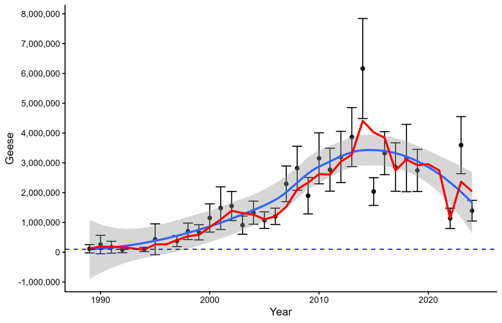

Figure 9: Ross’s goose abundance in summer. Circles are annual estimates of abundance with 95% confidence intervals. The red line is a moving 3-year average and the blue line is a smoothed (Loess model) line with 95% confidence interval (shaded area) fit to the annual estimates. The blue dashed reference line is the Pacific Flyway Council’s minimum population objective.

Time series statistics

| Parameter | Estimate | SE | L95%CI | U95%CI |
| --- | --- | --- | --- | --- |
| 1-year index | 1,394,040 | 177,372 | 1,046,391 | 1,741,689 |
| 3-year index<sup>a</sup> | 2,042,155 | 183,318 | 1,682,852 | 2,401,458 |
| LTA | 1,826,552 |  |  |  |
| Objective | 150,000 |  |  |  |
| % change from LTA | -24 |  |  |  |
| % change from obj | 829 |  |  |  |
| Mgmt index (n years) | 1 |  |  |  |

<sup>a</sup> 2022, 2023, 2024

**Harvest Strategy**  
Management index: Adult Ross’s geese in summer.

Management thresholds:  
≥100,000 Standard  
Restrictive

Management prescription: Standard.

Regulatory alternatives:  
Regulations fixed until changed.

### Data Table 10: Snow Goose, WIP and WAP

Original data source: Pacific Flyway Cooperative Light Goose Winter Survey; Washington, Oregon, and California. Data maintained by Washington, Oregon, and California.

Provided in the table below are abundance of Wrangel Island Population and Western Arctic Population lesser snow geese by area including Skagit-Fraser River Deltas in Washington and British Columbia (Sk-Fr), Oregon-Washington Columbia River east (ColR.E), Oregon-Washington Columbia River west (ColR.W), balance of Oregon (OR), California (CA), and in total (Total). In California, the percentage of the white geese count that are Ross’s geese (CARoss%) are recorded periodically and is modeled to estimate the percentage of Ross’s geese smoothed over all years (CARossAdj%). The number of lesser snow geese in California (CASnow) is derived by subtracting the percentage of the white goose count that are Ross’s geese and is the metric used to monitor abundance of Western Arctic Population lesser snow geese in winter. In the Skagit-Fraser area, the percentage of the lesser snow goose count that are juveniles (Juv%) is reported and used to derive the number of adult snow geese in the Skagit-Fraser count (AdultSk). Adult snow geese is the metric used to monitor abundance of Wrangel Island Population lesser snow geese in winter. Also provided are moving 3-year averages for snow geese in California (M3yrCA) and adult snow geese in the Skagit-Fraser (M3yrSk). So long as there are counts in Sakgit-Fraser and California, the total winter count is interpreted as the minimum known population size with no variance.

Table 10. Wrangel Island Population and Western Arctic Population lesser snow geese in winter, 1979-2025.

| Year | Sk-Fr | ColR.E | ColR.W | OR | CA | Total | CARoss% | CARossAdj% | CASnow | M3yrCA | Juv% | AdultSk | M3yrSk |
| --- | --- | --- | --- | --- | --- | --- | --- | --- | --- | --- | --- | --- | --- |
| 1979 | 35,600 | NA | NA | NA | 492,500 | 528,100 | NA | 36.3 | 313,674 | NA | NA | NA | NA |
| 1980 | 22,400 | NA | NA | NA | 181,800 | 204,200 | NA | 37.0 | 114,500 | NA | 19.0 | 18,144 | NA |
| 1981 | 48,600 | NA | NA | NA | 711,300 | 759,900 | NA | 37.7 | 443,388 | 290,521 | NA | NA | NA |
| 1982 | 26,100 | NA | NA | NA | 328,000 | 354,100 | NA | 38.2 | 202,542 | 253,477 | 5.8 | 24,586 | NA |
| 1983 | 24,500 | NA | NA | NA | 523,100 | 547,600 | NA | 38.8 | 320,287 | 322,072 | 0.0 | 24,500 | 22,410 |
| 1984 | 26,600 | NA | NA | NA | 439,700 | 466,300 | NA | 39.2 | 267,201 | 263,344 | 12.6 | 23,248 | 24,112 |
| 1985 | 46,200 | NA | NA | NA | 503,600 | 549,800 | NA | 39.6 | 304,032 | 297,173 | 24.0 | 35,112 | 27,620 |
| 1986 | 39,900 | NA | NA | NA | 481,800 | 521,700 | NA | 40.0 | 289,256 | 286,830 | 25.0 | 29,925 | 29,428 |
| 1987 | 47,700 | NA | NA | NA | 477,600 | 525,300 | NA | 40.2 | 285,432 | 292,906 | 40.0 | 28,620 | 31,219 |
| 1988 | 43,800 | NA | NA | NA | 397,200 | 441,000 | NA | 40.4 | 236,545 | 270,411 | NA | NA | NA |
| 1989 | 32,200 | NA | NA | NA | 431,700 | 463,900 | 41.9 | 40.6 | 256,451 | 259,476 | NA | NA | NA |
| 1990 | 31,700 | NA | NA | NA | 676,800 | 708,500 | 43.6 | 40.7 | 401,471 | 298,156 | NA | NA | NA |
| 1991 | 39,100 | NA | NA | NA | 651,000 | 690,100 | NA | 40.7 | 386,012 | 347,978 | 28.6 | 27,917 | 28,821 |
| 1992 | 34,300 | NA | NA | NA | 605,000 | 639,300 | 36.9 | 40.7 | 358,970 | 382,151 | NA | NA | NA |
| 1993 | 49,100 | NA | NA | NA | 520,100 | 569,200 | NA | 40.6 | 309,120 | 351,367 | NA | NA | NA |
| 1994 | 42,600 | NA | NA | NA | 435,600 | 478,200 | NA | 40.4 | 259,608 | 309,232 | 8.5 | 38,979 | 31,839 |
| 1995 | 37,000 | NA | NA | NA | 464,400 | 501,400 | NA | 40.2 | 277,819 | 282,182 | 5.4 | 35,002 | 33,966 |
| 1996 | 45,800 | NA | NA | NA | 320,500 | 366,300 | NA | 39.9 | 192,656 | 243,361 | NA | NA | NA |
| 1997 | 47,000 | NA | NA | NA | 369,400 | 416,400 | NA | 39.5 | 223,343 | 231,272 | 16.2 | 39,386 | 37,789 |
| 1998 | 47,100 | NA | NA | NA | 307,200 | 354,300 | NA | 39.1 | 187,002 | 201,000 | 13.2 | 40,883 | 38,424 |
| 1999 | 28,600 | NA | NA | NA | 550,400 | 579,000 | NA | 38.7 | 337,658 | 249,334 | 15.6 | 24,138 | 34,802 |
| 2000 | 56,300 | NA | NA | NA | 600,500 | 656,800 | 38.4 | 38.1 | 371,617 | 298,759 | 20.3 | 44,871 | 36,631 |
| 2001 | 52,000 | NA | NA | NA | 396,200 | 448,200 | NA | 37.5 | 247,560 | 318,945 | 21.1 | 41,028 | 36,679 |
| 2002 | 73,100 | NA | NA | NA | 523,700 | 596,800 | NA | 36.9 | 330,690 | 316,622 | 26.7 | 53,582 | 46,494 |
| 2003 | 66,800 | NA | NA | NA | 521,000 | 587,800 | NA | 36.1 | 332,756 | 303,669 | 12.8 | 58,250 | 50,953 |
| 2004 | 68,141 | NA | NA | NA | 682,128 | 750,269 | NA | 35.3 | 441,027 | 368,158 | 15.3 | 57,715 | 56,516 |
| 2005 | 80,040 | NA | NA | NA | 630,686 | 710,726 | 34.8 | 34.5 | 413,117 | 395,633 | 32.7 | 53,867 | 56,611 |
| 2006 | 83,148 | NA | NA | NA | 719,810 | 802,958 | NA | 33.6 | 478,050 | 444,065 | 21.2 | 65,521 | 59,034 |
| 2007 | 94,856 | NA | NA | NA | 978,622 | 1,073,478 | NA | 32.6 | 659,455 | 516,874 | 21.8 | 74,177 | 64,522 |
| 2008 | NA | NA | NA | NA | 900,403 | NA | 31.3 | 31.6 | 616,066 | 584,524 | NA | NA | NA |
| 2009 | 78,989 | NA | NA | NA | 827,055 | 906,044 | NA | 30.5 | 574,956 | 616,826 | 40.0 | 47,393 | 62,364 |
| 2010 | 63,641 | NA | NA | NA | 800,156 | 863,797 | NA | 29.3 | 565,535 | 585,519 | 4.4 | 60,841 | 60,804 |
| 2011 | 69,964 | NA | NA | NA | 1,027,887 | 1,097,851 | 25.6 | 28.1 | 739,051 | 626,514 | 20.6 | 55,551 | 54,595 |
| 2012 | 67,198 | NA | NA | NA | 824,432 | 891,630 | NA | 26.8 | 603,354 | 635,980 | 18.6 | 54,699 | 57,030 |
| 2013 | 69,685 | NA | NA | NA | 1,275,890 | 1,345,575 | NA | 25.5 | 950,929 | 764,445 | 23.8 | 53,100 | 54,450 |
| 2014 | 66,501 | NA | NA | NA | 1,141,579 | 1,208,080 | 31.9 | 24.1 | 866,908 | 807,064 | 8.5 | 60,835 | 56,211 |
| 2015 | 81,195 | 7,930 | 11,892 | 44 | NA | NA | NA | 22.6 | NA | NA | 26.8 | 59,435 | 57,790 |
| 2016 | 103,617 | 15,447 | 14,215 | 16 | 1,773,493 | 1,906,788 | NA | 21.1 | 1,400,062 | 1,072,633 | 33.4 | 69,009 | 63,093 |
| 2017 | 86,553 | 33,274 | 18,080 | 0 | 1,217,295 | 1,355,202 | 11.5 | 19.5 | 980,401 | 1,082,457 | 15.4 | 73,224 | 67,222 |
| 2018 | 109,993 | 52,841 | 18,241 | 26 | 1,232,663 | 1,413,764 | NA | 17.8 | 1,013,214 | 1,131,226 | 20.6 | 87,334 | 76,522 |
| 2019 | NA | 160,825 | 24,394 | 30 | 1,414,392 | NA | NA | 16.1 | 1,186,920 | 1,060,178 | NA | NA | NA |
| 2020 | 133,306 | 153,690 | NA | NA | NA | NA | NA | 14.3 | NA | NA | 30.0 | 93,314 | 84,624 |
| 2021 | 120,725 | 119,771 | 35,748 | 276 | NA | NA | NA | 12.5 | NA | NA | 16.1 | 101,288 | 93,979 |
| 2022 | 91,608 | 64,745 | 19,445 | 2 | 1,093,828 | 1,269,628 | 17.1 | 10.5 | 978,445 | 1,059,526 | 4.6 | 87,394 | 93,999 |
| 2023 | 66,355 | 162,586 | 17,171 | 25 | 1,238,593 | 1,484,730 | NA | 8.6 | 1,132,330 | 1,099,232 | NA | NA | NA |
| 2024 | 96,249 | 136,897 | 15,204 | 3,203 | 1,077,086 | 1,328,639 | NA | 6.5 | 1,006,561 | 1,039,112 | 3.8 | 92,592 | 93,758 |
| 2025 | 76,424 | 147,147 | 15,189 | 975 | NA | NA | NA | 4.5 | NA | NA | 5.0 | 72,615 | 84,200 |

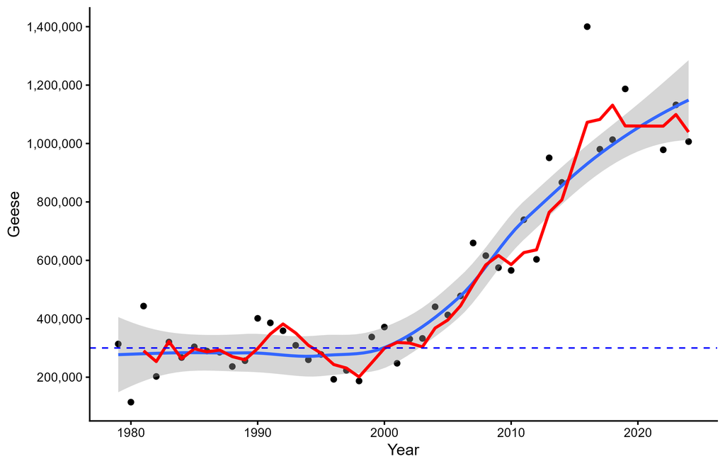

Figure 10: Western Arctic Population lesser snow goose abundance in winter in California. Circles are annual estimates of abundance with 95% confidence intervals. The red line is a moving 3-year average and the blue line is a smoothed (Loess model) line with 95% confidence interval (shaded area) fit to the annual estimates. The blue dashed reference line is the Pacific Flyway Council’s minimum population objective.

Time series statistics

| Parameter | Estimate | SE | L95%CI | U95%CI |
| --- | --- | --- | --- | --- |
| 1-year index | 1,006,561 |  |  |  |
| 3-year index<sup>a</sup> | 1,039,112 |  |  |  |
| LTA | 496,415 |  |  |  |
| Objective | 300,000 |  |  |  |
| % change from LTA | 103 |  |  |  |
| % change from obj | 246 |  |  |  |
| Mgmt index (n years) | 3 |  |  |  |

<sup>a</sup> 2022, 2023, 2024

**Harvest Strategy**  
Western Arctic Population of Lesser Snow Geese

Management index: Total lesser snow geese in winter in California.

Management thresholds:  
≥300,000 Standard Restrictive

Regulatory alternatives:  
Regulations fixed until changed.

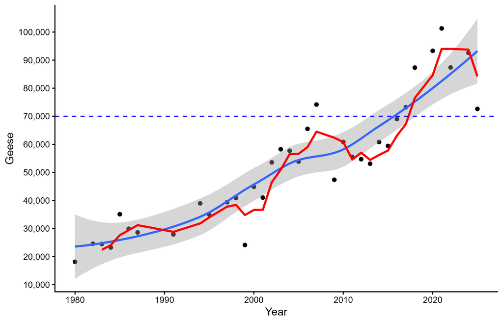

Figure 11: Wrangel Island Population lesser snow goose adult abundance in winter in Skagit-Fraser River Delta areas. Circles are annual estimates of abundance with 95% confidence intervals. The red line is a moving 3-year average and the blue line is a smoothed (Loess model) line with 95% confidence interval (shaded area) fit to the annual estimates. The blue dashed reference line is the Pacific Flyway Council’s minimum population objective.

Time series statistics

| Parameter | Estimate | SE | L95%CI | U95%CI |
| --- | --- | --- | --- | --- |
| 1-year index | 72,615 |  |  |  |
| 3-year index<sup>a</sup> | 84,200 |  |  |  |
| LTA | 52,442 |  |  |  |
| Objective | 70,000 |  |  |  |
| % change from LTA | 38 |  |  |  |
| % change from obj | 20 |  |  |  |
| Mgmt index (n years) | 3 |  |  |  |

<sup>a</sup> 2022, 2024, 2025

Wrangel Island Population of Lesser Snow Geese

Management index: Total adult lesser snow geese in winter in Skagit-Fraser River Delta areas.

Management thresholds:  
≥70,000 Standard  
Restrictive

Management prescription: Standard.

Regulatory alternatives:  
Regulations fixed until changed.

### Data Table 11: White-fronted Goose, MP

Original data source: Lincoln (harvest/harvest rate) estimates of adult abundance in summer and adult harvest rate; USFWS Headquarters. Data maintained by USFWS Headquarters.

Provided in the table below are adult abundance (N) and standard error (N.SE) of Midcontinent Population white-fronted geese in summer and harvest rate (h) and standard error (h.SE). Also provided are the moving 3-year average abundance (N.M3yr) and harvest rate (h.M3yr) and associated standard errors (N.M3yr.SE and h.M3yr.SE).

Table 11. Midcontinent Population white-fronted goose adult abundance in summer and harvest rate, 1976-2025. Note that moving 3-year averages are calculated as the most recent three years regardless of missing data so long as there are at least 2 years of data.

| Year | N | N.SE | N.M3yr | N.M3yr.SE | hrate | hrate.SE | h.M3yr | h.M3yr.SE |
| --- | --- | --- | --- | --- | --- | --- | --- | --- |
| 1976 | 548,392 | 82,909 | NA | NA | 0.076 | 0.009 | NA | NA |
| 1977 | 663,673 | 112,369 | NA | NA | 0.084 | 0.009 | NA | NA |
| 1978 | 609,879 | 96,700 | 607,315 | 56,798 | 0.088 | 0.010 | 0.083 | 0.005 |
| 1979 | 649,406 | 102,968 | 640,986 | 59,458 | 0.081 | 0.009 | 0.084 | 0.005 |
| 1980 | NA | NA | 629,643 | 70,230 | 0.073 | 0.009 | 0.081 | 0.005 |
| 1981 | NA | NA | 649,406 | 102,827 | 0.063 | 0.008 | 0.072 | 0.005 |
| 1982 | NA | NA | NA | NA | NA | NA | NA | NA |
| 1983 | NA | NA | NA | NA | NA | NA | NA | NA |
| 1984 | NA | NA | NA | NA | NA | NA | NA | NA |
| 1985 | NA | NA | NA | NA | NA | NA | NA | NA |
| 1986 | 824,882 | 377,741 | 824,882 | 384,772 | 0.050 | 0.008 | 0.058 | 0.005 |
| 1987 | 978,743 | 259,163 | 901,813 | 230,688 | 0.054 | 0.008 | 0.055 | 0.005 |
| 1988 | 1,338,163 | 365,765 | 1,047,263 | 195,838 | 0.057 | 0.007 | 0.054 | 0.004 |
| 1989 | 1,577,792 | 461,455 | 1,298,233 | 213,493 | 0.061 | 0.008 | 0.057 | 0.004 |
| 1990 | 3,207,371 | 838,970 | 2,041,109 | 341,383 | 0.053 | 0.006 | 0.057 | 0.004 |
| 1991 | 2,118,453 | 701,896 | 2,301,206 | 401,116 | 0.050 | 0.007 | 0.055 | 0.004 |
| 1992 | 939,262 | 171,931 | 2,088,362 | 376,508 | 0.065 | 0.008 | 0.056 | 0.004 |
| 1993 | 1,363,733 | 406,475 | 1,473,816 | 282,122 | 0.060 | 0.008 | 0.058 | 0.004 |
| 1994 | 1,710,598 | 379,757 | 1,337,864 | 195,129 | 0.058 | 0.007 | 0.061 | 0.004 |
| 1995 | 1,473,763 | 294,378 | 1,516,031 | 210,982 | 0.055 | 0.006 | 0.058 | 0.004 |
| 1996 | 1,926,808 | 393,427 | 1,703,723 | 210,970 | 0.060 | 0.006 | 0.058 | 0.004 |
| 1997 | 1,710,929 | 249,022 | 1,703,833 | 187,989 | 0.060 | 0.005 | 0.058 | 0.003 |
| 1998 | 2,122,517 | 359,872 | 1,920,085 | 199,369 | 0.056 | 0.005 | 0.059 | 0.003 |
| 1999 | 1,477,936 | 180,223 | 1,770,461 | 157,708 | 0.068 | 0.005 | 0.061 | 0.003 |
| 2000 | 2,630,828 | 342,496 | 2,077,094 | 175,544 | 0.059 | 0.004 | 0.061 | 0.003 |
| 2001 | 1,963,053 | 265,776 | 2,023,939 | 157,584 | 0.061 | 0.004 | 0.063 | 0.003 |
| 2002 | 2,448,836 | 389,128 | 2,347,572 | 196,494 | 0.053 | 0.004 | 0.058 | 0.002 |
| 2003 | 1,209,580 | 153,165 | 1,873,823 | 165,770 | 0.063 | 0.004 | 0.059 | 0.002 |
| 2004 | 1,510,728 | 192,304 | 1,723,048 | 151,738 | 0.063 | 0.004 | 0.060 | 0.002 |
| 2005 | 1,934,259 | 272,627 | 1,551,522 | 122,736 | 0.054 | 0.004 | 0.060 | 0.002 |
| 2006 | 2,581,737 | 369,630 | 2,008,908 | 167,664 | 0.048 | 0.003 | 0.055 | 0.002 |
| 2007 | 3,194,390 | 415,236 | 2,570,129 | 206,482 | 0.049 | 0.003 | 0.050 | 0.002 |
| 2008 | 3,400,841 | 451,102 | 3,058,989 | 237,469 | 0.046 | 0.003 | 0.048 | 0.002 |
| 2009 | 3,404,006 | 481,983 | 3,333,079 | 259,386 | 0.032 | 0.002 | 0.042 | 0.002 |
| 2010 | 2,970,195 | 389,285 | 3,258,347 | 254,226 | 0.039 | 0.003 | 0.039 | 0.002 |
| 2011 | 3,019,709 | 364,450 | 3,131,304 | 240,245 | 0.034 | 0.002 | 0.035 | 0.001 |
| 2012 | 2,820,347 | 324,571 | 2,936,751 | 207,083 | 0.037 | 0.002 | 0.037 | 0.001 |
| 2013 | 3,743,552 | 476,482 | 3,194,536 | 228,052 | 0.038 | 0.002 | 0.036 | 0.001 |
| 2014 | 3,944,541 | 555,694 | 3,502,813 | 268,870 | 0.036 | 0.002 | 0.037 | 0.001 |
| 2015 | 2,449,755 | 370,276 | 3,379,283 | 276,105 | 0.037 | 0.002 | 0.037 | 0.001 |
| 2016 | 3,254,721 | 421,598 | 3,216,339 | 263,395 | 0.042 | 0.002 | 0.038 | 0.001 |
| 2017 | 2,560,086 | 330,948 | 2,754,854 | 215,793 | 0.050 | 0.003 | 0.043 | 0.001 |
| 2018 | 3,027,396 | 399,088 | 2,947,401 | 219,052 | 0.038 | 0.002 | 0.043 | 0.001 |
| 2019 | 2,483,919 | 398,984 | 2,690,467 | 215,026 | 0.040 | 0.002 | 0.043 | 0.001 |
| 2020 | NA | NA | 2,755,657 | 277,342 | 0.037 | 0.003 | 0.038 | 0.001 |
| 2021 | 3,400,574 | 557,457 | 2,942,246 | 341,408 | 0.044 | 0.003 | 0.040 | 0.002 |
| 2022 | 1,356,346 | 178,898 | 2,378,460 | 290,873 | 0.055 | 0.003 | 0.045 | 0.002 |
| 2023 | 2,925,375 | 354,194 | 2,560,765 | 225,467 | 0.044 | 0.003 | 0.048 | 0.002 |
| 2024 | 3,068,244 | 445,630 | 2,449,988 | 199,338 | 0.055 | 0.004 | 0.051 | 0.002 |
| 2025 | NA | NA | NA | NA | 0.056 | 0.005 | 0.052 | 0.002 |

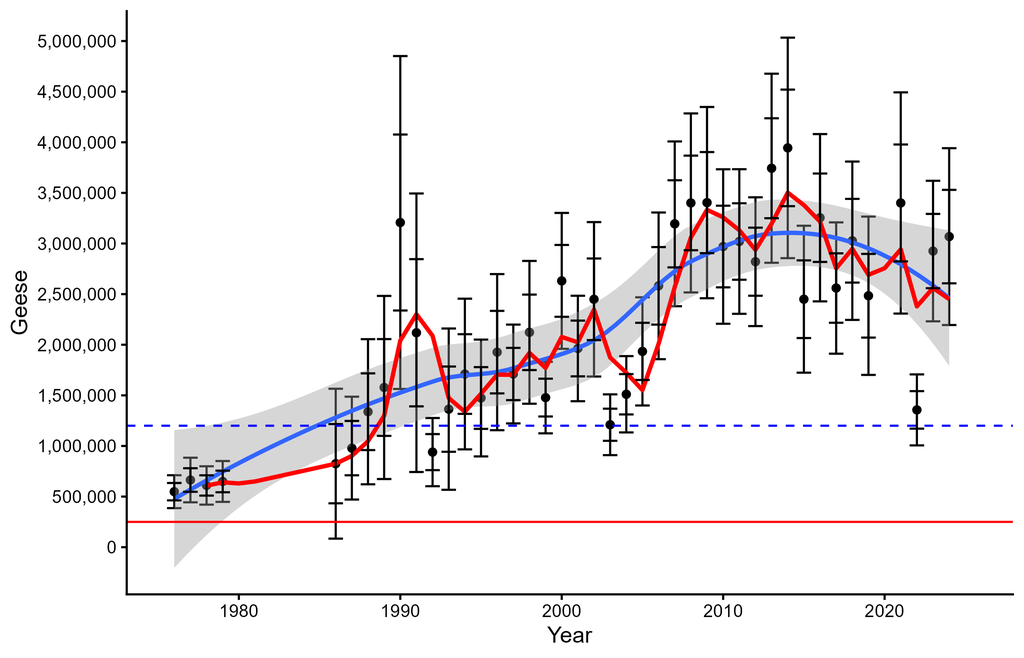

Figure 12: Midcontinent Population white-fronted goose abundance in summer. Circles are annual estimates of abundance with 95% and 70% confidence intervals. The red line is a moving 3-year average and the blue line is a smoothed (Loess model) line with 95% confidence interval (shaded area) fit to the annual estimates. The blue dashed reference line is the Councils’ minimum population objective and the restriction threshold if abundance is below 1.2 million geese AND adult harvest rate is above 0.075. The red reference line is the closure threshold.

Time series statistics for abundace

| Parameter | Estimate | SE | L95%CI | U95%CI |
| --- | --- | --- | --- | --- |
| 1-year index | 3,068,244 | 445,630 | 2,194,809 | 3,941,679 |
| 3-year index<sup>a</sup> | 2,449,988 | 199,338 | 2,059,286 | 2,840,691 |
| LTA | 2,133,587 |  |  |  |
| Objective | 1,200,000 |  |  |  |
| % change from LTA | 44 |  |  |  |
| % change from obj | 104 |  |  |  |
| Mgmt index (n years) | 3 |  |  |  |

<sup>a</sup> 2022, 2023, 2024

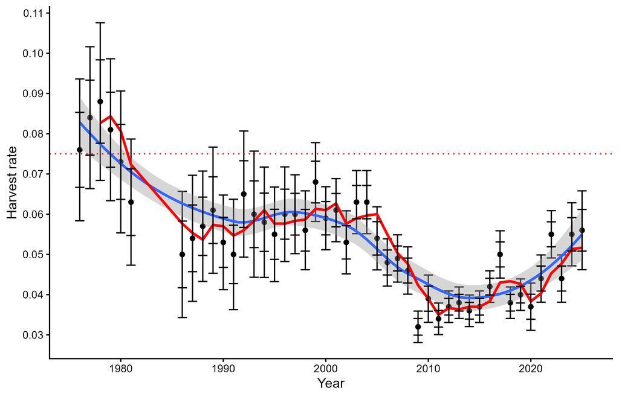

Figure 13: Midcontinent Population white-fronted goose adult harvest rate. Circles are annual estimates of harvest rate with 95% and 70% confidence intervals. The red line is a moving 3-year average and the blue line is a smoothed (Loess model) line with 95% confidence intervals (shaded area) fit to the annual estimates. The red dashed reference line is the restriction threshold if abundance is below 1.2 million geese (minumum population objective) AND adult harvest rate is above 0.075.

Time series statistics for harvest rate

| Parameter | Estimate | SE | L95%CI | U95%CI |
| --- | --- | --- | --- | --- |
| 1-year index | 0.056 | 0.005 | 0.046 | 0.066 |
| 3-year index<sup>a</sup> | 0.052 | 0.002 | 0.047 | 0.056 |
| LTA | 0.054 |  |  |  |
| Objective |  |  |  |  |
| % change from LTA | 3.875 |  |  |  |
| % change from obj |  |  |  |  |
| Mgmt index (n years) | 3.000 |  |  |  |

<sup>a</sup> 2023, 2024, 2025

Management thresholds:  
N≥1,200,000 or h≤7.5 Standard  
N<1,200,000 and h>7.5 Restrictive  
N<250,000 Closed

Management prescription: Standard.

Regulatory alternatives:  
Only the alternatives for the Pacific Flyway are shown here, and specifically Alaska. See the management plan for other flyway and state specific alternatives.  
Standard and Restrictive  
Season length is 107 days, bracket dates September 1 and January 26, and the daily bag limit is 4 geese

Decision framework: The Management prescription is based on two state variables; abundance and harvest rate. The probability distribution of the most recent 3-year averages relative to threshold values is used in a decision-analysis framework for setting harvest regulations. Eighty five percent of the distribution (confidence in the parameter estimate) must be below or above critical thresholds to prescribe a specific regulatory alternative. The 85% distribution corresponds to a confidence interval (CI) of 70% for the parameter estimate. Thus, if the upper or lower 70% CI for the parameter falls below or above the critical threshold value, then >85% of the distribution is below or above the threshold. The season is closed when >85% of the distribution for the most recent 3-year average population size is below 250,000 geese. A restrictive regulatory alternative is prescribed when >85% of the distribution for the most recent 3-year average population size is below 1,200,000 geese AND >85% of the distribution for the most recent 3-year average harvest rate is above 7.5%. A standard regulatory alternative is prescribed when conditions are not meet for either the restrictive or closed season regulatory alternatives.

### Data Table 12: White-fronted Goose, PP

Original data source: California Fall Survey of White-fronted Geese and Yukon Kuskokwim Coastal Zone Survey and Waterfowl Breeding Population and Habitat Survey (WBPHS; strata 8 (Bristol Bay) and 9 (YKD Inland); California and USFWS Alaska Region. Data maintained by California, USFWS Alaska Region, and USFWS Pacific Flyway Office.

Provided in the table below are abundance and standard error (SE) of Pacific Population white-fronted geese by survey and area including California Fall Survey (CAfall), and Yukon Kuskokwim Coastal Zone Survey (YKDCZ) and Waterfowl Breeding Population and Habitat Survey (WBPHS; strata 8 and 9). Also provided are the total for all spring survey areas (Spring). Total spring abundance is projected to fall abundance (PrjFall) via a fixed factor (estimated = 3.2732, SE = 0.1004) for visibility bias. Also provided are the projected fall abundance moving 3-year average (M3yr) and standard error (M3yr.SE).

Table 12. Pacific Population white-fronted goose abundance in spring, 1985-2026.

| Year | CAfall | YKDCZ | YKDCZ.SE | WPBHS8 | WPBHS8.SE | WPBHS9 | WPBHS9.SE | Spring | Spring.SE | PrjFall | PrjFall.SE | M3yr | M3yr.SE |
| --- | --- | --- | --- | --- | --- | --- | --- | --- | --- | --- | --- | --- | --- |
| 1985 | 93,900 | 17,398 | 841 | 6,241 | 3,467 | 9,563 | 3,735 | 33,203 | 5,165 | 108,681 | 17,238 | NA | NA |
| 1986 | 107,100 | 12,988 | 798 | 5,273 | 2,513 | 8,984 | 2,872 | 27,245 | 3,899 | 89,179 | 13,058 | NA | NA |
| 1987 | 130,600 | 14,167 | 1,247 | 4,520 | 2,044 | 6,665 | 2,001 | 25,352 | 3,121 | 82,982 | 10,532 | 93,614 | 13,887 |
| 1988 | 124,690 | 23,459 | 1,388 | 4,842 | 1,358 | 12,365 | 2,100 | 40,666 | 2,860 | 133,110 | 10,218 | 101,757 | 11,340 |
| 1989 | 263,350 | 26,546 | 2,022 | 6,672 | 3,125 | 9,853 | 2,723 | 43,070 | 4,611 | 140,980 | 15,709 | 119,024 | 12,411 |
| 1990 | 237,050 | 36,096 | 3,315 | 2,475 | 903 | 14,973 | 2,577 | 53,544 | 4,295 | 175,262 | 15,057 | 149,784 | 13,879 |
| 1991 | 215,655 | 30,180 | 1,977 | 5,596 | 1,592 | 11,205 | 2,604 | 46,981 | 3,637 | 153,781 | 12,810 | 156,674 | 14,578 |
| 1992 | 230,675 | 32,494 | 2,140 | 8,716 | 4,503 | 11,012 | 1,608 | 52,223 | 5,238 | 170,938 | 17,937 | 166,660 | 15,412 |
| 1993 | 253,820 | 39,976 | 2,696 | 1,614 | 939 | 19,320 | 5,259 | 60,910 | 5,984 | 199,372 | 20,529 | 174,697 | 17,390 |
| 1994 | 298,930 | 55,801 | 3,177 | 5,058 | 3,654 | 8,694 | 1,375 | 69,553 | 5,033 | 227,662 | 17,902 | 199,324 | 18,830 |
| 1995 | 251,970 | 77,149 | 4,623 | 3,228 | 1,331 | 8,501 | 1,692 | 88,878 | 5,099 | 290,917 | 18,935 | 239,317 | 19,153 |
| 1996 | 350,850 | 76,457 | 4,392 | 5,380 | 2,319 | 27,241 | 4,775 | 109,078 | 6,889 | 357,038 | 25,080 | 291,872 | 20,881 |
| 1997 | 318,954 | 82,489 | 4,561 | 4,520 | 3,444 | 20,286 | 4,473 | 107,294 | 7,258 | 351,198 | 26,097 | 333,051 | 23,584 |
| 1998 | 413,100 | 86,930 | 3,180 | 2,367 | 1,143 | 18,643 | 4,036 | 107,940 | 5,264 | 353,314 | 20,364 | 353,850 | 23,977 |
| 1999 | 285,514 | 90,843 | 6,265 | 4,304 | 1,682 | 25,107 | 3,966 | 120,253 | 7,603 | 393,618 | 27,673 | 366,043 | 24,910 |
| 2000 | 284,044 | 86,186 | 5,853 | 2,045 | 1,164 | 16,080 | 4,920 | 104,310 | 7,734 | 341,432 | 27,409 | 362,788 | 25,376 |
| 2001 | 337,848 | 111,746 | 6,713 | 7,533 | 5,867 | 23,414 | 6,551 | 142,693 | 11,064 | 467,068 | 38,962 | 400,706 | 31,807 |
| 2002 | 402,565 | 88,345 | 5,753 | 6,564 | 2,856 | 16,644 | 2,916 | 111,553 | 7,054 | 365,140 | 25,673 | 391,213 | 31,243 |
| 2003 | 424,900 | 117,920 | 10,007 | 2,690 | 1,410 | 16,644 | 5,557 | 137,254 | 11,533 | 449,264 | 40,204 | 427,157 | 35,560 |
| 2004 | 337,971 | 98,802 | 6,496 | 2,260 | 1,211 | 15,891 | 1,899 | 116,953 | 6,875 | 382,816 | 25,393 | 399,073 | 31,200 |
| 2005 | 508,890 | 104,802 | 6,482 | 8,071 | 5,989 | 17,772 | 4,371 | 130,645 | 9,848 | 427,632 | 34,817 | 419,904 | 34,027 |
| 2006 | 426,300 | 136,752 | 8,244 | 5,811 | 2,331 | 27,739 | 3,901 | 170,302 | 9,413 | 557,440 | 35,254 | 455,962 | 32,145 |
| 2007 | 476,009 | 163,757 | 10,107 | 2,690 | 1,536 | 27,269 | 6,097 | 193,717 | 11,903 | 634,080 | 43,565 | 539,717 | 38,092 |
| 2008 | 602,699 | 162,157 | 10,086 | 1,291 | 756 | 53,025 | 14,940 | 216,473 | 18,042 | 708,567 | 62,956 | 633,362 | 48,663 |
| 2009 | 457,802 | 143,307 | 9,225 | 6,349 | 2,492 | 31,313 | 11,495 | 180,969 | 14,948 | 592,353 | 52,216 | 645,000 | 53,503 |
| 2010 | 783,648 | 174,891 | 15,781 | 9,792 | 3,889 | 42,503 | 8,751 | 227,186 | 18,460 | 743,634 | 64,614 | 681,518 | 60,180 |
| 2011 | 646,501 | 168,421 | 11,668 | 7,533 | 3,436 | 32,535 | 9,153 | 208,489 | 15,223 | 682,432 | 54,071 | 672,806 | 57,228 |
| 2012 | 831,955 | 181,861 | 14,917 | 4,627 | 1,983 | 45,229 | 12,819 | 231,718 | 19,768 | 758,467 | 68,792 | 728,178 | 62,798 |
| 2013 | NA | 162,885 | 15,256 | 6,779 | 4,147 | 28,304 | 14,634 | 197,968 | 21,543 | 647,996 | 73,296 | 696,298 | 65,900 |
| 2014 | 663,257 | 198,370 | 28,544 | 1,184 | 710 | 16,268 | 5,460 | 215,821 | 29,070 | 706,434 | 97,635 | 704,299 | 80,906 |
| 2015 | 634,478 | 154,044 | 12,141 | 1,399 | 466 | 18,315 | 9,463 | 173,758 | 15,400 | 568,750 | 53,366 | 641,060 | 76,926 |
| 2016 | 727,419 | 206,356 | 16,707 | 2,260 | 1,624 | 23,884 | 10,902 | 232,500 | 20,016 | 761,028 | 69,582 | 678,737 | 75,768 |
| 2017 | 743,488 | 211,446 | 14,231 | 450 | 288 | 28,869 | 9,727 | 240,764 | 17,240 | 788,078 | 61,418 | 705,952 | 61,811 |
| 2018 | 646,965 | 186,626 | 22,200 | 1,291 | 1,087 | 11,284 | 3,893 | 199,201 | 22,565 | 652,032 | 76,557 | 733,713 | 69,462 |
| 2019 | 647,040 | 144,268 | 13,905 | 1,076 | 486 | 14,105 | 9,560 | 159,449 | 16,881 | 521,914 | 57,555 | 654,008 | 65,690 |
| 2020 | NA | NA | NA | NA | NA | NA | NA | NA | NA | NA | NA | NA | NA |
| 2021 | NA | 126,621 | 6,732 | 2,152 | 1,222 | 28,586 | 12,332 | 157,359 | 14,103 | 515,073 | 48,813 | 563,006 | 62,065 |
| 2022 | NA | 170,572 | 13,651 | 861 | 867 | 37,989 | 18,424 | 209,422 | 22,946 | 685,488 | 78,031 | 574,158 | 62,674 |
| 2023 | 570,391 | 118,548 | 10,434 | 0 | 0 | 13,165 | 7,794 | 131,713 | 13,024 | 431,127 | 44,654 | 543,896 | 59,063 |
| 2024 | 457,773 | 107,497 | 7,969 | 1,563 | 1,576 | 19,371 | 5,835 | 128,431 | 10,002 | 420,384 | 35,201 | 512,333 | 55,743 |
| 2025 | NA | 124,023 | 9,448 | 861 | 867 | 20,123 | 13,667 | 145,007 | 16,638 | 474,640 | 56,397 | 442,051 | 46,238 |
| 2026 | NA | 142,298 | 9,645 | 215 | 217 | 12,224 | 3,269 | 154,737 | 10,186 | 506,491 | 36,800 | 467,172 | 43,871 |

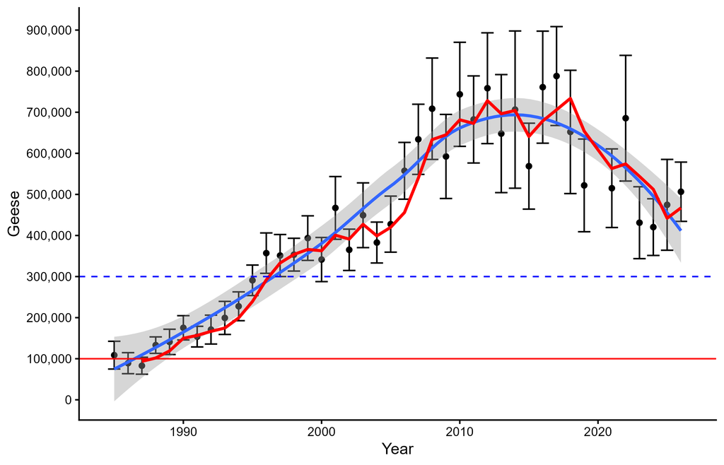

Figure 14: Pacific Population white-fronted goose abundance in fall. Circles are annual estimates of abundance with 95% confidence intervals. The red line is a moving 3-year average and the blue line is a smoothed (Loess model) line with 95% confidence interval (shaded area) fit to the annual estimates. The blue dashed reference line is the Pacific Flyway Council’s population objective. The and the red reference line is the closure threshold.

Time series statistics

| Parameter | Estimate | SE | L95%CI | U95%CI |
| --- | --- | --- | --- | --- |
| 1-year index | 506,491 | 36,800 | 434,363 | 578,619 |
| 3-year index<sup>a</sup> | 467,172 | 43,871 | 381,184 | 553,159 |
| LTA | 437,782 |  |  |  |
| Objective | 300,000 |  |  |  |
| % change from LTA | 16 |  |  |  |
| % change from obj | 56 |  |  |  |
| Mgmt index (n years) | 3 |  |  |  |

<sup>a</sup> 2024, 2025, 2026

**Harvest Strategy**  
Management index: White-fronted geese projected in fall.

Management thresholds:  
>300,000 Standard  
>100,000 Restrictive  
Closed

Management prescription: Standard.

Note that the Restrictive alternative will be prescribed when the most recent moving 3-year average abundance is increasing from below 100,000 to at least 120,000 birds.

Regulatory alternatives:  
Regulations fixed until changed.

Harvest management should promote maintenance of the population goal: a 3-year average projected fall index of 300,000 geese. When the population is above objective, the harvest rate should not exceed 15% of the most recent 3-year average index. If the population index drops below the objective level of 300,000, harvest rate should not exceed 10% of the most recent 3-year average projected fall population index. If the 3-year average population index drops below 100,000 geese, all hunting should be suspended throughout the flyway. After a season closure, the 3-year average abundance must exceed 120,000 birds before harvest may be considered.

### Data Table 13: White-fronted Goose, Tule

Original data source: Cooperative Pacific Flyway Mark-resight Survey in California, Oregon, and Alaska; California and USFWS Pacific Flyway Office. Data maintained by California.

Provided in the table below are abundance (Estimate) and standard error (SE) of Tule white-fronted geese in fall. Also provided are the estimated number of marked (Marks) geese in the population, estimated ratio (Ratio) of marked geese to total geese, and the abundance moving 3-year average (M3yr) and standard error (M3yr.SE).

Table 13. Tule white-fronted goose abundance in fall, 2003-2025.

| Year | Marks | Marks.SE | Ratio | Ratio.SE | Estimate | Estimate.SE | M3yr | M3yr.SE |
| --- | --- | --- | --- | --- | --- | --- | --- | --- |
| 2003 | 47 | 0.0 | 351 | 67.9 | 16,513 | 3,192 | NA | NA |
| 2004 | 58 | 0.0 | 133 | 33.9 | 7,703 | 1,965 | NA | NA |
| 2005 | 52 | 1.5 | 300 | 122.5 | 15,460 | 6,325 | 13,225 | 4,245 |
| 2006 | 81 | 0.0 | 418 | 136.6 | 33,878 | 11,066 | 19,014 | 7,446 |
| 2007 | 88 | 0.5 | 188 | 40.0 | 16,604 | 3,528 | 21,981 | 7,636 |
| 2008 | 75 | 0.6 | 147 | 35.4 | 11,042 | 2,663 | 20,508 | 6,880 |
| 2009 | 53 | 1.0 | 259 | 56.7 | 13,685 | 3,011 | 13,777 | 3,088 |
| 2010 | 58 | 0.0 | 306 | 82.8 | 17,770 | 4,800 | 14,166 | 3,615 |
| 2011 | 53 | 0.5 | 218 | 40.0 | 11,586 | 2,131 | 14,347 | 3,495 |
| 2012 | 59 | 0.8 | 278 | 81.4 | 16,555 | 4,850 | 15,303 | 4,127 |
| 2013 | 50 | 0.0 | 220 | 65.7 | 10,975 | 3,285 | 13,038 | 3,599 |
| 2014 | 56 | 0.4 | 148 | 37.8 | 8,329 | 2,123 | 11,953 | 3,597 |
| 2015 | 59 | 0.3 | 147 | 25.7 | 8,713 | 1,521 | 9,339 | 2,423 |
| 2016 | 56 | 0.0 | 352 | 98.2 | 19,730 | 5,500 | 12,257 | 3,515 |
| 2017 | 60 | 0.5 | 287 | 69.4 | 17,286 | 4,184 | 15,243 | 4,085 |
| 2018 | 45 | 0.3 | 156 | 34.7 | 7,043 | 1,567 | 14,686 | 4,091 |
| 2019 | 54 | 0.5 | 303 | 90.8 | 16,446 | 4,927 | 13,592 | 3,840 |
| 2020 | 30 | 1.6 | 395 | 127.2 | 12,048 | 3,934 | 11,846 | 3,751 |
| 2021 | 25 | 0.6 | 463 | 221.8 | 11,713 | 5,625 | 13,402 | 4,878 |
| 2022 | 33 | 2.0 | 424 | 202.2 | 13,807 | 6,658 | 12,522 | 5,521 |
| 2023 | 39 | 0.0 | 248 | 64.9 | 9,655 | 2,529 | 11,725 | 5,240 |
| 2024 | 26 | 0.0 | 297 | 86.0 | 7,715 | 2,235 | 10,392 | 4,310 |
| 2025 | 32 | 0.2 | 962 | 435.8 | 30,815 | 13,960 | 16,062 | 8,292 |

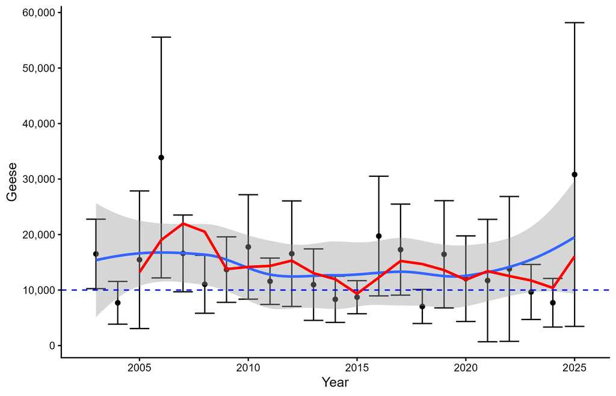

Figure 15: Tule white-fronted goose abundance in fall. Circles are annual estimates of abundance with 95% confidence intervals. The red line is a moving 3-year average and the blue line is a smoothed (Loess model) line with 95% confidence interval (shaded area) fit to the annual estimates. The blue dashed reference line is the Pacific Flyway Council’s minimum population objective.

Time series statistics

| Parameter | Estimate | SE | L95%CI | U95%CI |
| --- | --- | --- | --- | --- |
| 1-year index | 30,815 | 13,960 | 3,453 | 58,177 |
| 3-year index<sup>a</sup> | 16,062 | 8,292 | -191 | 32,314 |
| LTA | 13,830 |  |  |  |
| Objective | 10,000 |  |  |  |
| % change from LTA | 123 |  |  |  |
| % change from obj | 61 |  |  |  |
| Mgmt index (n years) | 3 |  |  |  |

<sup>a</sup> 2023, 2024, 2025

**Harvest Strategy**  
Management index: Total white-fronted geese in fall.

Management thresholds: N/A.

Management prescription: N/A.

Regulatory alternatives:  
Regulations fixed until changed.

### Data Table 14: Trumpeter Swan, PP

Original data source: Waterfowl Breeding Population and Habitat Survey (WBPHS) strata in Alaska (i.e., strata 1–4, 6, and 7); USFWS Alaska Region. Data maintained by the USFWS Alaska Region.

Provided in the table below are abundance and standard error (SE) of Pacific Population trumpeter swans by WBPHS area (strata 1–4, 6, and 7) and in total (Total) in spring. Also provided are the total abundance moving 3-year average (M3yr) and standard error (M3yr.SE).

Table 14. Pacific Population trumpeter swan abundance in spring, 1964-2026.

| Year | WPBHS1 | WPBHS1.SE | WPBHS2 | WPBHS2.SE | WPBHS3 | WPBHS3.SE | WPBHS4 | WPBHS4.SE | WPBHS6 | WPBHS6.SE | WPBHS7 | WPBHS7.SE | Total | Total.SE | M3yr | M3yr.SE |
| --- | --- | --- | --- | --- | --- | --- | --- | --- | --- | --- | --- | --- | --- | --- | --- | --- |
| 1964 | 110 | 120 | 150 | 155 | 465 | 217 | 0 | 0 | 922 | 819 | NA | NA | NA | NA | NA | NA |
| 1965 | 220 | 241 | 375 | 200 | 1,198 | 603 | 154 | 143 | 205 | 121 | NA | NA | NA | NA | NA | NA |
| 1966 | 330 | 179 | 0 | 0 | 845 | 347 | 0 | 0 | 205 | 195 | NA | NA | NA | NA | NA | NA |
| 1967 | 935 | 456 | 1,050 | 380 | 913 | 418 | 0 | 0 | 64 | 69 | NA | NA | NA | NA | NA | NA |
| 1968 | 110 | 108 | 750 | 397 | 493 | 213 | 0 | 0 | 0 | 0 | NA | NA | NA | NA | NA | NA |
| 1969 | 385 | 271 | 150 | 98 | 986 | 302 | 0 | 0 | 102 | 98 | NA | NA | NA | NA | NA | NA |
| 1970 | 440 | 261 | 750 | 404 | 845 | 479 | 0 | 0 | 102 | 70 | NA | NA | NA | NA | NA | NA |
| 1971 | 715 | 235 | 1,875 | 663 | 1,198 | 418 | 0 | 0 | 359 | 207 | NA | NA | NA | NA | NA | NA |
| 1972 | 440 | 314 | 1,125 | 440 | 1,480 | 571 | 0 | 0 | 205 | 121 | NA | NA | NA | NA | NA | NA |
| 1973 | 110 | 54 | 1,200 | 484 | 1,057 | 502 | 0 | 0 | 461 | 294 | NA | NA | NA | NA | NA | NA |
| 1974 | 0 | 0 | 1,050 | 579 | 916 | 303 | 135 | 127 | 256 | 125 | NA | NA | NA | NA | NA | NA |
| 1975 | 330 | 162 | 3,450 | 2,110 | 775 | 453 | 135 | 127 | 666 | 427 | NA | NA | NA | NA | NA | NA |
| 1976 | 220 | 108 | 1,950 | 512 | 1,198 | 459 | 135 | 141 | 359 | 241 | NA | NA | NA | NA | NA | NA |
| 1977 | 330 | 216 | 2,775 | 725 | 1,198 | 529 | 0 | 0 | 410 | 390 | NA | NA | NA | NA | NA | NA |
| 1978 | 330 | 361 | 1,725 | 789 | 2,114 | 699 | 270 | 283 | 410 | 287 | NA | NA | NA | NA | NA | NA |
| 1979 | 330 | 194 | 1,800 | 901 | 2,043 | 706 | 270 | 156 | 615 | 376 | NA | NA | NA | NA | NA | NA |
| 1980 | 220 | 152 | 2,100 | 465 | 2,959 | 844 | 0 | 0 | 1,281 | 743 | NA | NA | NA | NA | NA | NA |
| 1981 | 990 | 766 | 2,850 | 1,614 | 1,550 | 570 | 135 | 141 | 1,076 | 551 | NA | NA | NA | NA | NA | NA |
| 1982 | 440 | 295 | 2,400 | 816 | 3,805 | 1,724 | 0 | 0 | 512 | 317 | NA | NA | NA | NA | NA | NA |
| 1983 | 385 | 189 | 3,225 | 896 | 3,382 | 1,208 | 0 | 0 | 871 | 341 | NA | NA | NA | NA | NA | NA |
| 1984 | 550 | 269 | 4,950 | 2,892 | 2,607 | 738 | 0 | 0 | 410 | 222 | 740 | 178 | 9,257 | 3,010 | NA | NA |
| 1985 | 1,375 | 559 | 3,750 | 1,307 | 4,086 | 1,126 | 0 | 0 | 1,025 | 561 | 840 | 210 | 11,076 | 1,910 | NA | NA |
| 1986 | 385 | 214 | 3,600 | 1,251 | 2,748 | 815 | 0 | 0 | 410 | 150 | 920 | 137 | 8,063 | 1,522 | 9,465 | 2,238 |
| 1987 | 440 | 253 | 6,150 | 3,568 | 4,650 | 1,737 | 270 | 283 | 512 | 138 | 620 | 148 | 12,642 | 3,992 | 10,594 | 2,702 |
| 1988 | 385 | 108 | 4,350 | 1,109 | 4,861 | 1,535 | 135 | 141 | 871 | 250 | 500 | 215 | 11,103 | 1,931 | 10,603 | 2,707 |
| 1989 | 440 | 321 | 5,775 | 2,379 | 3,452 | 1,022 | 405 | 380 | 974 | 456 | 500 | 227 | 11,546 | 2,685 | 11,764 | 2,993 |
| 1990 | 110 | 108 | 4,500 | 1,496 | 6,693 | 2,250 | 0 | 0 | 769 | 382 | 660 | 176 | 12,732 | 2,737 | 11,794 | 2,478 |
| 1991 | 660 | 244 | 4,650 | 1,863 | 3,241 | 1,169 | 675 | 349 | 974 | 425 | 800 | 359 | 11,000 | 2,308 | 11,759 | 2,584 |
| 1992 | 330 | 126 | 4,200 | 621 | 4,368 | 1,129 | 540 | 270 | 410 | 150 | 680 | 193 | 10,528 | 1,346 | 11,420 | 2,208 |
| 1993 | 385 | 143 | 3,225 | 632 | 4,086 | 993 | 675 | 349 | 359 | 197 | 380 | 145 | 9,110 | 1,260 | 10,213 | 1,705 |
| 1994 | 440 | 332 | 3,825 | 961 | 4,086 | 772 | 1,080 | 648 | 359 | 133 | 720 | 320 | 10,510 | 1,473 | 10,049 | 1,362 |
| 1995 | 330 | 216 | 3,450 | 1,203 | 4,509 | 1,021 | 0 | 0 | 666 | 250 | 1,020 | 368 | 9,975 | 1,653 | 9,865 | 1,471 |
| 1996 | 660 | 396 | 4,125 | 886 | 6,552 | 1,555 | 405 | 380 | 974 | 364 | 1,040 | 234 | 13,756 | 1,921 | 11,414 | 1,693 |
| 1997 | 495 | 331 | 5,400 | 1,783 | 3,945 | 1,082 | 270 | 283 | 820 | 228 | 880 | 145 | 11,810 | 2,148 | 11,847 | 1,918 |
| 1998 | 55 | 54 | 4,950 | 1,375 | 6,834 | 1,734 | 0 | 0 | 922 | 390 | 1,020 | 82 | 13,782 | 2,249 | 13,116 | 2,111 |
| 1999 | 385 | 306 | 6,225 | 1,368 | 12,823 | 4,313 | 1,485 | 1,406 | 666 | 255 | 820 | 157 | 22,404 | 4,757 | 15,999 | 3,281 |
| 2000 | 550 | 209 | 4,350 | 1,460 | 11,273 | 5,071 | 10,530 | 8,815 | 2,306 | 742 | 1,260 | 241 | 30,269 | 10,306 | 22,152 | 6,681 |
| 2001 | 385 | 187 | 4,950 | 1,534 | 7,492 | 3,212 | 4,050 | 2,345 | 1,281 | 627 | 1,200 | 552 | 19,358 | 4,347 | 24,010 | 7,018 |
| 2002 | 660 | 205 | 3,375 | 1,004 | 6,905 | 1,747 | 1,215 | 817 | 1,076 | 239 | 1,080 | 335 | 14,311 | 2,223 | 21,313 | 6,584 |
| 2003 | 660 | 137 | 6,225 | 2,721 | 5,214 | 1,584 | 540 | 348 | 820 | 295 | 1,260 | 385 | 14,719 | 3,207 | 16,129 | 3,373 |
| 2004 | 935 | 294 | 3,450 | 1,046 | 5,989 | 1,609 | 540 | 391 | 1,281 | 387 | 1,480 | 382 | 13,675 | 2,054 | 14,235 | 2,546 |
| 2005 | 786 | 563 | 3,450 | 872 | 5,143 | 1,706 | 405 | 297 | 820 | 322 | NA | NA | NA | NA | NA | NA |
| 2006 | 660 | 152 | 8,475 | 5,058 | 6,552 | 2,094 | 1,350 | 573 | 769 | 256 | 1,400 | 379 | 19,206 | 5,525 | 15,867 | 3,874 |
| 2007 | 605 | 367 | 5,400 | 1,366 | 9,159 | 2,945 | 1,485 | 734 | 1,435 | 582 | 660 | 180 | 18,744 | 3,404 | 17,208 | 3,930 |
| 2008 | 550 | 225 | 3,600 | 835 | 8,595 | 2,916 | 1,662 | 722 | 1,281 | 283 | 1,260 | 233 | 16,948 | 3,147 | 18,299 | 4,164 |
| 2009 | 605 | 104 | 3,150 | 1,001 | 8,455 | 2,613 | 810 | 538 | 1,742 | 411 | 620 | 126 | 15,382 | 2,884 | 17,025 | 3,152 |
| 2010 | 550 | 283 | 2,775 | 372 | 8,428 | 3,457 | 945 | 485 | 1,691 | 380 | 740 | 156 | 15,129 | 3,546 | 15,820 | 3,204 |
| 2011 | 1,161 | 412 | 2,925 | 474 | 8,948 | 2,352 | 1,350 | 499 | 1,896 | 497 | 720 | 179 | 17,000 | 2,540 | 15,837 | 3,019 |
| 2012 | 794 | 255 | 4,050 | 723 | 9,159 | 3,076 | 1,215 | 645 | 2,152 | 553 | 1,200 | 406 | 18,571 | 3,307 | 16,900 | 3,161 |
| 2013 | NA | NA | 3,600 | 887 | 8,877 | 2,800 | 1,080 | 590 | NA | NA | 960 | 264 | NA | NA | NA | NA |
| 2014 | 1,039 | 437 | 1,341 | 562 | 6,466 | 1,736 | 3,915 | 1,774 | 1,589 | 451 | 1,420 | 302 | 15,770 | 2,639 | 17,114 | 2,849 |
| 2015 | 244 | 111 | 3,000 | 501 | 7,680 | 1,548 | 1,350 | 698 | 2,358 | 451 | 1,320 | 656 | 15,951 | 1,944 | 16,764 | 2,688 |
| 2016 | 550 | 189 | 2,925 | 387 | 7,116 | 1,904 | 540 | 391 | 1,896 | 525 | 1,000 | 235 | 14,027 | 2,073 | 15,249 | 2,239 |
| 2017 | 794 | 272 | 1,575 | 378 | 9,900 | 3,526 | 810 | 553 | 2,255 | 501 | 980 | 297 | 16,314 | 3,647 | 15,431 | 2,669 |
| 2018 | 733 | 434 | 2,775 | 1,060 | 6,130 | 2,156 | 3,510 | 876 | 1,794 | 404 | 680 | 155 | 15,622 | 2,629 | 15,321 | 2,858 |
| 2019 | 2,383 | 1,758 | 1,950 | 500 | 6,552 | 1,525 | 5,940 | 3,259 | 2,409 | 935 | 820 | 132 | 20,054 | 4,145 | 17,330 | 3,530 |
| 2020 | NA | NA | NA | NA | NA | NA | NA | NA | NA | NA | NA | NA | NA | NA | NA | NA |
| 2021 | 756 | 412 | 2,730 | 1,269 | 5,231 | 1,588 | 1,890 | 1,072 | 2,358 | 1,122 | 1,280 | 271 | 14,245 | 2,605 | 16,640 | 3,208 |
| 2022 | 856 | 460 | 2,550 | 921 | 8,455 | 2,515 | 2,700 | 1,338 | 2,358 | 723 | 960 | 283 | 17,878 | 3,127 | 17,392 | 3,354 |
| 2023 | 428 | 182 | NA | NA | 3,488 | 1,352 | 2,160 | 940 | 1,435 | 504 | 520 | 105 | NA | NA | NA | NA |
| 2024 | 489 | 285 | 2,550 | 904 | 4,086 | 1,155 | 2,314 | 1,352 | 2,665 | 986 | 680 | 101 | 12,785 | 2,246 | 14,969 | 2,684 |
| 2025 | 1,161 | 330 | 1,300 | 624 | 6,539 | 1,988 | 8,640 | 5,776 | 2,358 | 650 | 1,060 | 225 | 21,058 | 6,188 | 17,240 | 4,208 |
| 2026 | 61 | 58 | 3,000 | 924 | 4,650 | 1,244 | 1,485 | 543 | 3,178 | 831 | 980 | 337 | 13,354 | 1,872 | 15,732 | 3,951 |

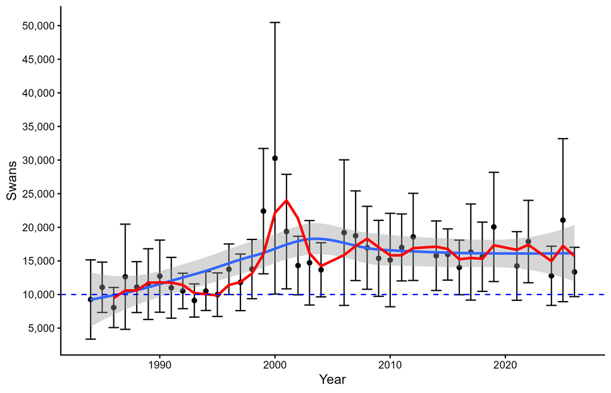

Figure 16: Pacific Population trumpeter swans abundance in spring. Circles are annual estimates of abundance with 95% confidence intervals. The red line is a moving 3-year average and the blue line is a smoothed (Loess model) line with 95% confidence interval (shaded area) fit to the annual estimates. The blue dashed reference line is the Pacific Flyway Council’s minimum population objective.

Time series statistics

| Parameter | Estimate | SE | L95%CI | U95%CI |
| --- | --- | --- | --- | --- |
| 1-year index | 13,354 | 1,872 | 9,685 | 17,022 |
| 3-year index<sup>a</sup> | 15,732 | 3,951 | 7,987 | 23,476 |
| LTA | 14,903 |  |  |  |
| Objective | 10,000 |  |  |  |
| % change from LTA | -10 |  |  |  |
| % change from obj | 57 |  |  |  |
| Mgmt index (n years) | 3 |  |  |  |

<sup>a</sup> 2024, 2025, 2026

**Harvest Strategy**  
Management index: Total trumpeter swans in spring.

Management thresholds: N/A.

Management prescription: N/A.

Regulatory alternatives:  
Regulations fixed until changed.

Note that the Pacific Flyway Council has not yet determined the objective for this population. Early discussions by the Pacific Flyway Study Committee indicate a possible value of 10,000 birds.

### Data Table 15: Trumpeter Swan, RMP Canada Segment

Original data source: Waterfowl Breeding Population and Habitat Survey (WBPHS) strata from central Northwest Territories to southern Alberta (i.e., strata 15, 16, 17, 18, 20, 26, 27, 28, 29, 75, 76, 77). Data maintained by USFWS Headquarters.

Provided in the table below are abundance of breeding Rocky Mountain Population trumpeter swans in spring.

Table 15. Rocky Mountain Population Canada segment trumpeter swans in spring, 2000-2026.

| Year | Estimate | SE | M3yr | M3yr.SE |
| --- | --- | --- | --- | --- |
| 2000 | 2,068 | 1,263 | NA | NA |
| 2001 | 3,082 | 1,528 | NA | NA |
| 2002 | 3,731 | 1,603 | 2,960 | 1,472 |
| 2003 | 4,191 | 1,347 | 3,668 | 1,496 |
| 2004 | 4,641 | 1,903 | 4,188 | 1,634 |
| 2005 | 3,563 | 1,524 | 4,132 | 1,608 |
| 2006 | 4,912 | 1,414 | 4,372 | 1,627 |
| 2007 | 4,075 | 1,343 | 4,183 | 1,429 |
| 2008 | 6,252 | 1,468 | 5,080 | 1,409 |
| 2009 | 3,716 | 1,342 | 4,681 | 1,385 |
| 2010 | 8,937 | 2,249 | 6,302 | 1,733 |
| 2011 | 6,717 | 2,798 | 6,457 | 2,213 |
| 2012 | 8,658 | 2,674 | 8,104 | 2,584 |
| 2013 | 8,246 | 2,190 | 7,873 | 2,567 |
| 2014 | 5,825 | 1,725 | 7,576 | 2,230 |
| 2015 | 5,298 | 1,117 | 6,456 | 1,734 |
| 2016 | 5,461 | 1,443 | 5,528 | 1,450 |
| 2017 | 9,627 | 2,119 | 6,795 | 1,615 |
| 2018 | 8,599 | 2,105 | 7,895 | 1,915 |
| 2019 | 11,439 | 2,390 | 9,888 | 2,209 |
| 2020 | NA | NA | NA | NA |
| 2021 | NA | NA | NA | NA |
| 2022 | 8,906 | 1,633 | 9,648 | 2,066 |
| 2023 | 7,639 | 2,034 | 9,328 | 2,042 |
| 2024 | 8,436 | 2,403 | 8,327 | 2,047 |
| 2025 | 9,320 | 2,317 | 8,465 | 2,257 |
| 2026 | 17,511 | 3,624 | 11,756 | 2,845 |

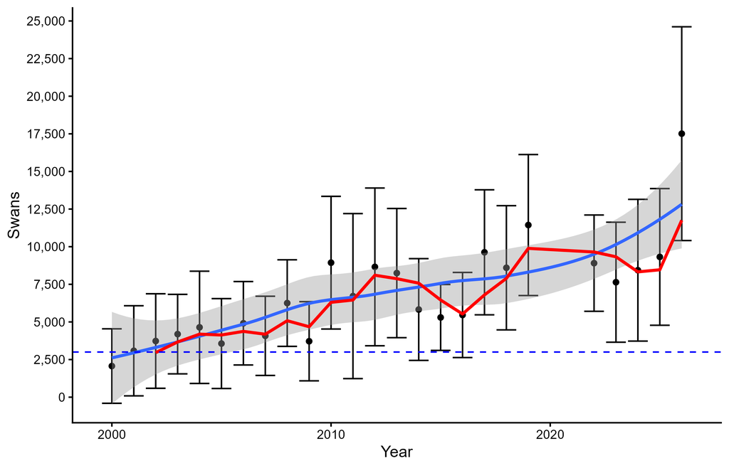

Figure 17: Rocky Mountain Population Canada breeding segment trumpeter swan breeding abundance in spring. Circles are annual estimates of abundance with 95% confidence intervals. The red line is a moving 3-year average and the blue line is a smoothed (Loess model) line with 95% confidence interval (shaded area) fit to the annual estimates. The blue dashed reference line is the Pacific Flyway Council’s population objective (at least 3,000 swans).

Time series statistics

| Parameter | Estimate | SE | L95%CI | U95%CI |
| --- | --- | --- | --- | --- |
| 1-year index | 17,511 | 3,624 | 10,408 | 24,615 |
| 3-year index<sup>a</sup> | 11,756 | 2,845 | 6,180 | 17,331 |
| LTA | 6,389 |  |  |  |
| Objective | 3,000 |  |  |  |
| % change from LTA | 174 |  |  |  |
| % change from obj | 484 |  |  |  |
| Mgmt index (n years) | 1 |  |  |  |

<sup>a</sup> 2024, 2025, 2026

**Harvest Strategy**  
Management index: Breeding trumpeter swans in spring

Management thresholds: N/A.

Management prescription: N/A.

Regulatory alternatives:  
Regulations fixed until changed.

### Data Table 16: Trumpeter Swan, RMP US Segment

Original data source: Cooperative Fall Survey of the Rocky Mountain Population Trumpeter Swan US Segment; USFWS headquarters, USFWS Mountain-Prairie Region, USFWS Pacific Region, Idaho, Montana, Oregon, Tribes, and National Park Service. Data maintained by USFWS Headquarters.

Provided in the table below are abundance of Rocky Mountain Population trumpeter swans by age class and in total (Total) in fall. Age classes include adult and subadult birds (White) and cygnets (Gray). Also provided are the proportion of the total for each age class and the moving 3-year average abundance for adult and subadult swans (WhiteM3yr) and in total (TotalM3yr).

Table 16. Rocky Mountain Population US segment trumpeter swans in fall, 1968-2025.

| Year | White | Gray | Total | White% | Gray% | White.M3yr | Total.M3yr |
| --- | --- | --- | --- | --- | --- | --- | --- |
| 1968 | 369 | 150 | 519 | 71 | 29 | NA | NA |
| 1969 | NA | NA | NA | NA | NA | NA | NA |
| 1970 | NA | NA | NA | NA | NA | NA | NA |
| 1971 | 395 | 67 | 462 | 85 | 15 | NA | NA |
| 1972 | NA | NA | NA | NA | NA | NA | NA |
| 1973 | NA | NA | NA | NA | NA | NA | NA |
| 1974 | 416 | 68 | 484 | 86 | 14 | 393 | 488 |
| 1975 | NA | NA | NA | NA | NA | NA | NA |
| 1976 | NA | NA | NA | NA | NA | NA | NA |
| 1977 | 357 | 84 | 441 | 81 | 19 | 389 | 462 |
| 1978 | NA | NA | NA | NA | NA | NA | NA |
| 1979 | NA | NA | NA | NA | NA | NA | NA |
| 1980 | 419 | 19 | 438 | 96 | 4 | 397 | 454 |
| 1981 | NA | NA | NA | NA | NA | NA | NA |
| 1982 | NA | NA | NA | NA | NA | NA | NA |
| 1983 | 404 | 54 | 458 | 88 | 12 | 393 | 446 |
| 1984 | NA | NA | NA | NA | NA | NA | NA |
| 1985 | 357 | 134 | 491 | 73 | 27 | 393 | 462 |
| 1986 | NA | NA | NA | NA | NA | NA | NA |
| 1987 | 345 | 168 | 513 | 67 | 33 | 369 | 487 |
| 1988 | 454 | 137 | 591 | 77 | 23 | 385 | 532 |
| 1989 | 502 | 60 | 562 | 89 | 11 | 434 | 555 |
| 1990 | 431 | 147 | 578 | 75 | 25 | 462 | 577 |
| 1991 | 456 | 107 | 563 | 81 | 19 | 463 | 568 |
| 1992 | 457 | 96 | 553 | 83 | 17 | 448 | 565 |
| 1993 | 299 | 44 | 343 | 87 | 13 | 404 | 486 |
| 1994 | 300 | 150 | 450 | 67 | 33 | 352 | 449 |
| 1995 | 381 | 72 | 453 | 84 | 16 | 327 | 415 |
| 1996 | 398 | 98 | 496 | 80 | 20 | 360 | 466 |
| 1997 | 349 | 72 | 421 | 83 | 17 | 376 | 457 |
| 1998 | 365 | 105 | 470 | 78 | 22 | 371 | 462 |
| 1999 | 343 | 67 | 410 | 84 | 16 | 352 | 434 |
| 2000 | 371 | 109 | 480 | 77 | 23 | 360 | 453 |
| 2001 | 416 | 71 | 487 | 85 | 15 | 377 | 459 |
| 2002 | 310 | 57 | 367 | 84 | 16 | 366 | 445 |
| 2003 | 323 | 96 | 419 | 77 | 23 | 350 | 424 |
| 2004 | 318 | 99 | 417 | 76 | 24 | 317 | 401 |
| 2005 | 404 | 106 | 510 | 79 | 21 | 348 | 449 |
| 2006 | 411 | 88 | 499 | 82 | 18 | 378 | 475 |
| 2007 | 405 | 115 | 520 | 78 | 22 | 407 | 510 |
| 2008 | 408 | 51 | 459 | 89 | 11 | 408 | 493 |
| 2009 | 400 | 77 | 477 | 84 | 16 | 404 | 485 |
| 2010 | 391 | 107 | 498 | 79 | 21 | 400 | 478 |
| 2011 | 391 | 89 | 480 | 81 | 19 | 394 | 485 |
| 2012 | 410 | 188 | 598 | 69 | 31 | 397 | 525 |
| 2013 | 506 | 135 | 641 | 79 | 21 | 436 | 573 |
| 2014 | 473 | 158 | 631 | 75 | 25 | 463 | 623 |
| 2015 | 713 | 261 | 974 | 73 | 27 | 564 | 749 |
| 2016 | 736 | 217 | 953 | 77 | 23 | 641 | 853 |
| 2017 | 787 | 189 | 976 | 81 | 19 | 745 | 968 |
| 2018 | 786 | 229 | 1,015 | 77 | 23 | 770 | 981 |
| 2019 | 757 | 158 | 915 | 83 | 17 | 777 | 969 |
| 2020 | 822 | 180 | 1,002 | 82 | 18 | 788 | 977 |
| 2021 | 749 | 200 | 949 | 79 | 21 | 776 | 955 |
| 2022 | 701 | 225 | 926 | 76 | 24 | 757 | 959 |
| 2023 | 696 | 263 | 959 | 73 | 27 | 715 | 945 |
| 2024 | 695 | 328 | 1,023 | 68 | 32 | 697 | 969 |
| 2025 | 826 | 231 | 1,057 | 78 | 22 | 739 | 1,013 |

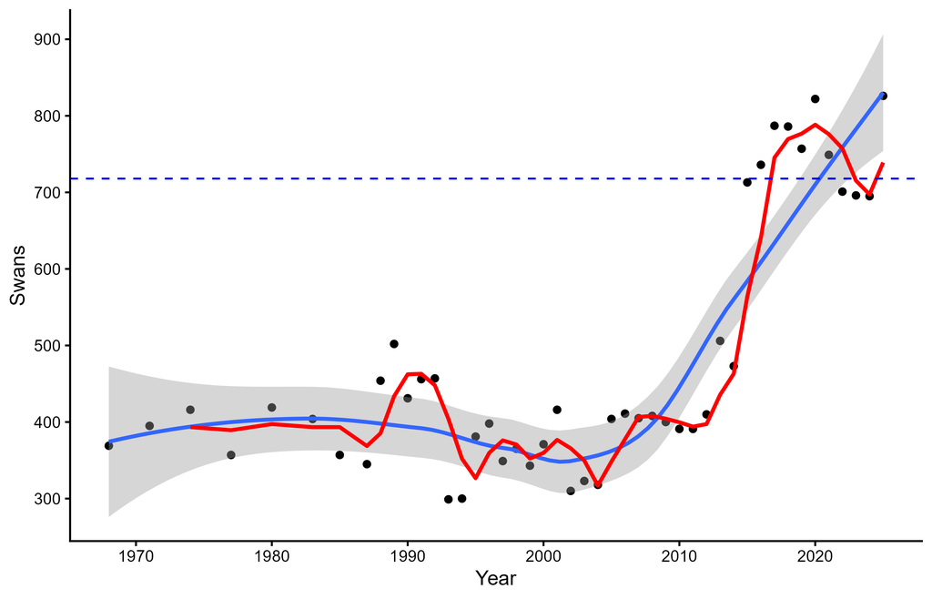

Figure 18: Rocky Mountain Population US breeding segment trumpeter swan white bird (subadult and adult) abundance in fall. Circles are annual estimates of abundance. The red line is a moving 3-year average and the blue line is a smoothed (Loess model) line with 95% confidence interval (shaded area) fit to the annual estimates. The blue dashed reference line is the Pacific Flyway Council’s population objective.

Time series statistics

| Parameter | Estimate | SE | L95%CI | U95%CI |
| --- | --- | --- | --- | --- |
| 1-year index | 826 |  |  |  |
| 3-year index<sup>a</sup> | 739 |  |  |  |
| LTA | 471 |  |  |  |
| Objective | 718 |  |  |  |
| % change from LTA | 76 |  |  |  |
| % change from obj | 15 |  |  |  |
| Mgmt index (n years) | 1 |  |  |  |

<sup>a</sup> 2023, 2024, 2025

**Harvest Strategy**  
Management index: Total white (adult and subadult) trumpeter swans in fall.

Management thresholds: N/A.

Management prescription: N/A.

Regulatory alternatives:  
Regulations fixed until changed.

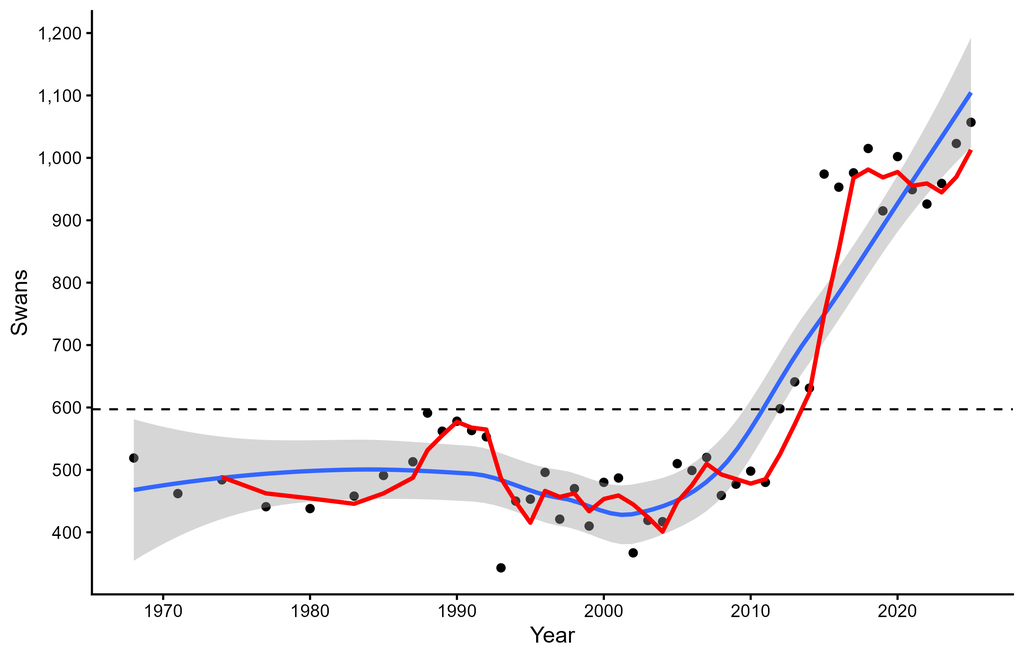

Figure 19: Rocky Mountain Population US breeding segment trumpeter swan total abundance in fall. Circles are annual estimates of abundance. The red line is a moving 3-year average and the blue line is a smoothed (Loess model) line with 95% confidence interval (shaded area) fit to the annual estimates. The black dashed reference line is the long-term average abundance.

### Data Table 17: Tundra Swan, EP

Original data source: Cooperative State-Federal Midwinter Waterfowl Survey in the U.S. Mississippi Flyway; U.S. Atlantic Flyway; and Ontario, Canada. Data maintained by USFWS Atlantic Flyway Office.

Provided in the table below are abundance of Eastern population tundra swans in winter by area including the U.S. Mississippi Flyway (MF), U.S. Atlantic Flyway (AF), Ontario (ON), and in total (Total). Also provided is the total abundance moving 3-year average (M3yr). So long as there are counts in the U.S. Mississippi and Atlantic flyways and Ontario, the total winter count is interpreted as the minimum known population size with no variance.

Table 17. Eastern Population tundra swan abundance in winter, 1982-2026.

| Year | AF | MF | ON | Total | M3yr |
| --- | --- | --- | --- | --- | --- |
| 1982 | 72,907 | 275 | 0 | 73,182 | NA |
| 1983 | 86,464 | 550 | 500 | 87,514 | NA |
| 1984 | 81,235 | 25 | 100 | 81,360 | 80,685 |
| 1985 | 93,909 | 525 | 2,500 | 96,934 | 88,603 |
| 1986 | 90,766 | 150 | 25 | 90,941 | 89,745 |
| 1987 | 94,504 | 250 | 1,000 | 95,754 | 94,543 |
| 1988 | 77,110 | 375 | 1,200 | 78,685 | 88,460 |
| 1989 | 91,150 | 125 | 25 | 91,300 | 88,580 |
| 1990 | 90,593 | 17 | 9 | 90,619 | 86,868 |
| 1991 | 97,424 | 20 | 754 | 98,198 | 93,372 |
| 1992 | 109,788 | 327 | 2,929 | 113,044 | 100,620 |
| 1993 | 76,593 | 858 | 739 | 78,190 | 96,477 |
| 1994 | 84,527 | 61 | 184 | 84,772 | 92,002 |
| 1995 | 80,222 | 2,447 | 2,473 | 85,142 | 82,701 |
| 1996 | 79,021 | 393 | 113 | 79,527 | 83,147 |
| 1997 | 86,120 | 233 | 6,027 | 92,380 | 85,683 |
| 1998 | 96,544 | 1,335 | 2,679 | 100,558 | 90,822 |
| 1999 | 109,041 | 1,618 | 296 | 110,955 | 101,298 |
| 2000 | 103,082 | 3,364 | 8,897 | 115,343 | 108,952 |
| 2001 | 98,143 | 46 | 231 | 98,420 | 108,239 |
| 2002 | 103,827 | 3,661 | 7,169 | 114,657 | 109,473 |
| 2003 | 108,187 | 2,160 | 1,379 | 111,726 | 108,268 |
| 2004 | 94,975 | 2,094 | 13,737 | 110,806 | 112,396 |
| 2005 | 68,735 | 1,054 | 2,668 | 72,457 | 98,330 |
| 2006 | 70,452 | 1,069 | 9,746 | 81,267 | 88,177 |
| 2007 | 87,840 | 10,521 | 16,057 | 114,418 | 89,381 |
| 2008 | 88,502 | 1,826 | 5,917 | 96,245 | 97,310 |
| 2009 | 99,304 | 552 | 336 | 100,192 | 103,618 |
| 2010 | 91,909 | 1,302 | 4,081 | 97,292 | 97,910 |
| 2011 | 93,767 | 2,427 | 1,445 | 97,639 | 98,374 |
| 2012 | 86,793 | 12,436 | 13,512 | 112,741 | 102,557 |
| 2013 | 98,493 | 1,035 | 7,527 | 107,055 | 105,812 |
| 2014 | 103,844 | 848 | 287 | 104,979 | 108,258 |
| 2015 | 107,936 | 2,964 | 6,196 | 117,096 | 109,710 |
| 2016 | 86,619 | 12,982 | 13,992 | 113,593 | 111,889 |
| 2017 | 115,425 | 1,909 | 1,953 | 119,287 | 116,659 |
| 2018 | 111,077 | 431 | 61 | 111,569 | 114,816 |
| 2019 | 72,365 | 733 | 19,721 | 92,819 | 107,892 |
| 2020 | 61,354 | 9,241 | 7,991 | 78,586 | 94,325 |
| 2021 | 76,701 | 1,677 | 8,302 | 86,680 | 86,028 |
| 2022 | 89,142 | 1,717 | 4,871 | 95,730 | 86,999 |
| 2023 | 113,420 | 4,806 | 19,555 | 137,781 | 106,730 |
| 2024 | 48,678 | 6,986 | 8,773 | 64,437 | 99,316 |
| 2025 | 66,510 | 1,451 | 8,067 | 76,028 | 92,749 |
| 2026 | 92,069 | 238 | 2,786 | 95,093 | 78,519 |

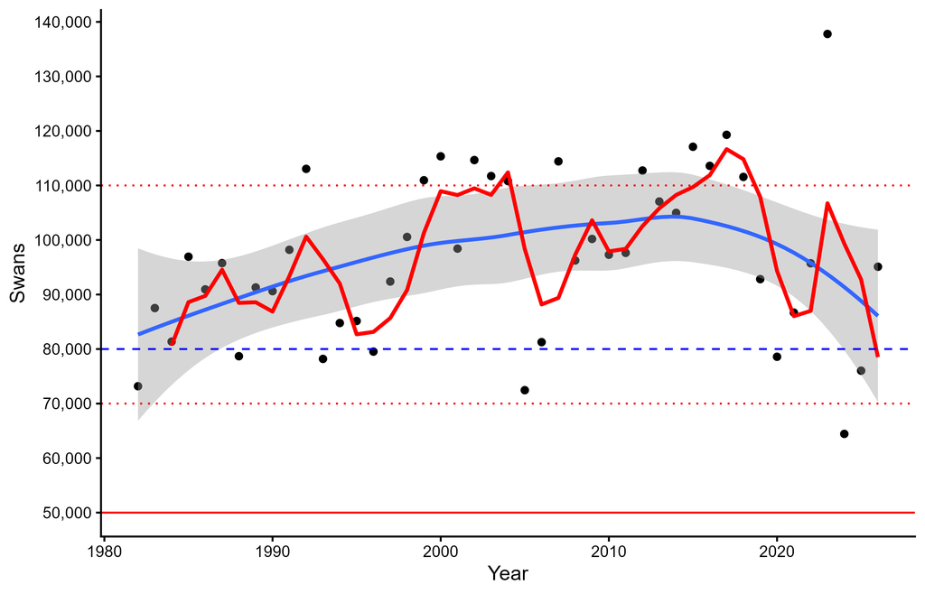

Figure 20: Eastern Population tundra swan abundance in winter. Circles are annual estimates of abundance with 95% confidence intervals. The red line is a moving 3-year average and the blue line is a smoothed (Loess model) line with 95% confidence interval (shaded area) fit to the annual counts. The blue dashed reference line is the Councils’ population objective. The red dashed reference lines represent threshold values in the harvest strategy decision and the red reference line is the closure threshold.

Time series statistics

| Parameter | Estimate | SE | L95%CI | U95%CI |
| --- | --- | --- | --- | --- |
| 1-year index | 95,093 |  |  |  |
| 3-year index<sup>a</sup> | 78,519 |  |  |  |
| LTA | 96,770 |  |  |  |
| Objective | 80,000 |  |  |  |
| % change from LTA | -2 |  |  |  |
| % change from obj | -2 |  |  |  |
| Mgmt index (n years) | 3 |  |  |  |

<sup>a</sup> 2024, 2025, 2026

**Harvest Strategy**  
Management index: Total tundra swans in winter.

Management thresholds:  
>110,000 Liberal  
>70,000 Moderate  
>50,000 Restrictive  
Closed

Management prescription: Moderate.

Regulatory alternatives:  
The permit allocation in the Atlantic Flyway and Central Flyway combined will be:  
Liberal  
12,000 permits  
Moderate  
9,600 permits  
Restrictive  
7,200 permits  
Closed

The regulatory alternative for total permits for the Atlantic and Central Flyways combined is prescribed based on the estimated winter population size from monitoring data. The analytical framework derives a recent 3-year average population size estimate and is compared to threshold values in a decision-analysis framework for prescribing the appropriate regulatory alternative. The recent 3-year average population size estimate must exceed the threshold value to change regulations, either more restrictive or liberal. The season is closed when the recent 3-year average winter population estimate is ≤50,000 swans and will remain closed until the estimate is ≥70,000 swans. A restrictive alternative is prescribed when the estimate is >50,000 and ≤70,000 swans and will remain restrictive until the estimate is ≥80,000 swans. A moderate alternative is prescribed when the estimate is >70,000 and ≤110,000 swans. A liberal alternative is prescribed when the estimate is >110,000 swans. Allocation of permits among States must be approved by the Atlantic and Central Flyway Councils and consistent with the Councils’ management plan for this population.

### Data Table 18: Tundra Swan, WP

Original data source: Yukon Kuskokwim Delta Coastal Zone Survey and Waterfowl Breeding Population and Habitat Survey (WBPHS) strata in Alaska (i.e., strata 8–11); USFWS Alaska Region. Data maintained by USFWS Alaska Region.

Provided in the table below are abundance and standard error (SE) of Western Population tundra swans in spring by survey area including Yukon Kuskokwim Delta Coastal Zone Survey (YKDCZ), WBPHS (strata 8–11), and in total (Total). Also provided are the total abundance moving 3-year average (M3yr) and standard error (M3yr.SE).

Table 18. Western Population tundra swan abundance in spring, 1985-2026.

| Year | YKDCZ | YKDCZ.SE | WPBHS8 | WPBHS8.SE | WPBHS9 | WPBHS9.SE | WPBHS10 | WPBHS10.SE | WPBHS11 | WPBHS11.SE | Total | Total.SE | M3yr | M3yr.SE |
| --- | --- | --- | --- | --- | --- | --- | --- | --- | --- | --- | --- | --- | --- | --- |
| 1985 | 25,028 | 2,558 | 18,509 | 8,250 | 38,639 | 7,373 | 8,388 | 6,631 | 4,235 | 1,304 | 94,799 | 13,215 | NA | NA |
| 1986 | 21,844 | 2,023 | 11,837 | 2,690 | 28,690 | 3,262 | 4,538 | 2,230 | 3,901 | 1,640 | 70,809 | 5,443 | NA | NA |
| 1987 | 20,693 | 2,976 | 17,863 | 7,932 | 31,298 | 6,747 | 3,162 | 876 | 3,901 | 925 | 76,918 | 10,905 | 80,842 | 10,379 |
| 1988 | 23,057 | 2,747 | 9,470 | 1,722 | 44,725 | 13,356 | 3,162 | 1,243 | 2,564 | 1,004 | 82,977 | 13,836 | 76,901 | 10,646 |
| 1989 | 32,517 | 6,596 | 34,004 | 14,213 | 25,792 | 2,457 | 9,762 | 7,974 | 6,019 | 1,073 | 108,095 | 17,784 | 89,330 | 14,453 |
| 1990 | 26,567 | 4,216 | 9,685 | 2,059 | 44,338 | 6,999 | 7,288 | 5,140 | 23,518 | 17,544 | 111,396 | 20,130 | 100,822 | 17,445 |
| 1991 | 17,692 | 1,936 | 15,388 | 2,754 | 31,008 | 3,728 | 14,575 | 13,127 | 6,130 | 1,488 | 84,793 | 14,134 | 101,428 | 17,524 |
| 1992 | 18,150 | 1,951 | 15,603 | 3,133 | 28,303 | 2,437 | 4,538 | 419 | 5,684 | 1,683 | 72,278 | 4,751 | 89,489 | 14,463 |
| 1993 | 19,375 | 1,535 | 10,223 | 2,195 | 40,281 | 12,709 | 4,400 | 795 | 5,127 | 1,344 | 79,406 | 13,082 | 78,826 | 11,452 |
| 1994 | 18,274 | 1,315 | 10,115 | 2,461 | 46,367 | 6,427 | 3,988 | 2,342 | 4,793 | 1,652 | 83,536 | 7,570 | 78,407 | 9,147 |
| 1995 | 21,934 | 1,859 | 20,230 | 9,937 | 67,425 | 32,418 | 5,362 | 2,313 | 4,458 | 1,226 | 119,410 | 34,058 | 94,118 | 21,513 |
| 1996 | 22,418 | 1,452 | 13,666 | 2,730 | 61,243 | 18,793 | 6,462 | 1,510 | 6,130 | 1,664 | 109,921 | 19,178 | 104,289 | 22,986 |
| 1997 | 27,594 | 3,180 | 13,128 | 3,858 | 52,549 | 6,482 | 7,700 | 3,368 | 13,152 | 6,343 | 114,123 | 10,891 | 114,485 | 23,426 |
| 1998 | 42,255 | 4,576 | 13,882 | 3,453 | 53,225 | 6,888 | 8,662 | 6,096 | 17,722 | 8,298 | 135,746 | 13,650 | 119,930 | 14,975 |
| 1999 | 23,709 | 1,400 | 14,635 | 3,995 | 52,282 | 11,168 | 8,112 | 3,747 | 8,471 | 2,325 | 107,209 | 12,732 | 119,026 | 12,477 |
| 2000 | 26,244 | 2,880 | 16,357 | 3,827 | 48,615 | 9,665 | 7,288 | 2,811 | 10,143 | 4,606 | 108,646 | 12,061 | 117,200 | 12,831 |
| 2001 | 21,548 | 1,707 | 14,420 | 4,443 | 39,588 | 3,118 | 10,175 | 5,533 | 7,914 | 2,166 | 93,644 | 8,227 | 103,166 | 11,184 |
| 2002 | 28,999 | 4,080 | 17,755 | 6,158 | 49,931 | 11,949 | 8,112 | 2,516 | 11,926 | 4,277 | 116,724 | 14,899 | 106,338 | 12,043 |
| 2003 | 21,994 | 2,295 | 14,850 | 2,025 | 41,938 | 5,492 | 8,250 | 4,111 | 8,582 | 2,278 | 95,614 | 7,850 | 101,994 | 10,821 |
| 2004 | 25,360 | 2,242 | 13,236 | 4,315 | 51,718 | 18,588 | 8,800 | 3,709 | 11,703 | 4,660 | 110,817 | 20,116 | 107,718 | 15,146 |
| 2005 | 23,361 | 2,532 | 24,104 | 12,840 | 63,002 | 16,405 | 5,500 | 1,495 | 6,688 | 1,532 | 122,654 | 21,094 | 109,695 | 17,428 |
| 2006 | 30,880 | 2,552 | 17,755 | 4,513 | 62,531 | 11,460 | 4,125 | 1,044 | 8,694 | 2,786 | 123,985 | 12,925 | 119,152 | 18,409 |
| 2007 | 29,457 | 3,576 | 15,926 | 8,706 | 80,115 | 19,499 | 11,825 | 1,269 | 17,388 | 4,377 | 154,711 | 22,126 | 133,784 | 19,163 |
| 2008 | 31,597 | 3,396 | 12,805 | 4,762 | 87,268 | 27,624 | 7,150 | 3,181 | 35,778 | 16,039 | 174,598 | 32,629 | 151,098 | 23,953 |
| 2009 | 26,494 | 2,583 | 13,451 | 5,407 | 46,922 | 3,030 | 7,838 | 2,954 | 12,260 | 2,550 | 106,965 | 7,767 | 145,425 | 23,199 |
| 2010 | 36,408 | 4,446 | 8,286 | 1,527 | 44,853 | 3,993 | 10,725 | 6,359 | 9,920 | 1,715 | 110,192 | 9,023 | 130,585 | 20,053 |
| 2011 | 28,846 | 2,734 | 15,280 | 5,950 | 54,727 | 14,286 | 8,800 | 2,877 | 11,703 | 3,368 | 119,356 | 16,327 | 112,171 | 11,667 |
| 2012 | 38,902 | 5,582 | 10,223 | 851 | 48,709 | 6,999 | 7,425 | 2,583 | 9,697 | 1,324 | 114,955 | 9,449 | 114,834 | 12,073 |
| 2013 | 18,879 | 1,692 | 21,091 | 14,798 | 46,264 | 8,361 | 9,212 | 2,811 | 14,155 | 3,321 | 109,602 | 17,626 | 114,638 | 14,906 |
| 2014 | 26,133 | 4,020 | 12,267 | 3,097 | 43,819 | 7,785 | 6,188 | 3,121 | 8,471 | 3,116 | 96,877 | 10,287 | 107,145 | 12,985 |
| 2015 | 18,953 | 3,191 | 13,882 | 2,597 | 60,400 | 16,883 | 7,379 | 3,338 | 24,744 | 13,327 | 125,357 | 22,152 | 110,612 | 17,390 |
| 2016 | 29,918 | 4,511 | 8,071 | 1,571 | 77,388 | 45,172 | 6,738 | 1,945 | 11,146 | 3,471 | 133,261 | 45,598 | 118,498 | 29,865 |
| 2017 | 27,133 | 4,142 | 9,225 | 3,025 | 39,186 | 5,270 | 22,825 | 12,749 | 9,028 | 2,001 | 107,398 | 14,853 | 122,005 | 30,499 |
| 2018 | 32,531 | 4,531 | 12,698 | 4,524 | 87,262 | 24,870 | 4,675 | 2,478 | 14,824 | 5,142 | 151,990 | 26,308 | 130,883 | 31,580 |
| 2019 | 34,669 | 4,633 | 7,425 | 1,643 | 43,819 | 10,141 | 5,362 | 3,112 | 9,808 | 2,089 | 101,084 | 11,877 | 120,157 | 18,742 |
| 2020 | NA | NA | NA | NA | NA | NA | NA | NA | NA | NA | NA | NA | NA | NA |
| 2021 | 31,018 | 2,683 | 13,559 | 8,110 | 45,700 | 8,149 | 7,379 | 6,518 | 21,846 | 11,630 | 119,501 | 17,808 | 124,192 | 19,581 |
| 2022 | 27,423 | 3,150 | 11,837 | 3,123 | 38,177 | 4,378 | 7,700 | 4,260 | 15,158 | 7,539 | 100,295 | 10,669 | 106,960 | 13,808 |
| 2023 | 16,443 | 952 | 7,748 | 1,671 | 33,099 | 7,442 | 4,400 | 3,186 | 10,700 | 3,506 | 72,390 | 9,029 | 97,396 | 13,070 |
| 2024 | 19,266 | 1,085 | 6,513 | 2,400 | 31,219 | 5,841 | 3,850 | 635 | 12,889 | 3,543 | 73,736 | 7,349 | 82,141 | 9,117 |
| 2025 | 20,608 | 1,923 | 12,698 | 5,503 | 20,499 | 3,305 | 4,400 | 2,707 | 14,712 | 11,785 | 72,917 | 13,824 | 73,015 | 10,435 |
| 2026 | 22,043 | 2,093 | 6,457 | 1,791 | 25,201 | 3,946 | 4,973 | 1,165 | 16,830 | 11,215 | 75,503 | 12,259 | 74,052 | 11,481 |

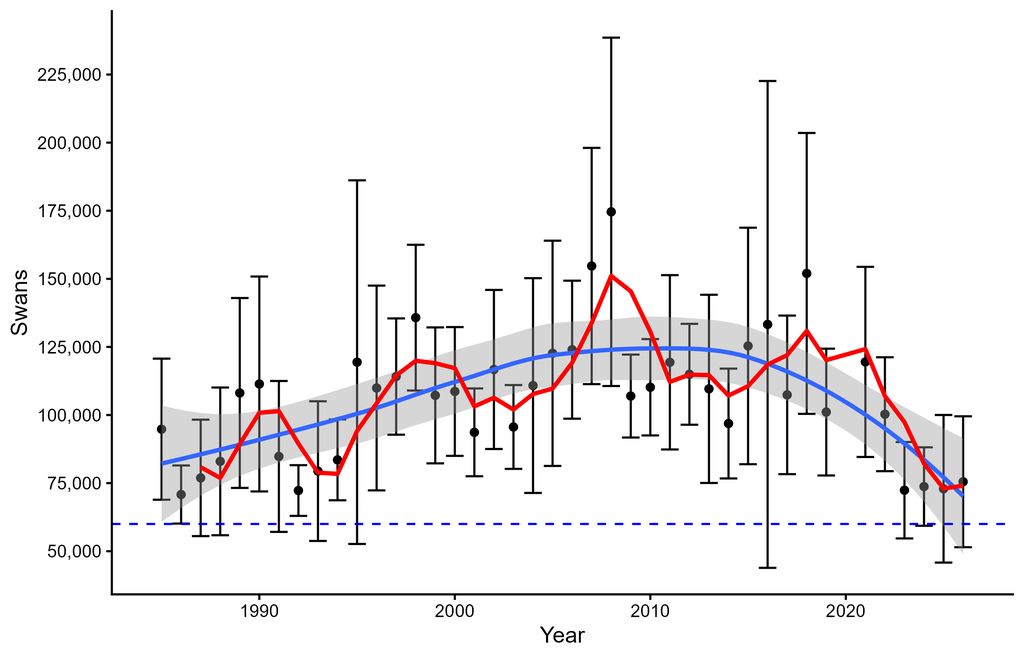

Figure 21: Western Population tundra swan abundance in spring. Circles are annual estimates of abundance with 95% confidence intervals. The red line is a moving 3-year average and the blue line is a smoothed (Loess model) line with 95% confidence interval (shaded area) fit to the annual estimates. The blue dashed reference line is the Pacific Flyway Council’s minimum population objective.

Time series statistics

| Parameter | Estimate | SE | L95%CI | U95%CI |
| --- | --- | --- | --- | --- |
| 1-year index | 75,503 | 12,259 | 51,475 | 99,532 |
| 3-year index<sup>a</sup> | 74,052 | 11,481 | 51,550 | 96,554 |
| LTA | 106,717 |  |  |  |
| Objective | 60,000 |  |  |  |
| % change from LTA | -29 |  |  |  |
| % change from obj | 23 |  |  |  |
| Mgmt index (n years) | 3 |  |  |  |

<sup>a</sup> 2024, 2025, 2026

**Harvest Strategy**  
Management index: Total tundra swans in spring.

Management thresholds:  
≥60,000 Standard  
Restrictive

Management prescription: Standard.

Regulatory alternatives:  
Regulations fixed until changed.

### Data Table 19: Sandhill Crane, MP

Original data source: Photo-corrected annual spring survey along the Platte River of Nebraska; USFWS Headquarters. Data maintained by USFWS Headquarters.

Provided in the table below are abundance (Estimate) and standard error (SE) of Midcontinent Population sandhill cranes in spring. Also provided are the abundance moving 3-year average (M3yr) and standard error (M3yr.SE).

Table 19. U.S. Midcontinent Population sandhill crane abundance in spring, 1982-2026.

| Year | Estimate | SE | M3yr | M3yr.SE |
| --- | --- | --- | --- | --- |
| 1982 | 417,263 | 42,331 | NA | NA |
| 1983 | 343,378 | 31,674 | NA | NA |
| 1984 | 261,802 | 24,198 | 340,814 | 33,569 |
| 1985 | 514,763 | 49,650 | 373,314 | 36,760 |
| 1986 | 353,040 | 37,340 | 376,535 | 38,492 |
| 1987 | 416,058 | 65,588 | 427,954 | 52,157 |
| 1988 | 463,457 | 53,213 | 410,852 | 53,316 |
| 1989 | 391,995 | 51,349 | 423,837 | 57,068 |
| 1990 | 412,154 | 50,496 | 422,535 | 51,698 |
| 1991 | 340,645 | 33,897 | 381,598 | 45,955 |
| 1992 | 406,457 | 50,644 | 386,419 | 45,693 |
| 1993 | 378,883 | 50,454 | 375,328 | 45,678 |
| 1994 | 477,215 | 50,910 | 420,852 | 50,670 |
| 1995 | 326,181 | 35,256 | 394,093 | 46,117 |
| 1996 | 519,984 | 62,582 | 441,127 | 50,831 |
| 1997 | 534,630 | 86,889 | 460,265 | 65,088 |
| 1998 | 530,848 | 79,164 | 528,487 | 76,883 |
| 1999 | 284,858 | 35,599 | 450,112 | 70,908 |
| 2000 | 490,118 | 71,754 | 435,275 | 65,020 |
| 2001 | 413,498 | 64,221 | 396,158 | 59,274 |
| 2002 | 315,044 | 42,218 | 406,220 | 60,705 |
| 2003 | 348,023 | 41,263 | 358,855 | 50,363 |
| 2004 | 426,534 | 43,337 | 363,200 | 42,281 |
| 2005 | 491,915 | 47,392 | 422,157 | 44,071 |
| 2006 | 216,810 | 18,054 | 378,420 | 38,514 |
| 2007 | 384,118 | 39,637 | 364,281 | 37,162 |
| 2008 | 545,884 | 76,107 | 382,271 | 50,627 |
| 2009 | 565,257 | 50,923 | 498,420 | 57,609 |
| 2010 | 691,534 | 85,236 | 600,892 | 72,228 |
| 2011 | 482,797 | 44,851 | 579,863 | 62,902 |
| 2012 | 339,642 | 31,609 | 504,658 | 58,526 |
| 2013 | 867,061 | 126,196 | 563,167 | 79,448 |
| 2014 | 617,903 | 60,551 | 608,202 | 82,847 |
| 2015 | 386,471 | 49,504 | 623,812 | 85,718 |
| 2016 | 405,716 | 44,935 | 470,030 | 52,078 |
| 2017 | 568,369 | 72,987 | 453,519 | 57,146 |
| 2018 | 1,005,612 | 105,654 | 659,899 | 78,547 |
| 2019 | 945,996 | 133,127 | 839,992 | 106,791 |
| 2020 | NA | NA | NA | NA |
| 2021 | 782,462 | 309,357 | 911,357 | 203,787 |
| 2022 | 685,476 | 85,473 | 804,645 | 200,608 |
| 2023 | 1,259,199 | 159,840 | 909,046 | 207,007 |
| 2024 | 420,840 | 66,572 | 788,505 | 111,484 |
| 2025 | 1,005,573 | 148,568 | 895,204 | 131,723 |
| 2026 | 527,440 | 55,561 | 651,284 | 99,317 |

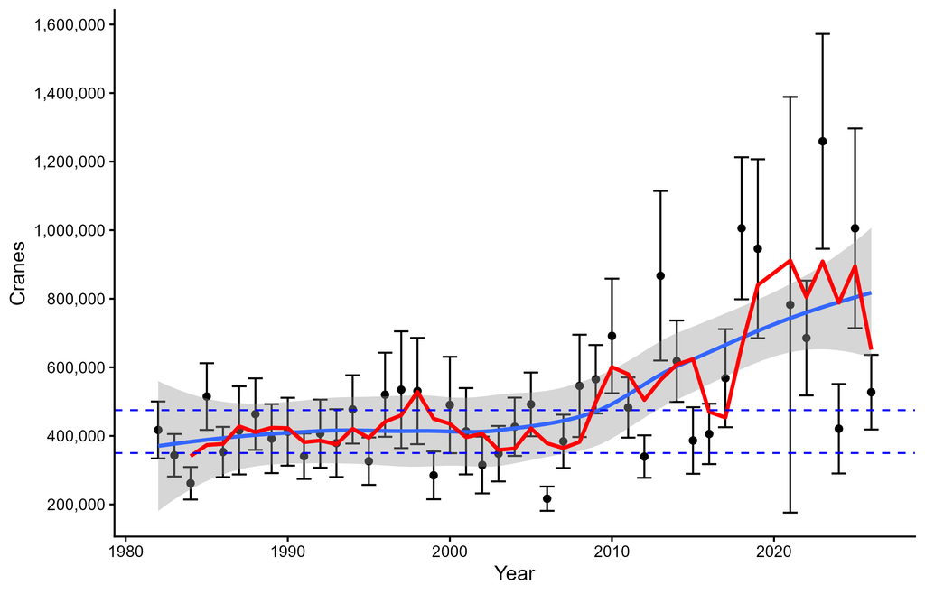

Figure 22: Midcontinent Population sandhill crane abundance in spring. Circles are annual estimates of abundance with 95% confidence intervals. The red line is a moving 3-year average and the blue line is a smoothed (Loess model) line with 95% confidence interval (shaded area) fit to the annual estimates. The blue dashed reference lines represent the Pacific Flyway Council’s population objective range.

Time series statistics

| Parameter | Estimate | SE | L95%CI | U95%CI |
| --- | --- | --- | --- | --- |
| 1-year index | 527,440 | 55,561 | 418,540 | 636,340 |
| 3-year index<sup>a</sup> | 651,284 | 99,317 | 456,624 | 845,945 |
| LTA | 512,453 |  |  |  |
| Objective | 412,500 |  |  |  |
| % change from LTA | 3 |  |  |  |
| % change from obj | 58 |  |  |  |
| Mgmt index (n years) | 3 |  |  |  |

<sup>a</sup> 2024, 2025, 2026

**Harvest Strategy**  
Management index: Sandhill cranes in spring.

Management thresholds: N/A.

Management prescription: N/A.

Regulatory alternatives:  
Regulations fixed until changed.

### Data Table 20: Sandhill Crane, RMP

Original data source: Rocky Mountain Population (RMP) Sandhill Cranes Fall (September) Staging Area Survey and RMP Cranes Fall (October) Recruitment Survey; USFWS Headquarters and USFWS Southwest Region. Data maintained by USFWS Headquarters, USFWS Southwest Region, and USFWS Pacific Flyway Office.

Provided in the table below are abundance of Rocky Mountain Population sandhill cranes in fall by state (Idaho, Montana, Wyoming, Utah, and Colorado) and in total (Total) and the age ratio (AgeRatio) of juvenile to adult (% juveniles in the population) sandhill cranes in fall. Also provided are the moving 3-year average total abundance (M3yrTotal) and age ratio (M3yrRatio). Additionally provided is allowable harvest (Allowable) based on the Pacific and Central Flyway Councils’ harvest strategy. The current year allowable harvest by state is provided in a subsequent table below.

Table 20. Rocky Mountain Population sandhill crane abundance in fall, 1987-2025.

| Year | ID | MT | WY | UT | CO | Total | M3yrTotal | AgeRatio | M3yrRatio | Allowable |
| --- | --- | --- | --- | --- | --- | --- | --- | --- | --- | --- |
| 1987 | 10,686 | 1,447 | 2,327 | 1,578 | 1,443 | 17,481 | NA | 5.40 | 6.73 | NA |
| 1988 | NA | NA | NA | NA | NA | NA | NA | NA | NA | NA |
| 1989 | NA | NA | NA | NA | NA | NA | NA | NA | NA | NA |
| 1990 | NA | NA | NA | NA | NA | NA | NA | NA | NA | NA |
| 1991 | NA | NA | NA | NA | NA | NA | NA | NA | NA | NA |
| 1992 | 5,801 | 5,264 | 2,248 | 2,810 | 3,181 | 19,304 | NA | 5.20 | 5.67 | NA |
| 1993 | NA | NA | NA | NA | NA | NA | NA | NA | NA | NA |
| 1994 | NA | NA | NA | NA | NA | NA | NA | NA | NA | NA |
| 1995 | 6,864 | 3,681 | 1,671 | 1,528 | 2,284 | 16,028 | 17,604 | 6.40 | 5.47 | 513 |
| 1996 | 8,334 | 2,974 | 2,526 | 1,849 | 1,255 | 16,938 | 17,423 | 9.40 | 6.57 | 591 |
| 1997 | 8,132 | 3,595 | 2,255 | 2,450 | 1,604 | 18,036 | 17,001 | 9.70 | 8.50 | 693 |
| 1998 | 8,067 | 3,415 | 3,162 | 2,185 | 1,273 | 18,102 | 17,692 | 11.20 | 10.10 | 966 |
| 1999 | 8,761 | 3,141 | 4,205 | 2,292 | 1,102 | 19,501 | 18,546 | 8.40 | 9.77 | 1,128 |
| 2000 | 9,337 | 3,598 | 3,890 | 2,416 | 749 | 19,990 | 19,198 | 6.70 | 8.77 | 1,163 |
| 2001 | 7,160 | 4,585 | 2,626 | 1,522 | 666 | 16,559 | 18,683 | 5.80 | 6.97 | 829 |
| 2002 | 7,698 | 4,843 | 3,038 | 1,869 | 1,355 | 18,803 | 18,451 | 5.20 | 5.90 | 668 |
| 2003 | 7,822 | 4,964 | 3,446 | 2,546 | 745 | 19,523 | 18,295 | 7.10 | 6.03 | 660 |
| 2004 | 7,152 | 4,637 | 3,072 | 2,239 | 1,410 | 18,510 | 18,945 | 9.40 | 7.23 | 910 |
| 2005 | 7,668 | 5,588 | 3,911 | 2,646 | 1,052 | 20,865 | 19,633 | 10.80 | 9.10 | 1,320 |
| 2006 | NA | NA | NA | NA | NA | NA | NA | NA | NA | NA |
| 2007 | 8,262 | 6,509 | 3,907 | 2,401 | 1,743 | 22,822 | 20,732 | 8.30 | 9.67 | 1,744 |
| 2008 | 6,123 | 6,419 | 3,826 | 3,708 | 1,080 | 21,156 | 21,614 | 9.10 | 9.10 | 1,940 |
| 2009 | 6,934 | 6,329 | 3,613 | 2,283 | 1,162 | 20,321 | 21,433 | 11.50 | 9.63 | 1,985 |
| 2010 | 5,776 | 7,335 | 3,726 | 3,242 | 985 | 21,064 | 20,847 | 8.35 | 9.65 | 1,780 |
| 2011 | 5,029 | 6,642 | 2,978 | 1,498 | 1,347 | 17,494 | 19,626 | 6.55 | 8.80 | 1,275 |
| 2012 | 3,432 | 5,876 | 3,587 | 2,109 | 413 | 15,417 | 17,992 | 7.79 | 7.56 | 774 |
| 2013 | 5,228 | 7,218 | 3,588 | 2,732 | 1,594 | 20,360 | 17,757 | 6.58 | 6.97 | 677 |
| 2014 | 6,064 | 6,555 | 3,008 | 2,783 | 1,258 | 19,668 | 18,482 | 10.31 | 8.23 | 937 |
| 2015 | 6,454 | 9,493 | 3,596 | 3,698 | 1,089 | 24,330 | 21,453 | 11.34 | 9.41 | 1,946 |
| 2016 | 5,445 | 7,507 | 4,879 | 3,298 | 1,135 | 22,264 | 22,087 | 8.84 | 10.16 | 2,362 |
| 2017 | 4,066 | 7,149 | 3,725 | 2,994 | 1,658 | 19,592 | 22,062 | 7.93 | 9.37 | 2,168 |
| 2018 | 4,469 | 7,553 | 5,101 | 2,770 | 1,908 | 21,801 | 21,219 | 7.90 | 8.22 | 1,628 |
| 2019 | 4,428 | 7,511 | 4,366 | 3,106 | 1,879 | 21,290 | 20,894 | 8.92 | 8.25 | 1,536 |
| 2020 | 5,096 | 9,264 | 6,608 | 3,222 | 1,446 | 25,636 | 22,909 | 9.70 | 8.84 | 2,378 |
| 2021 | 3,091 | 7,783 | 6,059 | 3,889 | 3,141 | 23,963 | 23,630 | 8.75 | 9.12 | 2,778 |
| 2022 | 3,957 | 6,844 | 3,975 | 2,330 | 1,526 | 18,632 | 22,744 | 10.78 | 9.74 | 2,546 |
| 2023 | 4,200 | 10,169 | 5,527 | 5,631 | 1,740 | 27,267 | 23,287 | 11.87 | 10.47 | 3,006 |
| 2024 | 5,432 | 7,280 | 5,952 | 4,824 | 1,421 | 24,909 | 23,603 | 9.34 | 10.66 | 3,232 |
| 2025 | 7,538 | 9,154 | 4,810 | 2,889 | 925 | 25,316 | 25,831 | 8.12 | 9.78 | 4,250 |

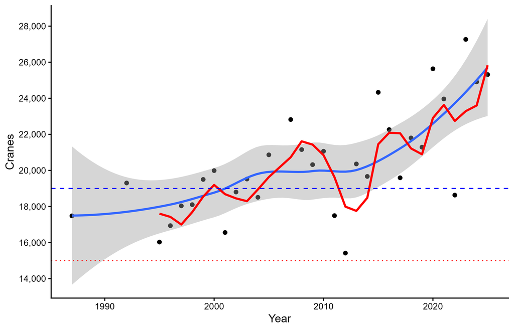

Time series statistics

| Parameter | Estimate | SE | L95%CI | U95%CI |
| --- | --- | --- | --- | --- |
| 1-year index | 25,316 |  |  |  |
| 3-year index<sup>a</sup> | 25,831 |  |  |  |
| LTA | 20,246 |  |  |  |
| Objective | 19,000 |  |  |  |
| % change from LTA | 25 |  |  |  |
| % change from obj | 36 |  |  |  |
| Mgmt index (n years) | 3 |  |  |  |

<sup>a</sup> 2023, 2024, 2025

Management thresholds:  
≥15,000 Standard  
Restrictive

Management prescription: Standard.

Regulatory alternatives:  
Standard  
State allocation of allowable harvest according to the formula in the Councils’ management plan  
Restrictive  
Hunting may be permitted to meet specific management objectives, including alleviation of localized crop damage and distribution concerns

Total allowable harvest for the 2026 hunting season: 4,250 cranes.

Note that the Management prescription and allowable harvest applies to the 2026 hunting season.

State allowable harvest allocations for the 2026 hunting season.

| State | Allowable |
| --- | --- |
| Idaho | 473 |
| Montana | 804 |
| Wyoming | 513 |
| Utah | 519 |
| Colorado | 0 |
| Arizona | 312 |
| New Mexico | 1,486 |
| Mexico | 144 |

### Data Table 21: Band-tailed Pigeon, Interior

Original data source: North American Breeding Bird Survey; U.S. Geological Survey. Data maintained by U.S. Geological Survey.

Provided in the table below are estimated abundance (Index, birds per route) and lower and upper 95% credible intervals (L95%CI, U95%CI) of Interior band-tailed pigeons in spring. Also provided is the abundance moving 3-year average (M3yr).

| Year | Index | L95%CI | U95%CI | M3yr |
| --- | --- | --- | --- | --- |
| 1967 | 0.67 | 0.29 | 2.82 | NA |
| 1968 | 0.67 | 0.29 | 2.70 | NA |
| 1969 | 0.65 | 0.29 | 2.33 | 0.66 |
| 1970 | 0.64 | 0.29 | 2.18 | 0.65 |
| 1971 | 0.64 | 0.30 | 2.19 | 0.65 |
| 1972 | 0.63 | 0.30 | 1.95 | 0.64 |
| 1973 | 0.60 | 0.30 | 1.67 | 0.62 |
| 1974 | 0.59 | 0.30 | 1.55 | 0.60 |
| 1975 | 0.56 | 0.30 | 1.39 | 0.58 |
| 1976 | 0.55 | 0.29 | 1.29 | 0.57 |
| 1977 | 0.53 | 0.29 | 1.19 | 0.55 |
| 1978 | 0.52 | 0.29 | 1.14 | 0.53 |
| 1979 | 0.50 | 0.28 | 1.07 | 0.52 |
| 1980 | 0.48 | 0.27 | 1.02 | 0.50 |
| 1981 | 0.47 | 0.26 | 0.98 | 0.49 |
| 1982 | 0.46 | 0.26 | 0.94 | 0.47 |
| 1983 | 0.45 | 0.26 | 0.91 | 0.46 |
| 1984 | 0.44 | 0.25 | 0.89 | 0.45 |
| 1985 | 0.42 | 0.24 | 0.84 | 0.44 |
| 1986 | 0.41 | 0.24 | 0.82 | 0.42 |
| 1987 | 0.41 | 0.24 | 0.82 | 0.42 |
| 1988 | 0.41 | 0.24 | 0.80 | 0.41 |
| 1989 | 0.40 | 0.24 | 0.77 | 0.41 |
| 1990 | 0.40 | 0.24 | 0.75 | 0.40 |
| 1991 | 0.39 | 0.24 | 0.72 | 0.40 |
| 1992 | 0.38 | 0.24 | 0.69 | 0.39 |
| 1993 | 0.40 | 0.25 | 0.69 | 0.39 |
| 1994 | 0.41 | 0.25 | 0.71 | 0.40 |
| 1995 | 0.40 | 0.25 | 0.71 | 0.40 |
| 1996 | 0.38 | 0.23 | 0.67 | 0.39 |
| 1997 | 0.36 | 0.22 | 0.62 | 0.38 |
| 1998 | 0.34 | 0.21 | 0.58 | 0.36 |
| 1999 | 0.32 | 0.20 | 0.55 | 0.34 |
| 2000 | 0.30 | 0.19 | 0.52 | 0.32 |
| 2001 | 0.28 | 0.17 | 0.48 | 0.30 |
| 2002 | 0.27 | 0.16 | 0.46 | 0.28 |
| 2003 | 0.26 | 0.16 | 0.45 | 0.27 |
| 2004 | 0.26 | 0.16 | 0.46 | 0.26 |
| 2005 | 0.26 | 0.16 | 0.46 | 0.26 |
| 2006 | 0.25 | 0.16 | 0.44 | 0.26 |
| 2007 | 0.24 | 0.15 | 0.42 | 0.25 |
| 2008 | 0.24 | 0.15 | 0.41 | 0.24 |
| 2009 | 0.23 | 0.14 | 0.39 | 0.24 |
| 2010 | 0.21 | 0.13 | 0.36 | 0.22 |
| 2011 | 0.20 | 0.12 | 0.34 | 0.21 |
| 2012 | 0.19 | 0.12 | 0.33 | 0.20 |
| 2013 | 0.19 | 0.11 | 0.32 | 0.19 |
| 2014 | 0.18 | 0.11 | 0.32 | 0.19 |
| 2015 | 0.18 | 0.11 | 0.32 | 0.18 |
| 2016 | 0.18 | 0.11 | 0.32 | 0.18 |
| 2017 | 0.18 | 0.11 | 0.32 | 0.18 |
| 2018 | 0.18 | 0.11 | 0.32 | 0.18 |
| 2019 | 0.18 | 0.11 | 0.32 | 0.18 |
| 2020 | 0.18 | 0.11 | 0.33 | 0.18 |
| 2021 | 0.18 | 0.11 | 0.34 | 0.18 |
| 2022 | 0.19 | 0.11 | 0.36 | 0.18 |
| 2023 | 0.19 | 0.11 | 0.36 | 0.18 |
| 2024 | 0.19 | 0.11 | 0.37 | 0.19 |
| 2025 | 0.19 | 0.11 | 0.38 | 0.19 |

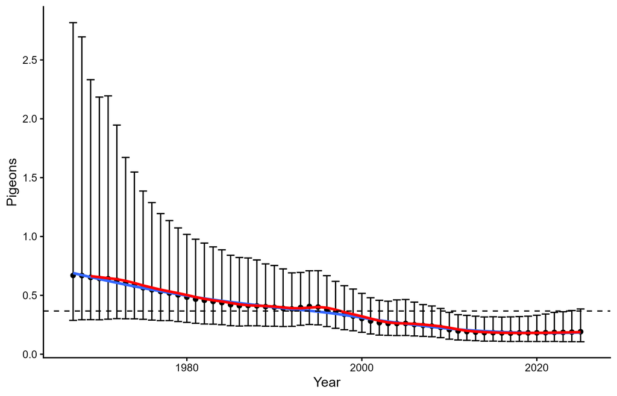

Figure 24: Interior band-tailed pigeon abundance (index) in spring. Circles are annual estimates of abundance (index) with 95% confidence intervals. The red line is a moving 3-year average and the blue line is a smoothed (Loess model) line with 95% confidence interval (shaded area) fit to the annual estimates. The black dashed reference line is the long-term average.

Time series statistics

| Parameter | Estimate | SE | L95%CI | U95%CI |
| --- | --- | --- | --- | --- |
| 1-year index | 0.19 |  | 0.11 | 0.38 |
| 3-year index<sup>a</sup> | 0.19 |  |  |  |
| LTA | 0.37 |  |  |  |
| Objective |  |  |  |  |
| % change from LTA | -47.94 |  |  |  |
| % change from obj |  |  |  |  |
| Mgmt index (n years) | 1.00 |  |  |  |

<sup>a</sup> 2023, 2024, 2025

**Harvest Strategy**  
Management index: Band-tailed pigeons per route in spring.

Management thresholds: N/A.

Management prescription: N/A.

Regulatory alternatives:  
Regulations fixed until changed.

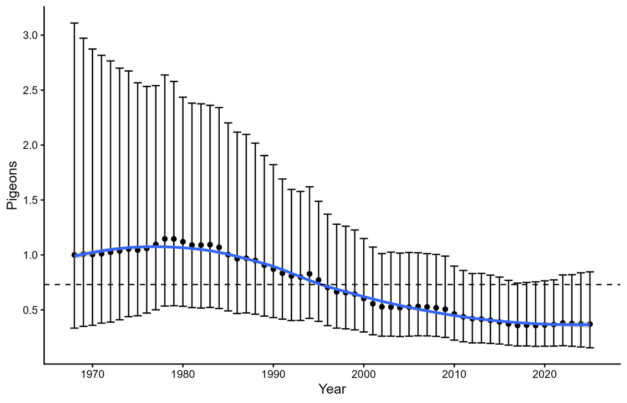

Figure 25: Band-tailed pigeon abundance (index) in Arizona in spring. Circles are annual estimates of abundance (index) with 95% confidence intervals. The blue line is a smoothed (Loess model) line with 95% confidence interval (shaded area) fit to the annual estimates. The black dashed reference line is the long-term average.

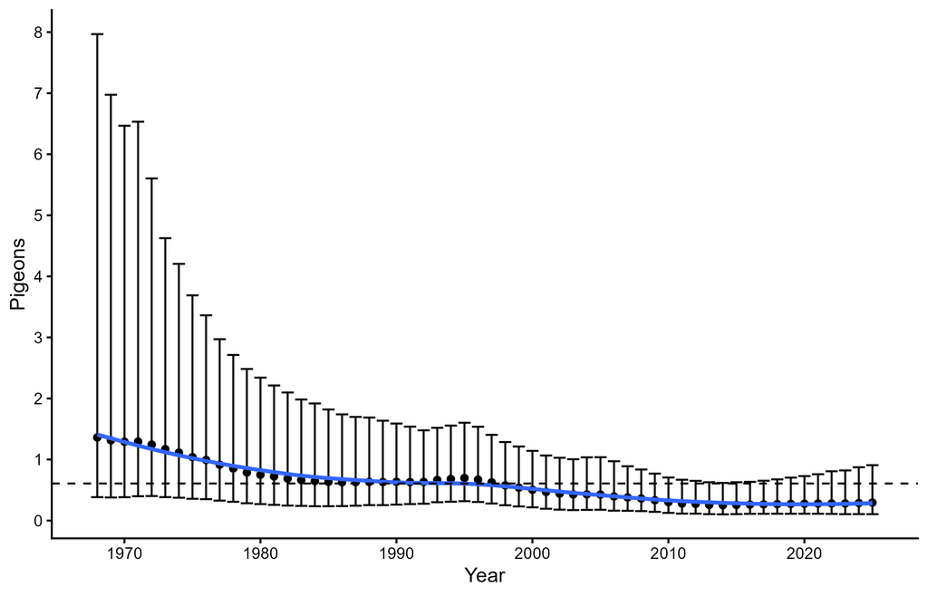

Figure 26: Band-tailed pigeon abundance (index) in New Mexico in spring. Circles are annual estimates of abundance (index) with 95% confidence intervals. The blue line is a smoothed (Loess model) line with 95% confidence interval (shaded area) fit to the annual estimates. The black dashed reference line is the long-term average.

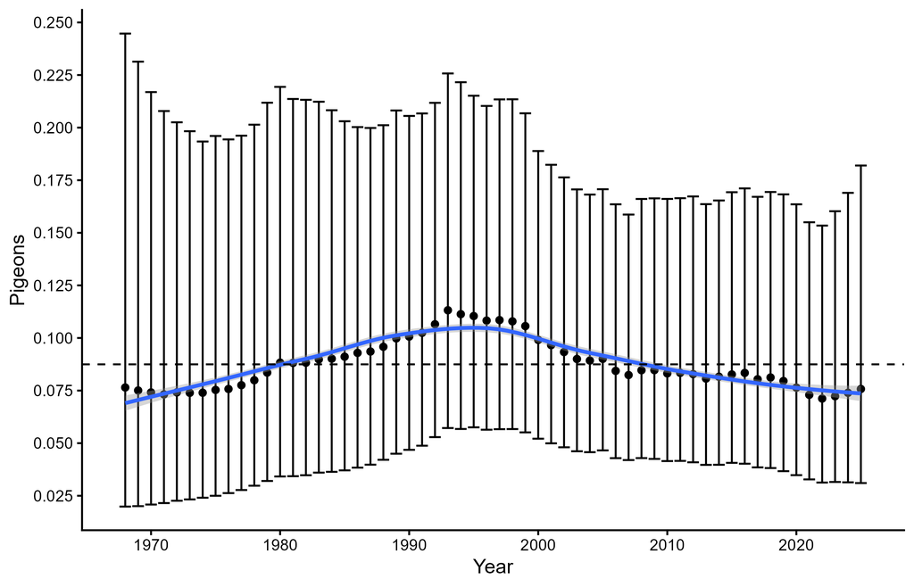

Figure 27: Band-tailed pigeon abundance (index) in Colorado in spring. Circles are annual estimates of abundance (index) with 95% confidence intervals. The blue line is a smoothed (Loess model) line with 95% confidence interval (shaded area) fit to the annual estimates. The black dashed reference line is the long-term average.

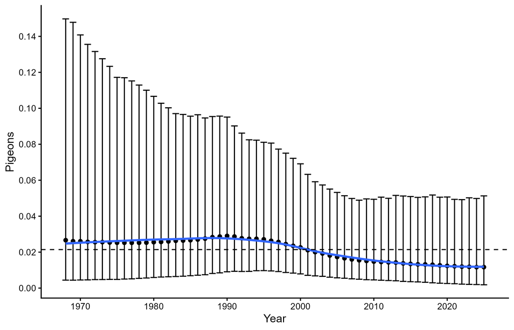

Figure 28: Band-tailed pigeon abundance (index) in Utah in spring. Circles are annual estimates of abundance (index) with 95% confidence intervals. The blue line is a smoothed (Loess model) line with 95% confidence interval (shaded area) fit to the annual estimates. The black dashed reference line is the long-term average.

### Data Table 22: Band-tailed Pigeon, Pacific Coast (summer)

Original data source: Pacific Flyway Cooperative Pacific Coast Band-tailed Pigeon Mineral Site Survey; British Columbia, Washington, Oregon, and California. Data maintained by USFWS Pacific Flyway Office.

| Year | Index | L95%CI | U95%CI | M3yr | M3yrL95%CI | M3yrU95%CI |
| --- | --- | --- | --- | --- | --- | --- |
| 2004 | 159.3 | 119.5 | 219.3 | NA | NA | NA |
| 2005 | 169.2 | 129.9 | 231.6 | NA | NA | NA |
| 2006 | 171.6 | 131.9 | 232.3 | 166.8 | 129.5 | 224.5 |
| 2007 | 166.9 | 128.5 | 226.1 | 169.4 | 132.2 | 227.1 |
| 2008 | 167.8 | 129.2 | 223.7 | 168.9 | 132.2 | 224.5 |
| 2009 | 165.0 | 127.8 | 220.5 | 166.6 | 130.8 | 220.8 |
| 2010 | 155.7 | 120.0 | 208.9 | 162.9 | 127.8 | 215.2 |
| 2011 | 169.6 | 132.0 | 225.8 | 163.5 | 128.9 | 216.2 |
| 2012 | 163.0 | 126.6 | 218.7 | 162.7 | 128.3 | 215.5 |
| 2013 | 176.4 | 137.9 | 233.5 | 169.6 | 134.3 | 223.1 |
| 2014 | 183.2 | 143.6 | 242.8 | 174.2 | 138.3 | 228.7 |
| 2015 | 183.3 | 144.9 | 239.9 | 181.0 | 144.4 | 236.4 |
| 2016 | 195.5 | 153.0 | 255.9 | 187.3 | 149.7 | 243.6 |
| 2017 | 176.9 | 138.6 | 232.3 | 185.1 | 148.1 | 239.8 |
| 2018 | 189.2 | 149.2 | 248.3 | 187.2 | 149.6 | 242.2 |
| 2019 | 201.3 | 159.1 | 266.3 | 189.2 | 151.7 | 245.5 |
| 2020 | 202.3 | 159.6 | 266.3 | 197.7 | 158.9 | 256.7 |
| 2021 | 208.9 | 165.2 | 274.1 | 204.3 | 164.3 | 265.3 |
| 2022 | 198.2 | 156.6 | 259.5 | 203.3 | 163.3 | 263.1 |
| 2023 | 192.1 | 151.1 | 252.7 | 199.7 | 160.3 | 258.7 |
| 2024 | 198.3 | 156.2 | 261.3 | 196.1 | 157.1 | 255.0 |
| 2025 | 218.1 | 172.3 | 287.6 | 202.9 | 162.8 | 264.3 |
| 2026 | 231.8 | 183.6 | 304.5 | 216.1 | 173.7 | 280.6 |

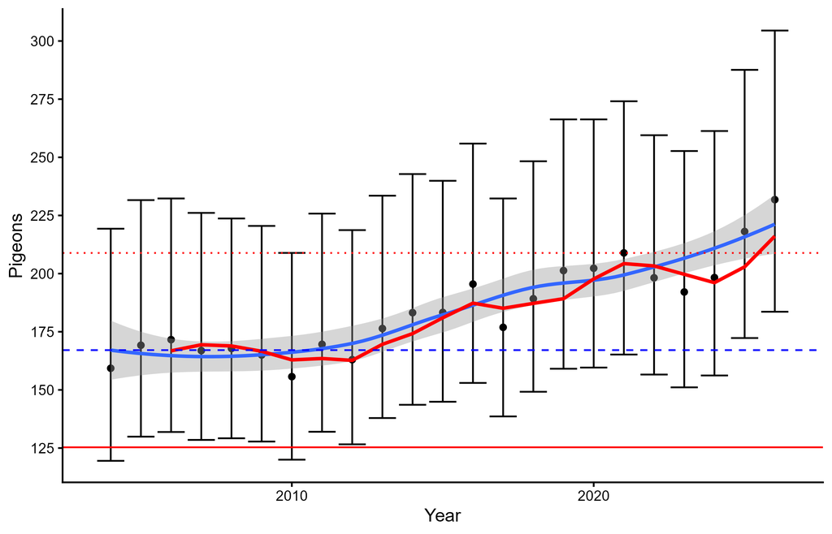

Figure 29: Pacific Coast band-tailed pigeon abundance (index) in summer. Circles are annual estimates of abundance (index) with 95% confidence intervals. The red line is a moving 3-year average and the blue line is a smoothed (Loess model) line with 95% confidence interval (shaded area) fit to the annual estimates. The red dashed reference line is the harvest strategy threshold for restrictive seasons and thered reference line is the closure threshold.

Time series statistics

| Parameter | Estimate | SE | L95%CI | U95%CI |
| --- | --- | --- | --- | --- |
| 1-year index | 231.80 |  | 183.6 | 304.5 |
| 3-year index<sup>a</sup> | 216.10 |  | 173.7 | 280.6 |
| LTA | 182.35 |  |  |  |
| Objective | 167.10 |  | 130.6 | 222.7 |
| % change from LTA | 27.12 |  |  |  |
| % change from obj | 29.32 |  |  |  |
| Mgmt index (n years) | 3.00 |  |  |  |

<sup>a</sup> 2024, 2025, 2026

**Harvest Strategy**  
Management index: Band-tailed pigeons per mineral site in summer.

Management thresholds:  
≥208.9 Standard  
≥125.3 Restrictive  
Closed

Note that once the season is closed, the Restrictive alternative will be prescribed when ≤80% of the PPD for the recent 3-year mean abundance is ≤142 (15% below the population objective).

Regulatory alternatives:  
Standard  
4-bird daily bag limit, 9-day season  
Restrictive  
2-bird daily bag limit, 9-day season  
Closed